# Polysubstance and tr. completion

Analyze the association between polysubstance at admission and tr. compleiton longitudinally along treatments, accounting for irregular observations.

Author

Andrés González Santa Cruz

Published

October 1, 2025

# Data Loading and Exploration

## Loading Packages and uniting databases

Proceed to load the necessary packages.

```r
# invisible("Only run from Ubuntu")
# if (!(Sys.getenv("RSTUDIO_SESSION_TYPE") == "server" || file.exists("/.dockerenv"))) {
#   if(Sys.info()["sysname"]!="Windows"){
#     Sys.setenv(RETICULATE_PYTHON = "/home/fondecytacc/.pyenv/versions/3.11.5/bin/python")
#   }
# }

#clean enviroment
rm(list = ls()); gc()

time_before_dedup2<-Sys.time()

#:#:#:#:#:#:#:#:#:#:#:#:#:#:#:#:#:#:#:#:#:#:#:#:#:#:#:#:#:#:#:#:#:#:#:#:#:#:#:#:
#:#:#:#:#:#:#:#:#:#:#:#:#:#:#:#:#:#:#:#:#:#:#:#:#:#:#:#:#:#:#:#:#:#:#:#:
# --- Bootstrap reticulate con ruta relativa a getwd() ---
suppressPackageStartupMessages(library(reticulate))

# Busca .mamba_root/envs/py311/python.exe desde getwd() hacia padres
find_python_rel <- function(start = getwd(),
                            rel = file.path(".mamba_root","envs","py311","python.exe")) {
  cur <- normalizePath(start, winslash = "/", mustWork = FALSE)
  repeat {
    cand <- normalizePath(file.path(cur, rel), winslash = "/", mustWork = FALSE)
    if (file.exists(cand)) return(cand)
    parent <- dirname(cur)
    if (identical(parent, cur)) return(NA_character_)  # llegó a la raíz
    cur <- parent
  }
}

py <- find_python_rel()

if (is.na(py)) {
  stop("No se encontró Python relativo a getwd() (buscando '.mamba_root/envs/py311/python.exe').\n",
       "Directorio actual: ", getwd())
}

# Forzar ese intérprete
Sys.unsetenv(c("RETICULATE_CONDAENV","RETICULATE_PYTHON_FALLBACK"))
Sys.setenv(RETICULATE_PYTHON = py)
reticulate::use_python(py, required=T)

py_config()  # verificación

#_#_#_#_#_#_#_#_#_#_#_#_#_#_#_#_#_#_#_#_#_#_#_#_#_#_#_#_#_#_#_#_#_#_#_#_
#_#_#_#_#_#_#_#_#_#_#_#_#_#_#_#_#_#_#_#_#_#_#_#_#_#_#_#_#_#_#_#_#_#_#_#_

if(grepl("SISTRAT 2023",getwd())){
wdpath<-
paste0(gsub("/cons","",gsub("cons","",paste0(getwd(),"/cons"))))
} else {
wdpath<-
paste0(paste0(gsub("/SISTRAT 2022 \\(github\\)/_proposal_grant/2023","",getwd())),"/SISTRAT 2023/")
}
#readRDS("G:/My Drive/Alvacast/SISTRAT 2023/data/20241015_out/psu/SISTRAT23_c1_2010_2024_df_prev1w.rds")

try(load(paste0(wdpath,"data/20241015_out/psu/","SISTRAT_database_sep25_prevt.RData")))

SISTRAT23_c1_2010_2024_df_prev1w<-
try(readRDS(paste0(wdpath,"data/20241015_out/psu/","SISTRAT23_c1_2010_2024_df_prev1w.rds")))

df23_ndp_20250824_SISTRAT23_c1_1024<-
 readRDS(paste0(wdpath,"data/20241015_out/psu/","23_ndp_20250824_SISTRAT23_c1_1024_df2.rds"))
```

```
          used (Mb) gc trigger (Mb) max used (Mb)
Ncells  603442 32.3    1280527 68.4  1060110 56.7
Vcells 1190106  9.1    8388608 64.0  1945366 14.9
python:         G:/My Drive/Alvacast/SISTRAT 2023/.mamba_root/envs/py311/python.exe
libpython:      G:/My Drive/Alvacast/SISTRAT 2023/.mamba_root/envs/py311/python311.dll
pythonhome:     G:/My Drive/Alvacast/SISTRAT 2023/.mamba_root/envs/py311
version:        3.11.5 | packaged by conda-forge | (main, Aug 27 2023, 03:23:48) [MSC v.1936 64 bit (AMD64)]
Architecture:   64bit
numpy:           [NOT FOUND]

NOTE: Python version was forced by RETICULATE_PYTHON
```

```r
#https://github.com/rstudio/renv/issues/544
#renv falls back to copying rather than symlinking, which is evidently very slow in this configuration.
renv::settings$use.cache(FALSE)

#only use explicit dependencies (in DESCRIPTION)
renv::settings$snapshot.type("implicit")

#check if rstools is installed
try(installr::install.Rtools(check_r_update=F))
```

Installing package into ‘C:/Users/andre/AppData/Local/R/win-library/4.4’ (as ‘lib’ is unspecified)

```r
check_quarto_version <- function(required = "1.7.29", comparator = c("ge","gt","le","lt","eq")) {
  comparator <- match.arg(comparator)
  current <- package_version(paste(unlist(quarto::quarto_version()), collapse = "."))
  req     <- package_version(required)

  ok <- switch(comparator,
               ge = current >= req,
               gt = current >  req,
               le = current <= req,
               lt = current <  req,
               eq = current == req)

  if (!ok) {
    stop(sprintf("Quarto version check failed: need %s %s (installed: %s).",
                 comparator, required, current), call. = FALSE)
  }
  invisible(TRUE)
}

check_quarto_version("1.7.29", "ge")

#change repository to CL
local({
  r <- getOption("repos")
  r["CRAN"] <- "https://cran.dcc.uchile.cl/"
  options(repos=r)
})

if(!require(pacman)){install.packages("pacman");require(pacman)}
```

Cargando paquete requerido: pacman

Warning: package ‘pacman’ was built under R version 4.4.3

```r
if(!require(pak)){install.packages("pak");require(pak)}
```

Cargando paquete requerido: pak

```r
pacman::p_unlock(lib.loc = .libPaths()) #para no tener problemas reinstalando paquetes
```

No 00LOCK detected in: C:/Users/andre/AppData/Local/R/win-library/4.4 No 00LOCK detected in: C:/Program Files/R/R-4.4.1/library

```r
if(Sys.info()["sysname"]=="Windows"){
if (getRversion() != "4.4.1") { stop("Requires R version 4.4.1; Actual: ", getRversion()) }
}

#check docker
check_docker_running <- function() {
  # Try running 'docker info' to check if Docker is running
  system("docker info", intern = TRUE, ignore.stderr = TRUE)
}

install_docker <- function() {
  # Open the Docker Desktop download page in the browser for installation
  browseURL("https://www.docker.com/products/docker-desktop")
}

# Main logic
if (inherits(try(check_docker_running(), silent = TRUE), "try-error")) {
  liftr::install_docker()
} else {
  message("Docker is running.")
}
```

Warning in system(“docker info”, intern = TRUE, ignore.stderr = TRUE): el comando ejecutado ‘docker info’ tiene el estatus 1

Docker is running.

```r
#_#_#_#_#_#_#_#_#_#_#_#_#_#_#_#_#_#_#_#_#_#_#_#_#_#_#_#_#_#_#_#_#_#_#_#_#_#_#_#_
#PACKAGES#######################################################################
#_#_#_#_#_#_#_#_#_#_#_#_#_#_#_#_#_#_#_#_#_#_#_#_#_#_#_#_#_#_#_#_#_#_#_#_#_#_#_#_

unlink("*_cache", recursive=T)

# ----------------------------------------------------------------------
# 2. Use a single pak::pkg_install() call for most CRAN packages
# ----------------------------------------------------------------------

paks <-
  c(#"git",
    # To connect to github
    "gh", #interface for  GitHub API from R
    #
    "gitcreds", # manages Git credentials (usernames, passwords, tokens)
    #
    "usethis", # simplifies common project setup tasks for R developers
    # Package to bring packages in development
    "devtools",
    # Package administration
    "renv",
    # To manipulate data
    "knitr", "pander", "DT",
    # Join
    "fuzzyjoin", "RecordLinkage",
    # For tables
    "tidyverse", "janitor",
    # For contingency tables
    "kableExtra",
    # For connections with python
    "reticulate",
    # To manipulate big data
    "polars", "sqldf",
    # To bring big databases
    "nanoparquet",
    # Interface for R and RStudio in R
    "installr", "rmarkdown", "quarto", "yaml", #"rstudioapi",
    # Time handling
    "clock",
    # Combine plots
    "ggpubr",
    # Parallelized iterative processing
    "furrr",
    # Work like a tibble with a data.table database
    "tidytable",
    # Split database into training and testing
    "caret",
    # Impute missing data
    "missRanger", "mice",
    # To modularize tasks
    "job",
    # For PhantomJS install checks
    "webshot"
  )

# dplyr
# janitor
# reshape2
# tidytable
# arrow
# boot
# broom
# car
# caret
# data.table
# DiagrammeR
# DiagrammeRsvg
# dplyr
# epiR
# epitools
# ggplot2
# glue
# htmlwidgets
# knitr
# lubridate
# naniar
# parallel
# polycor
# pROC
# psych
# readr
# rio
# rsvg
# scales
# stringr
# tableone
# rmarkdown
# biostat3
# codebook
# finalfit
# Hmisc
# kableExtra
# knitr
# devtools
# tidyr
# stringi
# stringr
# muhaz
# sqldf
# compareGroups
# survminer
# lubridate
# ggfortify
# car
# fuzzyjoin
# compareGroups
# caret
# job
# htmltools
# nanoparquet
# ggpubr
# polars
# installr
# clock
# pander
# reshape
# mice
# missRanger
# VIM
# withr
# biostat3
# broom
# glue
# finalfit
# purrr
# sf


# pak::pkg_install(paks)

pak::pak_sitrep()
# pak::sysreqs_check_installed(unique(unlist(paks)))
#pak::lockfile_create(unique(unlist(paks)),  "dependencies_duplicates24.lock", dependencies=T)
#pak::lockfile_install("dependencies_duplicates24.lock")
#https://rdrr.io/cran/pak/man/faq.html
#pak::cache_delete()

library(tidytable)
```

Adjuntando el paquete: ‘tidytable’

The following objects are masked from ‘package:stats’:

```
dt, filter, lag
```

The following object is masked from ‘package:base’:

```
%in%
```

```r
library(ggplot2)
```

Warning: package ‘ggplot2’ was built under R version 4.4.3

```r
library(readr)
```

Warning: package ‘readr’ was built under R version 4.4.3

```r
library(survival)

cat("Install IrregLong\n")
if (!requireNamespace("IrregLong", quietly = TRUE)) {
  install.packages("IrregLong")
}
cat("Install geepack\n")
if (!requireNamespace("geepack", quietly = TRUE)) {
  install.packages("geepack")
}
# ----------------------------------------------------------------------
# 3. Activate polars code completion (safe to try even if it fails)
# ----------------------------------------------------------------------
#try(polars_code_completion_activate())

# ----------------------------------------------------------------------
# 4. BPMN from GitHub (not on CRAN, so install via devtools if missing)
# ----------------------------------------------------------------------
if (!requireNamespace("bpmn", quietly = TRUE)) {
  devtools::install_github("bergant/bpmn")
}


# ----------------------------------------------------------------------
# 5. PhantomJS Check (use webshot if PhantomJS is missing)
# ----------------------------------------------------------------------
# if (!webshot::is_phantomjs_installed()) {
#   webshot::install_phantomjs()
# }


# Memory management function
manage_memory <- function() {
    gc()
    if (.Platform$OS.type == "windows") {
        tryCatch({
            memory.limit(size = memory.limit() + 1000)
        }, error = function(e) NULL)
    }
}

manage_memory()
```

Warning: ‘memory.limit()’ is no longer supported

```r
check_memory <- function() {
    if (.Platform$OS.type == "windows") {
        mem <- memory.size()
        limit <- memory.limit()
        log_message(paste("Memory usage:", round(mem, 1), "MB /", limit, "MB"))
        return(mem/limit > 0.8)
    }
    return(FALSE)
}

#_#_#_#_#_#_#_#_#_#_#_#_#_#_#_#_#_#_#_#_#_#_#_#_#_#_#_#_#_#_#_#_#_#_#_#_#_#_#_#_
#FUNCTIONS######################################################################
#_#_#_#_#_#_#_#_#_#_#_#_#_#_#_#_#_#_#_#_#_#_#_#_#_#_#_#_#_#_#_#_#_#_#_#_#_#_#_#_

#:#:#:#:#:#:#:#:#:#:#:#:#:#:#:#:#:#:#:#:#:#:#:#:#:#:#:#:#:#:#:#:#:#:#:#:#:#:#:#:#:#:#:#:#:#:#:#:#:#:#:#
# NO MORE DEBUGS
options(error = NULL)        # si antes tenías options(error = recover) o browser)
options(browserNLdisabled = FALSE)


#:#:#:#:#:#:#:#:#:#:#:#:#:#:#:#:#:#:#:#:#:#:#:#:#:#:#:#:#:#:#:#:#:#:#:#:#:#:#:#:#:#:#:#:#:#:#:#:#:#:#:#
#NAs are replaced with "" in knitr kable
options(knitr.kable.NA = '')

pander::panderOptions('big.mark', ',')
pander::panderOptions('decimal.mark', '.')

#:#:#:#:#:#:#:#:#:#:#:#:#:#:#:#:#:#:#:#:#:#:#:#:#:#:#:#:#:#:#:#:#:#:#:#:#:#:#:#:#:#:#:#:#:#:#:#:#:#:#:#

#to format rows in bold
format_cells <- function(df, rows ,cols, value = c("italics", "bold", "strikethrough")){

  # select the correct markup
  # one * for italics, two ** for bold
  map <- setNames(c("*", "**", "~~"), c("italics", "bold", "strikethrough"))
  markup <- map[value]

  for (r in rows){
    for(c in cols){

      # Make sure values are not factors
      df[[c]] <- as.character( df[[c]])

      # Update formatting
      df[r, c] <- ifelse(nchar(df[r, c])==0,"",paste0(markup, gsub(" ", "", df[r, c]), markup))
    }
  }

  return(df)
}
#To produce line breaks in messages and warnings
knitr::knit_hooks$set(
   error = function(x, options) {
     paste('\n\n<div class="alert alert-danger" style="font-size: small !important;">',
           gsub('##', '\n', gsub('^##\ Error', '**Error**', x)),
           '</div>', sep = '\n')
   },
   warning = function(x, options) {
     paste('\n\n<div class="alert alert-warning" style="font-size: small !important;">',
           gsub('##', '\n', gsub('^##\ Warning:', '**Warning**', x)),
           '</div>', sep = '\n')
   },
   message = function(x, options) {
     paste('<div class="message" style="font-size: small !important;">',
           gsub('##', '\n', x),
           '</div>', sep = '\n')
   }
)

#:#:#:#:#:#:#:#:#:#:#:#:#:#:#:#:#:#:#:#:#:#:#:#:#:#:#:#:#:#:#:#:#:#:#:#:#:#:#:#:#:#:#:#:#:#:#:#:#:#:#:#

sum_dates <- function(x){
  cbind.data.frame(
    min= as.Date(min(unclass(as.Date(x)), na.rm=T), origin = "1970-01-01"),
    p001= as.Date(quantile(unclass(as.Date(x)), .001, na.rm=T), origin = "1970-01-01"),
    p005= as.Date(quantile(unclass(as.Date(x)), .005, na.rm=T), origin = "1970-01-01"),
    p025= as.Date(quantile(unclass(as.Date(x)), .025, na.rm=T), origin = "1970-01-01"),
    p25= as.Date(quantile(unclass(as.Date(x)), .25, na.rm=T), origin = "1970-01-01"),
    p50= as.Date(quantile(unclass(as.Date(x)), .5, na.rm=T), origin = "1970-01-01"),
    p75= as.Date(quantile(unclass(as.Date(x)), .75, na.rm=T), origin = "1970-01-01"),
    p975= as.Date(quantile(unclass(as.Date(x)), .975, na.rm=T), origin = "1970-01-01"),
    p995= as.Date(quantile(unclass(as.Date(x)), .995, na.rm=T), origin = "1970-01-01"),
    p999= as.Date(quantile(unclass(as.Date(x)), .999, na.rm=T), origin = "1970-01-01"),
    max= as.Date(max(unclass(as.Date(x)), na.rm=T), origin = "1970-01-01")
  )
}

#:#:#:#:#:#:#:#:#:#:#:#:#:#:#:#:#:#:#:#:#:#:#:#:#:#:#:#:#:#:#:#:#:#:#:#:#:#:#:#:#:#:#:#:#:#:#:#:#:#:#:#:#:#:#:

# Define the function adapted for Polars
sum_dates_polars <- function(df, date_col) {
  # Create the list of quantiles
  quantiles <- c(0.001, 0.005, 0.025, 0.25, 0.5, 0.75, 0.975, 0.995, 0.999)
  # Create expressions to calculate min and max
  expr_list <- list(
    pl$col(date_col)$min()$alias("min"),
    pl$col(date_col)$max()$alias("max")
  )
  # Add expressions for quantiles
  for (q in quantiles) {
    expr_list <- append(expr_list, pl$col(date_col)$quantile(q)$alias(paste0("p", sub("\\.", "", as.character(q)))))
  }
  # Apply the expressions and return a DataFrame with the results
  df$select(expr_list)
}

# Custom function for sampling with a seed
sample_n_with_seed <- function(data, size, seed) {
  set.seed(seed)
  dplyr::sample_n(data, size)
}

# Function to get the most frequent value
most_frequent <- function(x) {
  uniq_vals <- unique(x)
  freq_vals <- sapply(uniq_vals, function(val) sum(x == val))
  most_freq <- uniq_vals[which(freq_vals == max(freq_vals))]

  if (length(most_freq) == 1) {
    return(most_freq)
  } else {
    return(NA)
  }
}
#_#_#_#_#_#_#_#_#_#_#_#_#_#_#_#_#_#_#_#_#_#_#_#_#_#_#_#_#_#_#_#_#_#_#_#_#_#_#_#_
#CONFIG #######################################################################
#_#_#_#_#_#_#_#_#_#_#_#_#_#_#_#_#_#_#_#_#_#_#_#_#_#_#_#_#_#_#_#_#_#_#_#_#_#_#_#_

options(scipen=2) #display numbers rather scientific number

#_#_#_#_#_#_#_#_#_#_#_#_#_#_#_#_#_#_#_#_#_#_#_#_#_#_#_#_#_#_#_#_#_#_#_#_#_#_#_#_

# Define the function first
#joins these values with semicolons and optionally truncates the result if it exceeds a specified width.
toString2 <- function(x, width = NULL, ...) {
    string <- paste(x, collapse = "; ")
    if (missing(width) || is.null(width) || width == 0)
        return(string)
    if (width < 0)
        stop("'width' must be positive")
    if (nchar(string, type = "w") > width) {
        width <- max(6, width)
        string <- paste0(substr(string, 1, width - 3), "...")
    }
    string
}
normalize_txt <- function(x) {
  x|>
    stringi::stri_trans_general("Latin-ASCII")|>
    tolower()|>
    trimws()
}

icd10_broad <- function(x) {
x <- tolower(x)
tidytable::case_when(
stringr::str_detect(x, "organic|organico|demenc|alzheimer|parkinson|delirium|cerebral") ~ "F0 Organic",
stringr::str_detect(x, "psicoactiva|alcohol|marihuana|canabis|cannabis|cocain|opio|opiace|benzodiazep|sustancias") ~ "F1 Substance use",
stringr::str_detect(x, "esquizofren|psicotip|delirant|psicosis") ~ "F2 Psychotic",
stringr::str_detect(x, "estado de animo|afectiv|depres|bipolar|maniaco|distimia|hipoman") ~ "F3 Mood",
stringr::str_detect(x, "neurotic|ansiedad|fobi|panico|obsesivo|compulsiv|estres|adaptaci|somatoform|somatiz") ~ "F4 Anxiety/Stress/Somatoform",
stringr::str_detect(x, "comportamiento.*fisiolog|alimentari|anorex|bulim|sueñ|insomni|disfuncion sexual") ~ "F5 Physio/Eating/Sleep/Sexual",
stringr::str_detect(x, stringr::regex("personalidad|comportamiento del adulto|antisocial|limite|evitativ|habit|habitos|impuls|control de los impulsos|control\\s+de\\s+impulsos", ignore_case = TRUE)) ~ "F6 Personality/Adult behaviour",
stringr::str_detect(x, "retraso mental|discapacidad intelectual|intelectual") ~ "F7 Intellectual disability",
stringr::str_detect(x, "desarrollo psicolog|autism|asperger|lenguaje|aprendizaje|espectro autista|tdah|t\\s*d\\s*a\\s*h") ~ "F8/9 Neurodevelopment/Child",
TRUE ~ "Other/unspecified"
)
}
dsmiv_broad <- function(x) {
x <- tolower(x)
tidytable::case_when(
stringr::str_detect(x, "sustancia|alcohol|marihuana|cannabis|cocain|opio|opiace|benzodiazep") ~ "Substance-related",
stringr::str_detect(x, "esquizofren|psicosis|psicot") ~ "Psychotic",
stringr::str_detect(x, "estado de animo|afectiv|depres|bipolar|maniaco|distimia|hipoman") ~ "Mood",
stringr::str_detect(x, "ansiedad|fobi|panico|obsesivo|compulsiv|estres|adaptaci") ~ "Anxiety/Stress/Adjustment",
stringr::str_detect(x, "somatoform|somatiz|disociativ|conversion") ~ "Somatoform/Dissociative",
stringr::str_detect(x, "alimentari|anorex|bulim|sueñ|insomni|disfuncion sexual|para[f|f]ilia|sexual") ~ "Eating/Sleep/Sexual",
stringr::str_detect(x, "personalidad|antisocial|limite|borderline|paranoide|evitativ|dependient|narcis") ~ "Personality",
stringr::str_detect(x, "retraso mental|discapacidad intelectual|intelectual") ~ "Intellectual disability",
stringr::str_detect(x, "desarrollo|autism|asperger|infancia|tdah|t\\s*d\\s*a\\s*h|lenguaje|aprendizaje") ~ "Neurodevelopment/Childhood-onset",
TRUE ~ "Other/unspecified"
)
}

pair_str <- function(main, sub) {
  main <- as.character(main)
  sub  <- as.character(sub)
  both_na <- is.na(main) & is.na(sub)

  out <- paste0(
    tidytable::coalesce(main, "NA"),
    "::",
    tidytable::coalesce(sub,  "NA")
  )

  out[both_na] <- NA_character_
  out
}

#:#:#:#:#:#:#:#:#:#:#:#:#:#:#:#:#:#:#:#:#:#:#:#:#:#:#:#:#:#:#:#:#:#:#:#:#:#:#:#:
#:#:#:#:#:#:#:#:#:#:#:#:#:#:#:#:#:#:#:#:#:#:#:#:#:#:#:#:#:#:#:#:#:#:#:#:#:#:#:#:
# IIW weight functions

ess <- function(w) {
    w <- w[!is.na(w)]
    cv2 <- var(w) / (mean(w)^2)
    length(w) / (1 + cv2)
}
summ_w <- function(w, name, lo = 0.01, hi = 0.99) {
    tibble::tibble(
        #weight_set = name,
        n_non_na   = sum(!is.na(w)),
        n_na       = sum(is.na(w)),
        min        = min(w, na.rm=TRUE),
        q01        = stats::quantile(w, probs=0.01, na.rm=TRUE),
        q25        = stats::quantile(w, probs=0.25, na.rm=TRUE),
        median     = stats::median(w, na.rm=TRUE),
        mean       = mean(w, na.rm=TRUE),
        q75        = stats::quantile(w, probs=0.75, na.rm=TRUE),
        q99        = stats::quantile(w, probs=0.99, na.rm=TRUE),
        max        = max(w, na.rm=TRUE),
        prop_lt_0.2= mean(w < 0.2, na.rm=TRUE),
        prop_gt_5  = mean(w > 5,   na.rm=TRUE),
        ESS        = ess(w)
    )
}
# truncated versions (1st–99th) for sensitivity
cap <- function(w, p = c(0.01, 0.99)) {
  b <- stats::quantile(w, probs=p, na.rm=TRUE)
  pmin(pmax(w, b[1]), b[2])
}
renorm <- function(w) w / mean(w, na.rm = TRUE)


#_#_#_#_#_#_#_#_#_#_#_#_#_
#_#_#_#_#_#_#_#_#_#_#_#_#_

counting_process_output<-
  function(object=NULL){
    broom::tidy(object$m, exponentiate=T, conf.int=T) %>%
      dplyr::mutate(across(c("estimate","std.error", "statistic","conf.low","conf.high"),~sprintf("%1.2f",.))) %>%
      dplyr::mutate(p.value= sprintf("%1.4f",p.value))
  }

#:#:#:#:#:#:#:#:#:#:#:#:#:#:#:#:#:#:#:#:#:#:#:#:#:#:#:#:
#:#:#:#:#:#:#:#:#:#:#:#:#:#:#:#:#:#:#:#:#:#:#:#:#:#:#:

tidy_coxph <- function(model, conf.level = 0.95) {
  # Extract the coefficients (a named numeric vector)
  coefs <- model$coefficients

  # Compute robust standard errors from the robust variance matrix
  robust_se <- sqrt(diag(model$var))

  # Compute z statistics and two-sided p-values
  z <- coefs / robust_se
  p_value <- 2 * (1 - pnorm(abs(z)))

  # Compute the critical z value for the specified confidence level
  z_crit <- qnorm(1 - (1 - conf.level) / 2)

  # Exponentiate coefficients to get hazard ratios
  hazard_ratio <- exp(coefs)

  # Compute the lower and upper confidence intervals (exponentiated)
  lower_ci <- exp(coefs - z_crit * robust_se)
  upper_ci <- exp(coefs + z_crit * robust_se)

  # Build and return a tidy data frame
  result <- data.frame(
    term         = names(coefs),
    coef         = coefs,
    robust_se    = robust_se,
    hazard_ratio = hazard_ratio,
    lower_ci     = lower_ci,
    upper_ci     = upper_ci,
    z            = z,
    p_value      = p_value,
    stringsAsFactors = FALSE
  )

  return(result)
}

format_hr_ci <- function(tidy_table, digits = 2) {
  # Build a format string dynamically using the desired number of digits.
  fmt <- paste0("%.", digits, "f (%.", digits, "f, %.", digits, "f)")

  # Create the new column using sprintf to format each row.
  tidy_table$hr_ci <- with(tidy_table, sprintf(fmt, hazard_ratio, lower_ci, upper_ci))

  return(tidy_table)
}

#:#:#:#:#:#:#:#:#:#:#:#:#:#:#:#:#:#:#:#:#:#:#:#:#:#:#:#:#:#:#:#:
#:#:#:#:#:#:#:#:#:#:#:#:#:#:#:#:#:#:#:#:#:#:#:
```

[output not shown]

## Database consolidation

We used `SISTRAT23_c1_2010_2024_df_prev1w`, because we wanted to capture more treatments from each people.

```r
invisible("Label variables")
# main=========
# =========================
# Core variables
# =========================
# Biopsychosocial compromise = biopsych_comp / severe = biopsych_comp_severe #created
# Age at Admission to Treatment (First Entry) = adm_age_rec3
# Birth year = birth_date_rec / year_decimal  #created
# Primary substance of the initial diagnosis = sus_ini_mod_mvv
# Psychiatric comorbidity (ICD-10) = dg_psiq_cie_10_dg
# Psychiatric comorbidity (ICD-10) [In study] = dg_psiq_cie_10_instudy
# Broad diagnostic categories (e.g., Anxiety, Personality) = cie10_broad_cat
# Frequency of primary substance use at admission = prim_sub_freq
# Daily = created= prim_sub_daily
# Occupational status (corrected) = occupation_condition_corr24   # created
# Primary substance at admission to treatment = primary_sub
# Polysubstance = polysubstance_strict   # created

# =========================
# Survival variables
# =========================
# Discharge date (numeric, rec6) = disch_date_num_rec6
# Discharge date (numeric, rec6, imputed/translated) = disch_date_num_rec6_trans
# Admission date of next treatment = adm_date_next_treat
# Admission date (numeric, rec2) = adm_date_num_rec2
# Treatment compliance (rec7) = tr_compliance_rec7   # created

# =========================
# Effect modifier
# =========================
# Plan type= plan_type_mod # created

# =========================
# Process variables
# =========================
# Treatment outcome of the previous treatment= tr_completion # created
# Previous biopsychosocial compromise (severe)
# Previous treatment duration (<90 days)
# Previous treatment duration (log days)
# Polysubstance use status of the previous treatment
# Age at admission to treatment (previous)
# Birth year (previous)
# Primary substance (initial diagnosis): alcohol = primary_sub
# Primary substance (initial diagnosis): cocaine
# Primary substance (initial diagnosis): cocaine base paste
# Primary substance (initial diagnosis): marijuana
# Psychiatric comorbidity (diagnosis unknown / under study)
# Psychiatric comorbidity (confirmed comorbidity)
# Daily frequency of primary substance at admission
# Occupational status (inactive) = occupation_condition_corr   # created
# Occupational status (unemployed) = occupation_condition_corr   # created
# Primary substance at admission to treatment (alcohol)
# Primary substance at admission to treatment (cocaine hydrochloride)
# Primary substance at admission to treatment (cocaine base paste)
# Primary substance at admission to treatment (marijuana)

#:#:#:#:#:#:#:#:#:#:#:#:#:#:#:#:#:#:#:#:#:#:#:#:#:#:#:#:#:#:#:#:#:#:#:#:#:#:#:#:
#:#:#:#:#:#:#:#:#:#:#:#:#:#:#:#:#:#:#:#:#:#:#:#:#:#:#:#:#:#:#:#:#:#:#:#:#:#:#:#:
# adapt database=========
sec_cols <- c("second_sub1", "second_sub2", "second_sub3")

out <- SISTRAT23_c1_2010_2024_df_prev1w %>%
  left_join(SISTRAT23_c1_2010_2024_df_prev1t[,c("rn", "birth_date_rec", "dg_psiq_cie_10_instudy", "dg_psiq_cie_10_dg")], by="rn", multiple="first")%>%
  arrange(hash_key, adm_age_rec3)%>%
  mutate(
    # Clean all substance columns
    across(all_of(c("primary_sub", sec_cols)), ~ .x %>% stringr::str_squish() %>% stringr::str_to_lower()),

    # Count real secondary substances (non-NA, non-empty, not "sin sustancia...")
    n_real_secondary = rowSums(
      across(all_of(sec_cols), ~
        !is.na(.x) &
        .x != "" &
        !stringr::str_detect(.x, "sin\\s*sustancia\\s*principal")
      ),
      na.rm = TRUE
    ),
    # Define polysubstance logic:
    # Case 1: primary_sub is NA → polysubstance if ≥2 real secondaries
    # Case 2: primary_sub NOT NA → polysubstance if any secondary ≠ primary_sub
    has_real_secondary = case_when(
      is.na(primary_sub) ~ n_real_secondary >= 2,
      TRUE ~ if_any(
        all_of(sec_cols),
        ~ !is.na(.x) &
          .x != "" &
          !stringr::str_detect(.x, "sin\\s*sustancia\\s*principal") &
          .x != primary_sub
      )
    ),
    polysubstance_strict = as.integer(has_real_secondary)
  )%>%
  mutate(
    plan_code_std = plan_type_corr %>%
      stringr::str_trim() %>% stringr::str_to_lower() %>% stringr::str_replace_all("[ _]", "-"),

    plan_sponsor = case_when(
      stringr::str_detect(plan_code_std, "^m-")  ~ "WO",
      stringr::str_detect(plan_code_std, "^pg-") ~ "GP",
      TRUE ~ NA_character_
    ),
    plan_level = case_when(
      stringr::str_detect(plan_code_std, "pr$")  ~ "residential",
      stringr::str_detect(plan_code_std, "pai$") ~ "intensive ambulatory",
      stringr::str_detect(plan_code_std, "pab$") ~ "basic ambulatory",
      TRUE ~ NA_character_
    ),

    # Optional combined label if you still want one
    plan_type_mod = case_when(
      !is.na(plan_sponsor) & !is.na(plan_level) ~ paste(plan_sponsor, plan_level),
      !is.na(plan_level)                        ~ plan_level,
      TRUE                                      ~ NA_character_
    ),
    plan_type_mod = case_when(plan_type_mod=="WO basic ambulatory"~ "WO intensive ambulatory",
      TRUE                                      ~ plan_type_mod
    )
  )%>%
  group_by(hash_key)%>%
    mutate(plan_type_mod = first(plan_type_mod))%>%
  ungroup()%>%
  mutate(
    prim_sub_daily = case_when(
      is.na(prim_sub_freq) ~ NA_integer_,
      prim_sub_freq == "5. Daily"   ~ 1L,
      TRUE                          ~ 0L
    )
  )%>%
  mutate(
    tr_completion = case_when(
      tr_compliance_rec7 == "completion"        ~ 1L,
      stringr::str_detect(tr_compliance_rec7, "current") ~ NA_integer_,
      TRUE                           ~ 0L
    ),
    # Non-completion (1) vs completion (0); keep NA for "currently in"
    tr_noncompletion = case_when(
      is.na(tr_completion) ~ NA_integer_,
      tr_completion == 1L  ~ 0L,
      TRUE                 ~ 1L
    )
  )%>%
  mutate(
          primary_sub_std = stringr::str_to_lower(stringr::str_squish(primary_sub)),
          primary_sub_mod = case_when(
              stringr::str_detect(primary_sub_std, "cocaine\\s*(base\\s*)?paste|pasta\\s*base|\\bpaco\\b") ~ "cocaine paste",
              stringr::str_detect(primary_sub_std, "cocaine\\s*(powder|hydrochloride|hcl)") |
                  stringr::str_detect(primary_sub_std, "clorhidrato\\s*de\\s*coca|clorhidrato|hidrocloruro") ~ "cocaine powder",
              stringr::str_detect(primary_sub_std, "\\balcohol\\b") ~ "alcohol",
              stringr::str_detect(primary_sub_std, "marij|cannab|marihu") ~ "marijuana",
              TRUE ~ "others"
          )) %>%
      mutate(primary_sub_mod = factor(primary_sub_mod,
                                       levels = c("cocaine paste","cocaine powder","alcohol","marijuana","others"))) %>%
  mutate(treat_log_days = if_else(!is.na(dit_rec6), log1p(dit_rec6), NA_real_),
         treat_lt_90   = if_else(!is.na(dit_rec6), as.integer(dit_rec6 < 90), NA_integer_))%>%# log(1+days)
  mutate(biopsych_comp_severe = case_when(
      biopsych_comp == "3-severe"   ~ 1L,
      biopsych_comp %in% c("1-mild", "2-moderate") ~ 0L,
      TRUE ~ NA_integer_))%>%   # keep NA if any missing)
  mutate(dg_psiq_cie_10_instudy= if_else(dg_psiq_cie_10_dg==TRUE, FALSE, dg_psiq_cie_10_instudy))%>%
  dplyr::select(-dplyr::any_of(c(
      "primary_sub_std", "plan_code_std", "plan_sponsor", "plan_level",
      "n_real_secondary", "has_real_secondary", "tr_completion",
      "inconsistency_pair", "change_reason", "status_is_working",
      "occupation_condition_std", "occupation_status_std",
      "ed_attainment_aux", "obs"
    )))
# 2) Labels (these will be picked up by packages like table1/gtsummary; TableOne itself doesn’t use labels)
attr(out$tr_noncompletion,          "label") <- "Non-completion status of treatment (Dropout / Misspelled)"
attr(out$biopsych_comp_severe,     "label") <- "Biopsychosocial compromise (Severe)"
attr(out$treat_lt_90,               "label") <- "Treatment duration (binary) (<90 days)"
attr(out$treat_log_days,            "label") <- "Treatment duration (log-scaled days)"
attr(out$adm_age_rec3,              "label") <- "Age at admission to treatment"
attr(out$birth_date_rec,            "label") <- "Birth year"

# Primary substance (initial diagnosis) – label the variable; levels print as rows
attr(out$sus_ini_mod_mvv,           "label") <- "Primary substance (initial diagnosis)"

# Psychiatric comorbidity
attr(out$dg_psiq_cie_10_instudy,    "label") <- "Psychiatric comorbidity (ICD-10): In study"
attr(out$dg_psiq_cie_10_dg,         "label") <- "Psychiatric comorbidity (ICD-10): Diagnosis"

# Frequency / Daily
attr(out$prim_sub_daily,            "label") <- "Daily frequency of primary substance used at admission"

# Occupational status (levels like “Inactive”, “Unemployed” will print under this)
attr(out$occupation_condition_corr24,"label") <- "Occupational Status"

# Primary substance at admission – label the variable; levels print as rows
attr(out$primary_sub_mod,               "label") <- "Primary substance at admission to treatment"


# Optional: quick audits mirroring your Excel pivots
audit1 <- out %>%
  count(occupation_status_corr, occupation_condition_corr, name = "n") %>%
  arrange(occupation_condition_corr, desc(n))

# Inactive/unemployed rows no longer carry a working status.
# Employed rows all have a status (with “other” as the fallback when missing).
out$year_decimal <- lubridate::year(out$birth_date_rec) +
  (lubridate::yday(out$birth_date_rec) - 1) / 365.25

try(out$occupation_condition_inferred <- NULL)

# To keep the corrected data frame in the Global Environment as a named object:
assign("SISTRAT23_c1_2010_2024_df_prev1w_corr", out, envir = .GlobalEnv)

rm(out)

invisible("to explore")
# SISTRAT23_c1_2010_2024_df_prev1w_corr[, c("hash_key", "adm_age_rec3", "disch_date_num_rec6", "disch_date_num_rec6_trans", "adm_date_num_rec2", "tr_completion", "polysubstance_strict", "adm_disch_reason")]|> head(20)|> dput()

#:#:#:#:#:#:#:#:#:#:#:#:#:#:#:#:#:#:#:#:#:#:#:#:#:#:#:#:#:#:#:#:#:#:#:#:#:#:#:#:
#:#:#:#:#:#:#:#:#:#:#:#:#:#:#:#:#:#:#:#:#:#:#:#:#:#:#:#:#:#:#:#:#:#:#:#:#:#:#:#:
# DISCARD DATA
#:#:#:#:#:#:#:#:#:#:#:#:#:#:#:#:#:#:#:#:#:#:#:#:#:#:#:#:#:#:#:#:#:#:#:#:#:#:#:#:
# ------------------------------------------------------------
# 0) Canonical ordering within each patient (hash_key)
#    Primary sort: admission date; tie-breaker: transformed discharge date
# ------------------------------------------------------------
SISTRAT23_c1_2010_2024_df_prev1w_corr_ord <-
  SISTRAT23_c1_2010_2024_df_prev1w_corr|>
  tidytable::ungroup()|>
  tidytable::arrange(hash_key, adm_age_rec3, disch_date_num_rec6_trans)

# ------------------------------------------------------------
# 1) Mark first treatment per hash_key (1 = first treatment, 0 = otherwise)
# ------------------------------------------------------------
SISTRAT23_c1_2010_2024_df_prev1w_corr_marked <-
  SISTRAT23_c1_2010_2024_df_prev1w_corr|>
  tidytable::group_by(hash_key)|>
  tidytable::mutate(
    initial_treatment = as.integer(tidytable::row_number() == 1L),
    episodes= tidytable::n(),
  )|>
  tidytable::ungroup()

# ------------------------------------------------------------
# 2a) Drop the ENTIRE PATIENT if their FIRST treatment has:
#     - adm_disch_reason == "death"  OR
#     - tr_compliance_rec7 == "currently in"
# ------------------------------------------------------------
first_flags <-
  SISTRAT23_c1_2010_2024_df_prev1w_corr_marked|>
  tidytable::mutate(
    discard =
      grepl("^death$", as.character(adm_disch_reason), ignore.case = TRUE) |
      grepl("^currently\\s*in$", as.character(tr_compliance_rec7), ignore.case = TRUE)
  )|>
  tidytable::select(rn, discard)

message(paste0("Any treatment w/ death or ongoing tr: ", table(first_flags$discard)[[2]]))
```

Any treatment w/ death or ongoing tr: 3792

```r
SISTRAT_clean_drop_patient <-
  SISTRAT23_c1_2010_2024_df_prev1w_corr_marked|>
  tidytable::left_join(first_flags, by = "rn")|>
  tidytable::filter(!tidytable::coalesce(discard, FALSE))|>
  tidytable::select(-discard)

# ------------------------------------------------------------
# 3) Drop the ENTIRE PATIENT if only one treatment
# ------------------------------------------------------------

SISTRAT_clean_drop_patient_multiple<-
SISTRAT_clean_drop_patient|>
  arrange(hash_key, adm_age_rec3)|>
  #2025-09-22: count again
  tidytable::group_by(hash_key)|>
  tidytable::mutate(
    initial_treatment = as.integer(tidytable::row_number() == 1L),
    episodes= tidytable::n(),
  )|>
  tidytable::ungroup()|>
      (\(df) {
        (message(paste0("Only one tr: ", filter(df, episodes==1)|>pull(hash_key)|> length())))
        filter(df, episodes==1)|>pull(hash_key)|> length() ->> hash_only_one_tr
        df
    })()|>
  filter(episodes>1)|>
  (\(df) {
    (message(paste0("Multiple treatments, Entries: ", nrow(df))))
    (message(paste0("Multiple treatments, RUNs: ", distinct(df, hash_key)|> nrow())))
    nrow(df) ->> rows_final_db
    distinct(df, hash_key)|> nrow() ->> hashs_final_db
    df
  })()
```

Only one tr: 91149

Multiple treatments, Entries: 67957

Multiple treatments, RUNs: 27445

```r
#_#_#_#_#_#_#_#_#_#_#_#_#_
#_#_#_#_#_#_#_#_#_#_#_#_#_#_#_#_#_#_#_#_#_#_#_#_#_#_
#_#_#_#_#_#_#_#_#_#_#_#_#_
invisible("Function to format CreateTableOne into a database")

as.data.frame.TableOne <- function(x, ...) {capture.output(print(x,
                          showAllLevels = TRUE, varLabels = T,...) -> x)
  y <- as.data.frame(x)
  y$characteristic <- dplyr::na_if(rownames(x), "")
  y <- y %>%
  fill(characteristic, .direction = "down") %>%
  dplyr::select(characteristic, everything())
  rownames(y) <- NULL
  y}
#_#_#_#_#_#_#_#_#_#_#_#_#_

# Pick the strata variable automatically
strata_var <- if ("polysubstance_strict" %in% names(SISTRAT_clean_drop_patient_multiple)) "polysubstance_strict" else "polysubstance"

# Variables of interest (as you listed)
vars_interest <- c(
  "tr_noncompletion",
  "biopsych_comp_severe",          # Biopsychosocial compromise
  "treat_lt_90",
  "treat_log_days",
  "adm_age_rec3",                  # Age at Admission (First Entry)
  "year_decimal",                # Birth year (assumed numeric or year-like)
  "sus_ini_mod_mvv",               # Primary substance of the initial diagnosis
  "dg_psiq_cie_10_dg",             # Psychiatric comorbidity (ICD-10)
  "dg_psiq_cie_10_instudy",        # Psychiatric comorbidity (ICD-10) [In study]
  #"cie10_broad_cat",               # Broad diagnostic categories
  #"prim_sub_freq",                 # Frequency of primary substance use at admission
  "prim_sub_daily",                # Daily (0/1 you created)
  "occupation_condition_corr24",   # Occupational status (corrected)
  "primary_sub_mod"                    # Primary substance at admission to treatment
  )

# Which of those should be treated as categorical in TableOne
factorVars_interest <- c(
  "biopsych_comp_severe",
  "sus_ini_mod_mvv",
  "dg_psiq_cie_10_dg",
  "dg_psiq_cie_10_instudy",
  #"cie10_broad_cat",
  #"prim_sub_freq",
  "prim_sub_daily",               # treat 0/1 as categorical to show counts/%
  "occupation_condition_corr24",
  "primary_sub_mod",
  "tr_noncompletion",
  "treat_lt_90"
)


# 2) Labels (these will be picked up by packages like table1/gtsummary; TableOne itself doesn’t use labels)
attr(SISTRAT_clean_drop_patient_multiple$tr_noncompletion,          "label") <- "Non-completion status of treatment (Dropout / Misspelled)"
attr(SISTRAT_clean_drop_patient_multiple$biopsych_comp_severe,             "label") <- "Biopsychosocial compromise (Severe)"
attr(SISTRAT_clean_drop_patient_multiple$treat_lt_90,               "label") <- "Treatment duration (binary) (<90 days)"
attr(SISTRAT_clean_drop_patient_multiple$treat_log_days,            "label") <- "Treatment duration (log-scaled days)"
attr(SISTRAT_clean_drop_patient_multiple$adm_age_rec3,              "label") <- "Age at admission to treatment"
attr(SISTRAT_clean_drop_patient_multiple$year_decimal,            "label") <- "Birth year"

# Primary substance (initial diagnosis) – label the variable; levels print as rows
attr(SISTRAT_clean_drop_patient_multiple$sus_ini_mod_mvv,           "label") <- "Primary substance (initial diagnosis)"

# Psychiatric comorbidity
attr(SISTRAT_clean_drop_patient_multiple$dg_psiq_cie_10_instudy,    "label") <- "Psychiatric comorbidity (ICD-10): In study"
attr(SISTRAT_clean_drop_patient_multiple$dg_psiq_cie_10_dg,         "label") <- "Psychiatric comorbidity (ICD-10): Diagnosis"

# Frequency / Daily
attr(SISTRAT_clean_drop_patient_multiple$prim_sub_daily,            "label") <- "Daily frequency of primary substance used at admission"

# Occupational status (levels like “Inactive”, “Unemployed” will print under this)
attr(SISTRAT_clean_drop_patient_multiple$occupation_condition_corr24,"label") <- "Occupational Status"

# Primary substance at admission – label the variable; levels print as rows
attr(SISTRAT_clean_drop_patient_multiple$primary_sub_mod,               "label") <- "Primary substance at admission to treatment"

# Optional: if birth_date_rec is a Date, turn into year (uncomment if needed)
# if (inherits(df$birth_date_rec, "Date")) {
#   df <- df %>% mutate(birth_date_rec = as.integer(format(birth_date_rec, "%Y")))
# }


tbone_interest <- tableone::CreateTableOne(
  vars       = vars_interest,
  data       =   tidytable::slice_head(SISTRAT_clean_drop_patient_multiple,n = 1, .by = hash_key)|> tidytable::select(tidytable::all_of(c(vars_interest, "polysubstance_strict"))),
  factorVars = factorVars_interest,
  strata     = strata_var,
  addOverall = TRUE,
  includeNA  = TRUE,
  smd        = TRUE,
  test       = TRUE
)

# Make a composite key characteristic+level for ordering
df_tbone <- as.data.frame.TableOne(
  tbone_interest,
  nonnormal = c("adm_age_rec3", "year_decimal", "treat_log_days"),
  smd = TRUE
)

# Build desired order as a tibble with both characteristic and level
order_df <- tibble::tribble(
  ~characteristic, ~level,
  "n", "",
  "Non-completion status of treatment (Dropout / Misspelled) (%)", "0",
  "Non-completion status of treatment (Dropout / Misspelled) (%)", "1",
  "Biopsychosocial compromise (Severe) (%)", "0",
  "Biopsychosocial compromise (Severe) (%)", "1",
  "Biopsychosocial compromise (Severe) (%)", NA,
  "Treatment duration (binary) (<90 days) (%)", "0",
  "Treatment duration (binary) (<90 days) (%)", "1",
  "Treatment duration (log-scaled days) (median [IQR])", "",
  "Age at admission to treatment (median [IQR])", "",
  "Birth year (median [IQR])", "",
  "Primary substance (initial diagnosis) (%)", "cocaine powder",
  "Primary substance (initial diagnosis) (%)", "cocaine paste",
  "Primary substance (initial diagnosis) (%)", "marijuana",
  "Primary substance (initial diagnosis) (%)", "alcohol",
  "Primary substance (initial diagnosis) (%)", "others",
  "Primary substance (initial diagnosis) (%)", NA,
  "Psychiatric comorbidity (ICD-10): In study (%)", "TRUE",
  "Psychiatric comorbidity (ICD-10): In study (%)", "FALSE",
  "Psychiatric comorbidity (ICD-10): Diagnosis (%)", "TRUE",
  "Daily frequency of primary substance used at admission (%)", "0",
  "Daily frequency of primary substance used at admission (%)", "1",
  "Daily frequency of primary substance used at admission (%)", NA,
  "Occupational Status (%)", "inactive",
  "Occupational Status (%)", "unemployed",
  "Occupational Status (%)", "employed",
  "Primary substance at admission to treatment (%)", "cocaine powder",
  "Primary substance at admission to treatment (%)", "cocaine paste",
  "Primary substance at admission to treatment (%)", "marijuana",
  "Primary substance at admission to treatment (%)", "alcohol",
  "Primary substance at admission to treatment (%)", "others"
)

# Join to assign sort order
df_tbone_ordered <- df_tbone %>%
  tidytable::left_join(order_df %>% tidytable::mutate(order_id = dplyr::row_number()),
            by = c("characteristic", "level")) %>%
  tidytable::arrange(order_id) %>%
  tidytable::select(-order_id)

df_tbone_ordered|>
  tidytable::filter(level!=0, level!=FALSE)|>
  tidytable::mutate(level=gsub("powder", "hydrochloride", level))|>
  tidytable::mutate(
      Overall = gsub("\\(\\s+", "(", Overall),
      `0` = gsub("\\(\\s+", "(", `0`),
      `1` = gsub("\\(\\s+", "(", `1`)
  )|>
  tidytable::select(characteristic, level, `0`, `1`, Overall, SMD)|>
  tibble::as_tibble()|>
  (\(df) {
      format_cells(df,1, 1:length(names(df)), "bold")
  })() |>
  knitr::kable("markdown", "Descriptives")
```

| characteristic | level | 0 | 1 | Overall | SMD |
| --- | --- | --- | --- | --- | --- |
| **n** |  | **5956** | **21489** | **27445** |  |
| Non-completion status of treatment (Dropout / Misspelled) (%) | 1 | 4323 (72.6) | 16909 (78.7) | 21232 (77.4) |  |
| Biopsychosocial compromise (Severe) (%) | 1 | 1520 (25.5) | 8291 (38.6) | 9811 (35.7) |  |
| Treatment duration (binary) (<90 days) (%) | 1 | 1196 (20.1) | 5329 (24.8) | 6525 (23.8) |  |
| Treatment duration (log-scaled days) (median [IQR]) |  | 5.25 [4.65, 5.80] | 5.13 [4.51, 5.70] | 5.16 [4.53, 5.72] | 0.146 |
| Age at admission to treatment (median [IQR]) |  | 38.56 [30.44, 47.58] | 31.66 [26.12, 38.65] | 32.82 [26.76, 40.69] | 0.625 |
| Birth year (median [IQR]) |  | 1977.48 [1968.61, 1985.57] | 1982.91 [1975.73, 1988.85] | 1982.07 [1974.10, 1988.34] | 0.492 |
| Primary substance (initial diagnosis) (%) | cocaine hydrochloride | 492 (8.3) | 1681 (7.8) | 2173 (7.9) |  |
| Primary substance (initial diagnosis) (%) | cocaine paste | 789 (13.2) | 2312 (10.8) | 3101 (11.3) | 0.267 |
| Primary substance (initial diagnosis) (%) | marijuana | 533 (8.9) | 3766 (17.5) | 4299 (15.7) |  |
| Primary substance (initial diagnosis) (%) | alcohol | 4064 (68.2) | 13428 (62.5) | 17492 (63.7) |  |
| Primary substance (initial diagnosis) (%) | others | 41 (0.7) | 81 (0.4) | 122 (0.4) |  |
| Psychiatric comorbidity (ICD-10): In study (%) | TRUE | 862 (14.5) | 3903 (18.2) | 4765 (17.4) |  |
| Psychiatric comorbidity (ICD-10): Diagnosis (%) | TRUE | 2638 (44.3) | 10148 (47.2) | 12786 (46.6) |  |
| Daily frequency of primary substance used at admission (%) | 1 | 2561 (43.0) | 10377 (48.3) | 12938 (47.1) |  |
| Occupational Status (%) | inactive | 1240 (20.8) | 4214 (19.6) | 5454 (19.9) |  |
| Occupational Status (%) | unemployed | 1758 (29.5) | 8263 (38.5) | 10021 (36.5) |  |
| Occupational Status (%) | employed | 2958 (49.7) | 9012 (41.9) | 11970 (43.6) | 0.194 |
| Primary substance at admission to treatment (%) | cocaine hydrochloride | 810 (13.6) | 4789 (22.3) | 5599 (20.4) |  |
| Primary substance at admission to treatment (%) | cocaine paste | 1720 (28.9) | 10507 (48.9) | 12227 (44.6) | 0.710 |
| Primary substance at admission to treatment (%) | marijuana | 189 (3.2) | 1383 (6.4) | 1572 (5.7) |  |
| Primary substance at admission to treatment (%) | alcohol | 3138 (52.7) | 4435 (20.6) | 7573 (27.6) |  |
| Primary substance at admission to treatment (%) | others | 99 (1.7) | 375 (1.7) | 474 (1.7) |  |

```r
# Labels
lab_orig <- paste0(
  "Original C1 Dataset \n(n = ",
  formatC(nrow(df23_ndp_20250824_SISTRAT23_c1_1024), format = "f", big.mark = ",", digits = 0),
  "; Patients = ",
  formatC(dplyr::n_distinct(df23_ndp_20250824_SISTRAT23_c1_1024$hash_key), format = "f", big.mark = ",", digits = 0),
  ")"
)

lab_orig_clean <- paste(
  "Pre-processing & Quality Checks",
  "&#8226; Remove exact duplicate records",
  "&#8226; Resolve overlapping episodes (keep longest / merge)",
  "&#8226; Fix inconsistent admission/discharge dates",
  "&#8226; Correct implausible birth dates/ages",
  "&#8226; Remove negative/implausible days in treatment",
"",
  sep = "\\l"
)
lab_post_orig  <- paste0('C1 Dataset \n(n = ', formatC(nrow(SISTRAT23_c1_2010_2024_df_prev1t), format='f', big.mark=',', digits=0), '; Patients = ',formatC(dplyr::distinct(SISTRAT23_c1_2010_2024_df_prev1t, hash_key)|> nrow(), format='f', big.mark=',', digits=0),')')
lab_post_orig_clean <- paste("&#8226; Collapse consecutive linked", "treatments (≤45d gap, referral=yes)", sep = "\\l")

lab_proc  <- paste0('C1 Cleaned & Collapsed\n(n = ', formatC(nrow(SISTRAT23_c1_2010_2024_df_prev1w), format='f', big.mark=',', digits=0), '; Patients = ',formatC(dplyr::distinct(SISTRAT23_c1_2010_2024_df_prev1w, hash_key)|> nrow(), format='f', big.mark=',', digits=0),')')
lab_flag  <- "Sorted by Admission Date\n+ First Treatment Flag"
lab_after <- "After First-Treatment Rule\nn = 169,936; Patients = 117,507"  # example counts
lab_final <- paste0("Final C1 Dataset\nn = ",
                    formatC(rows_final_db, format = "f", digits = 0, big.mark = ","),
                    "; Patients = ",
                    formatC(hashs_final_db, format = "f", digits = 0, big.mark = ","))

lab_discard_first <- paste(
  "Discard treatment episodes if:",
  "&#8226; Administrative discharge reason= \\\"death\\\"",
  "&#8226; Tr. compliance status = \\\"currently in\\\"",
  "",
  paste0("n = ", formatC(table(first_flags$discard)[[2]], format = "f", digits = 0, big.mark = ",")," put aside"),
"",
  sep = "\\l"
)

lab_discard_single <- paste0(
  "Discard patients with only ONE treatment\n",
  "Patients = ", formatC(hash_only_one_tr, format = "f", big.mark = ",", digits = 0)
)
# Diagram
gr <- DiagrammeR::grViz(
    paste0(
        'digraph flowchart {
      graph [layout = dot, rankdir = TB]

      node [fontname = "Times", shape = rectangle, fontsize = 15, style = filled, fillcolor = white, ranksep=0.25, nodesep=0.25]

      # New initial box and pre-clean note
      pre_original   [label = "', lab_orig, '", fillcolor = lightgray, shape = box]
      pre_clean      [label = "', lab_orig_clean, '", shape = note, fillcolor = white]

      # Intermediate new initial box and pre-clean note
      pre2_original   [label = "', lab_post_orig, '", fillcolor = white, shape = box]
      pre2_clean      [label = "', lab_post_orig_clean, '", shape = note, fillcolor = lemonchiffon]

      # Existing boxes
      original       [label = "', lab_proc, '", fillcolor = lightgray, shape = box]
      marked         [label = "', lab_flag, '", shape = box]
      after_rule     [label = "', lab_after, '", shape = box]
      final_dataset  [label = "', lab_final, '", fillcolor = lightgray, shape = box]

      discard_first   [label = "', lab_discard_first, '", shape = note, fillcolor = mistyrose]
      discard_single  [label = "', lab_discard_single, '", shape = note, fillcolor = mistyrose]

      # Invisible points for alignment
      v00 [shape = point, width = 0, style = invis]  # between orig and post orig
      v0 [shape = point, width = 0, style = invis]  # between pre_original and original
      v1 [shape = point, width = 0, style = invis]
      v2 [shape = point, width = 0, style = invis]
      v3 [shape = point, width = 0, style = invis]

      # Main flow (add pre_original -> v0 -> original in front)
      pre_original -> v00 [arrowhead = none]
      v00 -> pre2_original

      pre2_original -> v0 [arrowhead = none]
      v0 -> original

      original -> v1 [arrowhead = none]
      v1 -> marked
      marked -> v2 [arrowhead = none]
      v2 -> after_rule
      after_rule -> v3 [arrowhead = none]
      v3 -> final_dataset

      # Discard / note connections with solid black arrows
      v00 -> pre_clean     [color = black]     # new pre-processing note
      v0 -> pre2_clean     [color = black]     # new pre-processing note
      v2 -> discard_first [color = black]
      v3 -> discard_single[color = black]

      # Alignment
      { rank = same; pre_clean; v00 }
      { rank = same; pre2_clean; v0 }
      { rank = same; discard_first; v2 }
      { rank = same; discard_single; v3 }
    }'
    ),
  width = 600, height = 900
)

gr
```

[interactive chart not shown]

Figure 3. Flowchart

```r
unlink(paste0(gsub("/cons","",getwd()),"/cons/_figs/_flowchart_psu_files"), recursive = TRUE)
htmlwidgets::saveWidget(gr, paste0(gsub("/cons","",getwd()),"/cons/_figs/_flowchart_psu.html"))
webshot::webshot(paste0(gsub("/cons","",getwd()),"/cons/_figs/_flowchart_psu.html"),
                 paste0(gsub("/cons","",getwd()),"/cons/_figs/_flowchart_psu.png"),
                 vwidth = 300, vheight = 300*1.5,  zoom=10, expand=100)  # Prueba con diferentes coordenadas top, left, width, and height
```

Registered S3 methods overwritten by ‘callr’: method from format.callr_status_error  
print.callr_status_error

[figure not shown]

We compared the characteristics of people who used multiple substances and those who did not in the total database between 2010 and 2025.

## Missingness

```r
paste0(
  "Percentage of the total that has missing values: ",
  scales::percent(
    1 - (
      SISTRAT_clean_drop_patient_multiple[
        which(
          complete.cases(
            subset(
              SISTRAT_clean_drop_patient_multiple,
              select = c(vars_interest, "polysubstance_strict", "plan_type_mod")
            )
          )
        ),
      ] %>% nrow() / nrow(SISTRAT_clean_drop_patient_multiple)
    ),
    accuracy = 0.1
  ),
  "; total = ",
  format(nrow(SISTRAT_clean_drop_patient_multiple), big.mark = ",")
)
#[1] "Percentage of the total that has missing values: 84.4%; total= 90,075"
# 76029

#SEP 2025
#[1] "Percentage of the total that has missing values: 2.4%; total = 83,174"

# Variables to check
vars_check <- c(vars_interest, "polysubstance_strict", "plan_type_mod")

# Compute % missing per variable
missing_pct <- colMeans(
  is.na(subset(SISTRAT_clean_drop_patient_multiple, select = vars_check))
) * 100
# Round and format into data.frame
df_missing <- data.frame(
  Variable = names(missing_pct),
  Missing_Percent = round(missing_pct, 2)
)
# Display as markdown table
knitr::kable(df_missing, format = "markdown", align = c("l","r"),
             col.names = c("Variable", "% Missing"))
```

```
[1] "Percentage of the total that has missing values: 2.3%; total = 67,957"
```

|  | Variable | % Missing |
| --- | --- | --- |
| tr_noncompletion | tr_noncompletion | 0.00 |
| biopsych_comp_severe | biopsych_comp_severe | 1.16 |
| treat_lt_90 | treat_lt_90 | 0.00 |
| treat_log_days | treat_log_days | 0.00 |
| adm_age_rec3 | adm_age_rec3 | 0.00 |
| year_decimal | year_decimal | 0.00 |
| sus_ini_mod_mvv | sus_ini_mod_mvv | 0.69 |
| dg_psiq_cie_10_dg | dg_psiq_cie_10_dg | 0.00 |
| dg_psiq_cie_10_instudy | dg_psiq_cie_10_instudy | 0.00 |
| prim_sub_daily | prim_sub_daily | 0.51 |
| occupation_condition_corr24 | occupation_condition_corr24 | 0.00 |
| primary_sub_mod | primary_sub_mod | 0.00 |
| polysubstance_strict | polysubstance_strict | 0.00 |
| plan_type_mod | plan_type_mod | 0.00 |

```r
set.seed(2125)

# -----------------------------
# 0) Targets (ONLY these will be imputed)
#    <- you already have `vars_interest`; we add the two extra vars you asked for
# -----------------------------
vars_impute <- unique(c(vars_interest, "polysubstance_strict", "plan_type_mod"))

# Keep only variables that actually exist to avoid errors
vars_impute <- intersect(vars_impute, names(SISTRAT_clean_drop_patient_multiple))
if (length(vars_impute) == 0) stop("None of the vars in vars_interest/polysubstance_strict/plan_type_mod exist in the data.")

# -----------------------------
# 1) Predictors (you can expand/trim this list as you prefer)
#    Tip: include easy, generally-available covariates to make MAR more plausible
# -----------------------------
predictor_pool <- c(
  # strong helpers already in your dataset
  "adm_age_rec3", "year_decimal", "treat_log_days", "treat_lt_90",
  "biopsych_comp_severe", "tr_noncompletion", "prim_sub_daily",
  "primary_sub_mod", "occupation_condition_corr24",
  "pub_center", "type_center", "episodes",
  "sex_rec", "plan_type_mod", "primary_sub_std", "tr_completion",
  "dg_psiq_cie_10_dg", "dg_psiq_cie_10_instudy",
  "episodes", "age_subs_onset_rec2", "age_primary_onset_rec2",
  "tenure_status_household", "macrozone_center", "adm_motive",
  "marital_status", "ed_attainment", "sub_dep_icd10_status", "pub_center", "senda", "num_trat_ant",
  "fecha_ultimo_tratamiento"
)

# Use only columns that exist
predictor_pool <- intersect(unique(c(predictor_pool, vars_impute)), names(SISTRAT_clean_drop_patient_multiple))

# Make sure we still have something on the RHS
if (length(predictor_pool) == 0) stop("No predictors found in the data. Please add some predictor names that exist.")

# -----------------------------
# 2) Build formula: (targets) ~ (predictors)
#    missRanger will impute ONLY the LHS variables
# -----------------------------
lhs <- paste(vars_impute, collapse = " + ")
rhs <- paste(predictor_pool, collapse = " + ")
form_miss <- as.formula(paste(lhs, "~", rhs))

# -----------------------------
# 3) Arrange for reproducibility and run missRanger
# -----------------------------
dat_ord <- dplyr::arrange(SISTRAT_clean_drop_patient_multiple, hash_key, adm_date_num_rec2)

# columns to pass to missRanger = targets (impute) + predictors
cols_mr <- unique(c(vars_impute, predictor_pool))

# subset safely whether dat_ord is data.table/tidytable or data.frame
if (inherits(dat_ord, "data.table")) {
    dat_sub <- dat_ord[, ..cols_mr]
} else {
    # fallback for data.frame / tibble
    dat_sub <- dat_ord[, cols_mr, drop = FALSE]
}

# (optional) force to plain data.frame to avoid method dispatch surprises
dat_sub <- as.data.frame(dat_sub)

SISTRAT_imputed_only <- missRanger::missRanger(
    data      = dat_sub,         # << use the safe subset
    formula   = form_miss,       # ONLY LHS vars in vars_impute will be imputed
    num.trees = 100,
    pmm.k     = 5,
    maxiter   = 50,
    returnOOB = TRUE,
    verbose   = 2,
    seed      = 2125
)
```

Missing value imputation by random forests

```
Variables to impute:        prim_sub_daily, sus_ini_mod_mvv, biopsych_comp_severe
Variables used to impute:   adm_age_rec3, year_decimal, treat_log_days, treat_lt_90, biopsych_comp_severe, tr_noncompletion, prim_sub_daily, primary_sub_mod, occupation_condition_corr24, episodes, sex_rec, plan_type_mod, dg_psiq_cie_10_dg, dg_psiq_cie_10_instudy, adm_motive, sub_dep_icd10_status, se…

    prm_s_  ss_n__  bpsy__
iter 1: 0.8733  0.3432  0.7810
iter 2: 0.8394  0.3438  0.7789
iter 3: 0.8397  0.3444  0.7813
```

```r
# -----------------------------
# 4) Write imputed values back to your full data
# -----------------------------
# Make safe copies as data.frame
SISTRAT_clean_drop_patient_multiple_imp <- as.data.frame(dat_ord)
SISTRAT_imputed_only_df <- as.data.frame(SISTRAT_imputed_only)

# Regular data.frame column replacement works with a character vector of names
SISTRAT_clean_drop_patient_multiple_imp[vars_impute] <- SISTRAT_imputed_only_df[vars_impute]

# -----------------------------
# 5) OOB error summary → kable
#    (missRanger stores per-target OOB error in the "oob" attribute)
# -----------------------------
oob_vec <- attr(SISTRAT_imputed_only, "oob")
if (!is.null(oob_vec)) {
  df_oob <- data.frame(
    Variable = names(oob_vec),
    OOB_Error = round(as.numeric(oob_vec),3)
  )
  df_oob <- df_oob[order(df_oob$Variable), , drop = FALSE]
  knitr::kable(df_oob, format = "markdown", align = c("l","r"),
               col.names = c("Variable", "OOB error (1 - R² or class error)"))
} else {
  message("No OOB error attribute returned by missRanger.")
}
```

|  | Variable | OOB error (1 - R² or class error) |
| --- | --- | --- |
| 3 | biopsych_comp_severe | 0.779 |
| 1 | prim_sub_daily | 0.839 |
| 2 | sus_ini_mod_mvv | 0.344 |

```r
# |   |Variable             | OOB error (1 - R² or class error)|
# |:--|:--------------------|---------------------------------:|
# |4  |biopsych_comp_severe |                             0.688|
# |1  |polysubstance_strict |                             0.790|
# |2  |prim_sub_daily       |                             0.814|
# |3  |sus_ini_mod_mvv      |                             0.338|
#<0.2 good; 0.2–0.4 fair; 0.4–0.6 poor; >0.6 very poor for classification-type targets.
#OOB prediction error per iteration and variable (1 minus R-squared for regression)

#The default mtry in missRanger is sqrt(p), where p is the number of variables in the dataset.
#OOB prediction errors are quantified as 1 - R^2 for numeric variables, and as classification error otherwise. If a variable has been imputed only univariately, the value is 1.
#https://rdrr.io/cran/missRanger/man/missRanger.html
```

We formatted for survival setting.

```r
# Censor date you specified
censor_date <- as.Date("2025-05-28")

SISTRAT_traj <-
  SISTRAT_clean_drop_patient_multiple_imp|>
  tidytable::ungroup()|>
  # Canonical ordering within each patient
  tidytable::arrange(hash_key, adm_date_rec2, disch_date_rec6)|>
  tidytable::group_by(hash_key)|>
  # Treatment sequence and entry date
  tidytable::mutate(
    treatment     = tidytable::row_number(),
    is_first_occurrence = tidytable::if_else(treatment == 1, 1, 0),
    max_treatment = max(treatment, na.rm = TRUE),
    enter_date    = min(adm_date_rec2, na.rm = TRUE)
  )|>
  tidytable::mutate(id = cumsum(is_first_occurrence))|>
  tidytable::ungroup()|>
  # Durations in MONTHS via lubridate::time_length (no 30.5 division)
  tidytable::mutate(
    time      = lubridate::time_length(lubridate::interval(enter_date, disch_date_rec6),  unit = "months"),
    cens_time = lubridate::time_length(lubridate::interval(enter_date, censor_date),       unit = "months")
  )|>
  # Tie-breaker for identical times within person: add small offsets 0.001, 0.002, ...
  tidytable::mutate(dup_idx = tidytable::row_number(), .by = c(hash_key, time))|>
  tidytable::mutate(time = time + (dup_idx - 1L) * 0.001)|>
  # Lag (optional diagnostic)
  tidytable::mutate(lag_time = tidytable::lag(time), .by = hash_key)|>
  # Survival time: use censoring if no event (tr_noncompletion == 0)
  tidytable::mutate(
    surv_time = tidytable::if_else(tidytable::coalesce(tr_noncompletion, 0L) == 0L, cens_time, time),
    id = as.numeric(factor(hash_key))
  )|>
  # Clean up helper
  tidytable::select(-dup_idx, -is_first_occurrence)
```

## IrregLong

### Abacus

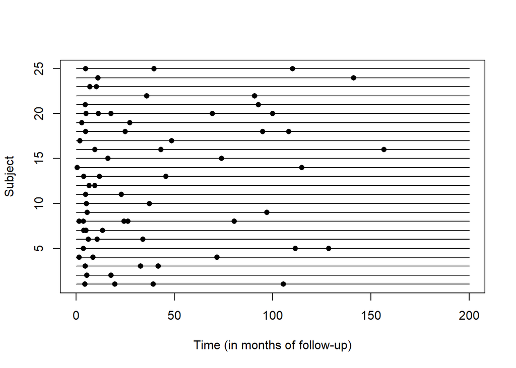

```r
set.seed(21251)
IrregLong::abacus.plot(
    25,
    "time",
    "id",
     data = as.data.frame(SISTRAT_traj),
    0,
    200,
    xlab.abacus = "Time (in months of follow-up)",
    ylab.abacus = "Subject",
    pch.abacus = 16,
    col.abacus = 1
)
```

```r
grDevices::cairo_pdf( paste0(wdpath,"cons/_figs/abacus_AJE.pdf"), width = 7.2, height = 4.8, family = "Times")
 # increase right margin

par(mar = c(4, 4, 1.5, 1), xaxs = "i", yaxs = "i")  # tidy margins
set.seed(21251)
IrregLong::abacus.plot(
  25, "time", "id",
  data = as.data.frame(SISTRAT_traj),
  0, 200,
  xlab.abacus = "Time (in months of follow-up)",
  ylab.abacus = "Subject",
  pch.abacus = 16, col.abacus = 1
)
dev.off()
```

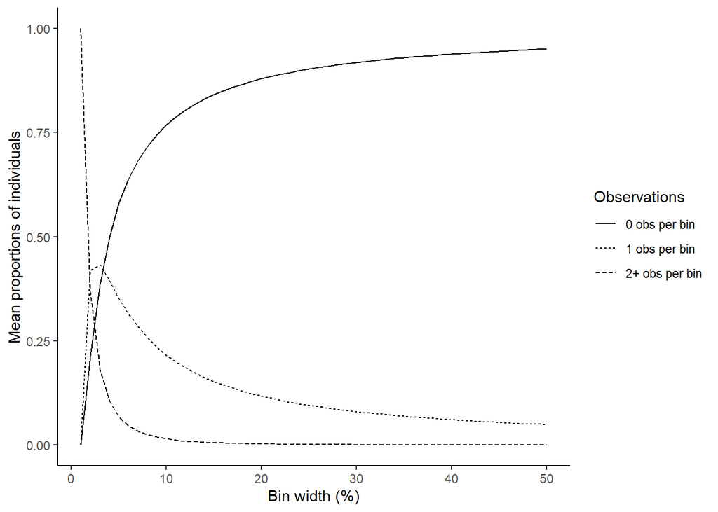

```r
counts <- IrregLong::extent.of.irregularity(as.data.frame(SISTRAT_traj),
                                 time="time",
                                 id="id",
   scheduledtimes=NULL, cutpoints=NULL,ncutpts=50,
   maxfu=16*24, plot=F, legendx=30, legendy=0.8,
  formula=survival::Surv(time.lag,time,event)~1,tau=15*12)
counts_counts<-
structure(c(0, 0, 1, 0.214519948988887, 0.419402441246129,
0.366077609764984, 0.385631869800206, 0.432780712941034, 0.18158741725876,
0.499799599198397, 0.394835124795045, 0.105365276006559, 0.579908908726544,
0.352370194935325, 0.0677208963381308, 0.638197607335884, 0.315455152729702,
0.0463472399344143, 0.682565130260521, 0.284079848007704, 0.0333550217317752,
0.71748496993988, 0.257524139187466, 0.0249908908726544, 0.745661019007712,
0.2350357280217, 0.0193032529705876, 0.768762980506468, 0.215991983967936,
0.0152450355255966, 0.788042200102685, 0.199701883105053, 0.0122559167922622,
0.804253962470395, 0.185829234226028, 0.00991680330357685, 0.818358395111902,
0.173381728491949, 0.00825987639614894, 0.830687348723421, 0.162212737162637,
0.00709991411394217, 0.841265561425882, 0.152763709236655, 0.0059707293374628,
0.850528329386045, 0.144491255237748, 0.00498041537620696, 0.858847105976659,
0.136909112342332, 0.00424378168100908, 0.866415659602032, 0.129819234428453,
0.00376510596951479, 0.873116568064358, 0.123627158623467, 0.00325627331217459,
0.879356895609401, 0.11764073601749, 0.00300236837310986, 0.884843279632859,
0.11254023197911, 0.00261648838803147, 0.889925305155766, 0.107711290349294,
0.00236340449494029, 0.894568583807932, 0.103314930255768, 0.00211648593629948,
0.898783931499362, 0.0993578065221352, 0.00185826197850246, 0.902723264711241,
0.0955991983967936, 0.00167753689196575, 0.906379191950334, 0.0920848690387769,
0.00153593901088891, 0.9097697077657, 0.0888241128722091, 0.00140617936209119,
0.9129245503995, 0.085783254821331, 0.00129219477916873, 0.915873125561468,
0.082926982491629, 0.00119989194690321, 0.918599623489403, 0.0803145685310014,
0.00108580797959555, 0.921176076493162, 0.0778225071844569, 0.00100141632238083,
0.923578976134086, 0.0755101111313536, 0.000910912734560029,
0.925866057183237, 0.0732771327779526, 0.000856810038810403,
0.928000385798335, 0.0712119426017811, 0.000787671599884261,
0.930049189287666, 0.0691908492309294, 0.000759961481404367,
0.931936600473675, 0.0673792028501447, 0.000684196676180644,
0.933738730532318, 0.0656300315618953, 0.000631237905787004,
0.935448888207036, 0.0639690864983556, 0.000582025294608356,
0.937097505033377, 0.062341933283817, 0.000560561682806172, 0.938649116414647,
0.0608261978502459, 0.000524685735106577, 0.940133037694013,
0.059365738128141, 0.000501224177845714, 0.941533283016249, 0.0579991151133436,
0.000467601870407482, 0.942889584666161, 0.0566553826469006,
0.000455032686938359, 0.94417347090876, 0.0553950876960533, 0.000431441395187068,
0.94538734033724, 0.0542175259610129, 0.000395133701746928, 0.946575364167069,
0.0530357157001751, 0.00038892013275563, 0.94768957644496, 0.0519530356651407,
0.000357387889899722, 0.948758122305217, 0.050912430922451, 0.000329446772332544,
0.949789746468819, 0.0499009150025468, 0.000309338528634263,
0.950787392967754, 0.0489152851156859, 0.000297321916560394), dim = c(3L,
50L))

# counts$auc
# [1] 0.2248806
# > counts$transformed.auc
# [1] 86.18703
#→ 86 suggests substantial irregularity in observation times across subjects.

plot_irregularity_05_2024<-
rbind.data.frame(cbind.data.frame(time= 1:50,data.frame(t(counts_counts)))) %>%
    reshape2::melt(id=c("time")) %>%
    dplyr::mutate(Observations= factor(variable, labels=c("0 obs per bin","1 obs per bin", "2+ obs per bin"))) %>%
    ggplot(aes(x=time, y=value, linetype=Observations), linewidth=1)+
    geom_line()+
    #facet_wrap(~type)+ #color=factor(type))
    theme_classic()+
    xlab("Bin width (%)")+
    ylab("Mean proportions of individuals")#+

plot_irregularity_05_2024
```

```r
ggsave(plot_irregularity_05_2024, file= paste0(wdpath,"cons/_figs/irreg250921.jpg"), width=8.5, height=5.5, dpi=500)
```

### Longitudinal formatting

We creates dummy variables (binary 0/1 indicators) from categorical variables in the dataset sdat, for occupation status, starting/initial and primary substance.

We also centered the year variable around 2015 (`year_c`), making 2015 the baseline (value = 0), which improves coefficient interpretation and reduces multicollinearity. Second, we standardized age by centering it at the mean and scaling by 10 (`age_c10`), so each unit represents a 10-year difference from the average age—making effects easier to interpret per decade and improving numerical stability. Together, these transformations create meaningful reference points, aid in comparing effect sizes, and support more robust statistical modeling.

```r
# clean memory
gc()

# --- Prepare data: plain data.frame for IrregLong ---
sdat <- as.data.frame(SISTRAT_traj)

# ID as factor; time must be numeric; create visit indicator (every row is a visit)
sdat$id         <- as.numeric(factor(sdat$hash_key))
sdat$time       <- as.numeric(sdat$time)
sdat$event_vis  <- 1L

# Dummified vars
sdat$occ24_inactive <-  as.integer(sdat$occupation_condition_corr24 == "inactive")
sdat$occ24_unemployed <-  as.integer(sdat$occupation_condition_corr24 == "unemployed")
sdat$occ24_employed <-  as.integer(sdat$occupation_condition_corr24 == "employed")

sdat$susinidum_oh <-  as.integer(sdat$sus_ini_mod_mvv == "alcohol")
sdat$susinidum_coc <-  as.integer(sdat$sus_ini_mod_mvv == "cocaine powder")
sdat$susinidum_pbc <-  as.integer(sdat$sus_ini_mod_mvv == "cocaine paste")
sdat$susinidum_mar <-  as.integer(sdat$sus_ini_mod_mvv == "marijuana")
sdat$susinidum_oth <-  as.integer(sdat$sus_ini_mod_mvv == "others")

sdat$susprindum_oh <-  as.integer(sdat$primary_sub_mod == "alcohol")
sdat$susprindum_coc <-  as.integer(sdat$primary_sub_mod == "cocaine powder")
sdat$susprindum_pbc <-  as.integer(sdat$primary_sub_mod == "cocaine paste")
sdat$susprindum_mar <-  as.integer(sdat$primary_sub_mod == "marijuana")
sdat$susprindum_oth <-  as.integer(sdat$primary_sub_mod == "others")

sdat$year_c   <- sdat$year_decimal - 2015
sdat$age_c10  <- (sdat$adm_age_rec3 - mean(sdat$adm_age_rec3, na.rm=TRUE)) / 10

#Ensure treat_log_days exists, is numeric, and finite
#keep NA for non-positive so the lagger can handle it
stopifnot(sdat$treat_log_days[!is.finite(sdat$treat_log_days)]|> length()==0)

sdat$treat_log_days[!is.finite(sdat$treat_log_days)] <- NA_real_
```

```
            used   (Mb) gc trigger   (Mb)  max used   (Mb)
Ncells   4368944  233.4    6929617  370.1   6929617  370.1
Vcells 187141567 1427.8  383282942 2924.3 383282942 2924.3
```

### Intercept-only and general weights

```r
cat("Survival time\n")
summary(sdat$cens_time)
#  Min. 1st Qu.  Median    Mean 3rd Qu.    Max.
# 6.742  90.161 124.871 121.133 157.355 304.871
# Min. 1st Qu.  Median    Mean 3rd Qu.    Max.
# 7.452  95.484 129.484 125.146 159.806 304.871

# Keep your treatment outcome separately (edit if you want a different outcome)
# Here, 1 = noncompletion/dropout; 0 = otherwise
sdat$tr_outcome <- as.integer(sdat$tr_noncompletion)

# --- Max follow-up per subject (use your cens_time in MONTHS) ---
maxfu_df <- aggregate(cens_time ~ id, data = sdat, FUN = function(x) max(x, na.rm = TRUE))
names(maxfu_df) <- c("maxfu.id", "maxfu.time")


# --- Visit-intensity model with inverse-intensity weights ---
# The function will internally create time.lag and tr_outcome.lag because we list them in `lagvars`
i0 <- IrregLong::iiw.weights(
  formulaph  = survival::Surv(time.lag, time, event_vis) ~ tr_outcome.lag + survival::cluster(id),
  # If you want stabilized weights, uncomment and provide a null model (often just cluster):
  # formulanull = ~ survival::cluster(id),
  data       = sdat,
  id         = "id",
  time       = "time",
  event      = "event_vis",          # each row is a visit
  lagvars    = c("time", "tr_outcome"),
  invariant  = "id",
  maxfu      = maxfu_df,             # per-ID maximum follow-up (same units as 'time': months)
  lagfirst   = c(0, 0),              # time.lag = 0 at first visit; tr_outcome.lag = 0 at first visit
  first      = TRUE                  # baseline visit observed with prob = 1
)
```

Warning in survival::Surv(time.lag, time, event_vis): Stop time must be > start time, NA created

```r
# Model summary for the visit-intensity fit
i0$m
# coxph(formula = formulaph, data = datacox)
#
#                             coef  exp(coef)   se(coef)       z      p
# tr_outcome.lag        -6.883e-01  5.025e-01  8.237e-03 -83.560 <2e-16
# survival::cluster(id)  3.000e-07  1.000e+00  4.848e-07   0.619  0.536
#
# Likelihood ratio test=6858  on 2 df, p=< 2.2e-16
# n= 95355, number of events= 67912
#    (45 observations deleted due to missingness)
mf_all <- stats::model.frame(i0$m, data = i0$datacox, na.action = stats::na.pass)
```

Warning in survival::Surv(time.lag, time, event_vis): Stop time must be > start time, NA created

```r
keep_idx <- stats::complete.cases(mf_all)
drop_idx <- which(!keep_idx)
# i0$datacox[which(!keep_idx), c("id","time","time.lag","event_vis","tr_outcome","tr_outcome.lag","cens_time")]

#:#:#:#:#:#:#:#:#:#:#:#:#:#:#:#:#:#:#:#:#:#:#:#:#:#:#:#:#:#:#:#:#:#:#:#:#:#:#:#:
#:#:#:#:#:#:#:#:#:#:#:#:#:#:#:#:#:#:#:#:#:#:#:#:#:#:#:#:#:#:#:#:#:#:#:#:#:#:#:#:
#:#:#:#:#:#:#:#:#:#:#:#:#:#:#:#:#:#:#:#:#:#:#:#:#:#:#:#:#:#:#:#:#:#:#:#:#:#:#:#:

model_vars <- c(
  "time", "event_vis",  # Survival components
  "tr_noncompletion",
  "biopsych_comp_severe",
  "treat_lt_90",
  "treat_log_days",
  "polysubstance_strict",
  "age_c10",
  "year_c",
  "susinidum_oh",
  "susinidum_coc",
  "susinidum_pbc",
  "susinidum_mar",
  "dg_psiq_cie_10_instudy",
  "dg_psiq_cie_10_dg",
  "prim_sub_daily",
  "occ24_inactive",
  "occ24_unemployed",
  "susprindum_oh",
  "susprindum_coc",
  "susprindum_pbc",
  "susprindum_mar",
  "id"
)#age_c10, year_c

cat("Filtered without events with ties")
sdat_filt<- subset(sdat, !id %in% i0$datacox[which(!keep_idx),"id"])
maxfu_df_filt <- subset(maxfu_df, !maxfu.id %in% i0$datacox[which(!keep_idx),"id"])

cat("Mean positive days for lag treat_log_days at 90 days\n")
dplyr::filter(sdat, dit_rec6==90)|> dplyr::select(dit_rec6, treat_log_days)|> pull(treat_log_days)|> mean()

i1_adj <- IrregLong::iiw.weights(
  formulaph  = survival::Surv(time.lag,time,event_vis)~ tr_noncompletion.lag+ biopsych_comp_severe.lag+ treat_lt_90.lag+ treat_log_days.lag+ polysubstance_strict.lag+ age_c10+ year_c+ susinidum_oh+ susinidum_coc+ susinidum_pbc+ susinidum_mar+ dg_psiq_cie_10_instudy+ dg_psiq_cie_10_dg+  prim_sub_daily+ occ24_inactive+ occ24_unemployed+ susprindum_oh+ susprindum_coc+ susprindum_pbc+ susprindum_mar+ survival::cluster(id),
  # If you want stabilized weights, uncomment and provide a null model (often just cluster):
  # formulanull = ~ survival::cluster(id),
  data       = sdat,#[,model_vars],
  id         = "id",
  time       = "time",
  event      = "event_vis",          # each row is a visit
  lagvars= c("time", "tr_noncompletion", "biopsych_comp_severe", "treat_lt_90", "treat_log_days", "polysubstance_strict"),
  invariant  = "id",
  maxfu      = maxfu_df,             # per-ID maximum follow-up (same units as 'time': months)
  lagfirst   = c(5.149111,1,1,1,4.51086,1),              # time.lag = 0 at first visit; tr_outcome.lag = 0 at first visit  #90/30.5 4.51086 es 90 días
  first      = TRUE                  # baseline visit observed with prob = 1
)
```

Warning in survival::Surv(time.lag, time, event_vis): Stop time must be > start time, NA created

```r
# Call iiw.weights w/0s
i1_adj_0 <- IrregLong::iiw.weights(
  formulaph  = survival::Surv(time.lag, time, event_vis) ~
    tr_noncompletion.lag + biopsych_comp_severe.lag + treat_lt_90.lag +
    treat_log_days.lag + polysubstance_strict.lag +
    age_c10+ year_c+
    susinidum_oh + susinidum_coc + susinidum_pbc + susinidum_mar +
    dg_psiq_cie_10_instudy + dg_psiq_cie_10_dg + prim_sub_daily +
    occ24_inactive + occ24_unemployed +
    susprindum_oh + susprindum_coc + susprindum_pbc + susprindum_mar +
    survival::cluster(id),
  data       = sdat,
  id         = "id",
  time       = "time",
  event      = "event_vis",
  # include *all* variables you want lagged (and in the same order for lagfirst)
  lagvars    = c("time", "tr_noncompletion", "biopsych_comp_severe",
                 "treat_lt_90", "treat_log_days", "polysubstance_strict"),
  invariant  = "id",
  maxfu      = maxfu_df,
  # use zeros to avoid integer/double coercion warnings
  lagfirst   = c(5.149111/2, 0, 0, 0, 2.772589, 0),

  first      = TRUE
)
```

Warning in survival::Surv(time.lag, time, event_vis): Stop time must be > start time, NA created

```r
rbind.data.frame(
cbind.data.frame(model= "Primary (after PH, lag=0)",  t(matrix(summary(i1_adj_0$iiw.weight))) ),
cbind.data.frame(model= "Alternative (after PH, lag=1)", t(matrix(summary(i1_adj$iiw.weight)))) )%>%
  {
    knitr::kable(., digits=2, size=10, format="markdown", caption="Weights (no correction for PHs)", col.names= c("Weight",attr(summary(i1_adj$iiw.weight),"names")) )
  }
# |Weight                        | Min.| 1st Qu.| Median| Mean| 3rd Qu.| Max.| NA's|
# |:-----------------------------|----:|-------:|------:|----:|-------:|----:|----:|
# |Primary (after PH, lag=0)     | 0.17|    1.00|   1.11| 1.58|    1.97| 9.03|  982|
# |Alternative (after PH, lag=1) | 0.09|    0.45|   0.86| 0.74|    1.00| 2.35|  982|

# |Weight                        | Min.| 1st Qu.| Median| Mean| 3rd Qu.| Max.|
# |:-----------------------------|----:|-------:|------:|----:|-------:|----:|
# |Primary (after PH, lag=0)     | 0.16|    1.00|   1.09| 1.55|    1.92| 8.78|
# |Alternative (after PH, lag=1) | 0.08|    0.47|   0.93| 0.76|    1.00| 2.56|
```

```
Survival time
   Min. 1st Qu.  Median    Mean 3rd Qu.    Max.
  7.452  95.484 129.484 125.146 159.806 304.871
Call:
coxph(formula = formulaph, data = datacox)

                            coef  exp(coef)   se(coef)       z      p
tr_outcome.lag        -6.883e-01  5.025e-01  8.237e-03 -83.560 <2e-16
survival::cluster(id)  3.000e-07  1.000e+00  4.848e-07   0.619  0.536

Likelihood ratio test=6858  on 2 df, p=< 2.2e-16
n= 95355, number of events= 67912
   (45 observations deleted due to missingness)
Filtered without events with tiesMean positive days for lag treat_log_days at 90 days
[1] 4.51086
```

Weights (no correction for PHs)

| Weight | Min. | 1st Qu. | Median | Mean | 3rd Qu. | Max. |
| --- | --- | --- | --- | --- | --- | --- |
| Primary (after PH, lag=0) | 0.16 | 1.00 | 1.09 | 1.55 | 1.92 | 8.77 |
| Alternative (after PH, lag=1) | 0.08 | 0.47 | 0.93 | 0.76 | 1.00 | 2.56 |

We built patient trajectories in SISTRAT by ordering episodes within each `hash_key`, labeling sequential treatments, and defining each person’s entry date. Using `lubridate::time_length()` on `interval(enter_date, disch_date)` and `interval(enter_date, 2025-05-28)`, we computed follow-up times in months (`time`, `cens_time`), then resolved ties within subjects by adding tiny offsets so repeated times don’t collide. We set the survival time (`surv_time`) to `time` for events and to `cens_time` otherwise (event proxied by `tr_noncompletion`). To examine visit irregularity, we used IrregLong’s diagnostics and summarized the proportions with 0, 1, and ≥2 visits across time bins. Finally, we fitted a visit-intensity (counting-process) model with `IrregLong::iiw.weights()`—treating each row as a visit, lagging key covariates internally, and supplying per-subject maximum follow-up—to obtain inverse-intensity weights for downstream outcome analyses that account for irregular and potentially informative visit times.

### Weights by plan type

```r
#Great—those 45 rows are exactly the ones with zero-length intervals: time == 0 and time.lag == 0 (baseline rows with event_vis == 1). In a counting-process Surv(start, stop, event), stop must be strictly greater than start, so these get dropped.
#:#:#:#:#:#:#:#:#:#:#:#:#:#:#:#:#:#:#:#:#:#:#:#:#:#:#:#:#:#:#:#:#:#:#:#:#:#:#:#:
#:#:#:#:#:#:#:#:#:#:#:#:#:#:#:#:#:#:#:#:#:#:#:#:#:#:#:#:#:#:#:#:#:#:#:#:#:#:#:#:
#Fix: precompute a baseline-safe lag for the covariate yourself and don’t ask IrregLong to re-lag it. Only let IrregLong lag time. This avoids baseline NAs and keeps rows.

## Start from i0$datacox
dat <- data.table::as.data.table(sdat)  # ensure data.table

## Sort
data.table::setorder(dat, id, time)

## Make intervals strictly positive & ordered
eps <- 1e-3
dat[, .idx := seq_len(.N) - 1L, by = .(id, time)]
dat[, time := time + eps * .idx][, .idx := NULL]
dat[, time.lag := data.table::shift(time, type = "lag", fill = 0), by = .(id)]
dat[time <= time.lag, time := time.lag + eps]

## Lagged covariate with baseline = 0 (no NAs on first row)
dat[, tr_outcome_lag0 := data.table::shift(tr_outcome, type = "lag"), by = .(id)]
dat[is.na(tr_outcome_lag0), tr_outcome_lag0 := 0L]

## Per-id max follow-up (keep id types consistent)
dat[, id := as.character(id)]
maxfu_df <- dat[, .(maxfu.time = max(cens_time, na.rm = TRUE)),
                by = .(maxfu.id = id)]

dat[, id := as.character(id)]
data.table::setDF(dat); maxfu_df <- as.data.frame(maxfu_df)

## Refit: only let IrregLong lag time; use our tr_outcome_lag0 in the formula
i0_3 <- IrregLong::iiw.weights(
  formulaph  = survival::Surv(time.lag, time, event_vis) ~ tr_outcome_lag0 + survival::cluster(id),
  data       = dat,
  id         = "id",
  time       = "time",
  event      = "event_vis",
  lagvars    = c("time"),   # we already created tr_outcome_lag0
  invariant  = "id",
  maxfu      = maxfu_df,
  lagfirst   = c(0),        # first time.lag = 0
  first      = TRUE
)
```

Warning in survival::Surv(time.lag, time, event_vis): Stop time must be > start time, NA created

```r
## Sanity check: how many rows would coxph drop now?
mf3 <- stats::model.frame(i0_3$m, data = i0_3$datacox, na.action = stats::na.pass)
```

Warning in survival::Surv(time.lag, time, event_vis): Stop time must be > start time, NA created

```r
sum(!stats::complete.cases(mf3))  # should be ~0 (or just the true oddballs), not ~31928

table(is.na(i0_3$iiw.weight))
invisible("didnt change, despite no more NAs in weights")

#:#:#:#:#:#:#:#:#:#:#:#:#:#:#:#:#:#:#:#:#:#:#:#:#:#:#:#:#:#:
#:#:#:#:#:#:#:#:#:#:#:#:#:#:#:#:#:#:#:#:#:#:#:#:#:#:#:#:#:#:

cat("Mean positive days for lag treat_log_days at 15 days\n")
dplyr::filter(sdat, dit_rec6==15)|> dplyr::select(dit_rec6, treat_log_days)|> pull(treat_log_days)|> mean()

cat("$:$:$:$:$:$:$:$:$:$:$:$:$:$:\n")
cat("Weights by plan type\n")
cat("$:$:$:$:$:$:$:$:$:$:$:$:$:$:\n")

plan_types <- unique(dat$plan_type_mod)

iiw_by_plan0 <- lapply(plan_types, function(pt) {
  cat("Running for:", pt, "\n")
  # Subset as plain data.frame
  dat_sub <- dat |> filter(plan_type_mod == pt) |> as.data.frame()
  # Subset maxfu_df to only the ids in dat_sub
  maxfu_sub <- maxfu_df[maxfu_df$maxfu.id %in% dat_sub$id, , drop = FALSE]
  IrregLong::iiw.weights(
    formulaph  = survival::Surv(time.lag, time, event_vis) ~
      tr_noncompletion.lag + biopsych_comp_severe.lag +
      treat_lt_90.lag + treat_log_days.lag + polysubstance_strict.lag +
      age_c10 + year_c +
      susinidum_oh + susinidum_coc + susinidum_pbc + susinidum_mar +
      dg_psiq_cie_10_instudy + dg_psiq_cie_10_dg + prim_sub_daily +
      occ24_inactive + occ24_unemployed +
      susprindum_oh + susprindum_coc + susprindum_pbc + susprindum_mar +
      survival::cluster(id),
    data       = dat_sub,
    id         = "id",
    time       = "time",
    event      = "event_vis",
    lagvars    = c("time", "tr_noncompletion", "biopsych_comp_severe",
                   "treat_lt_90", "treat_log_days", "polysubstance_strict"),
    invariant  = "id",
    maxfu      = maxfu_sub,  # stratified by subset IDs
    lagfirst   = c(5.149111, 0, 0, 0, 2.772589, 0),
    first      = TRUE
  )
})
```

```r
names(iiw_by_plan0) <- plan_types

iiw_by_plan1 <- lapply(plan_types, function(pt) {
  cat("Running for:", pt, "\n")
  # Subset as plain data.frame
  dat_sub <- dat |> dplyr::filter(plan_type_mod == pt) |> as.data.frame()
  # Subset maxfu_df to only the ids in dat_sub
  maxfu_sub <- maxfu_df[maxfu_df$maxfu.id %in% dat_sub$id, , drop = FALSE]
  IrregLong::iiw.weights(
    formulaph  = survival::Surv(time.lag, time, event_vis) ~
      tr_noncompletion.lag + biopsych_comp_severe.lag +
      treat_lt_90.lag + treat_log_days.lag + polysubstance_strict.lag +
      age_c10 + year_c +
      susinidum_oh + susinidum_coc + susinidum_pbc + susinidum_mar +
      dg_psiq_cie_10_instudy + dg_psiq_cie_10_dg + prim_sub_daily +
      occ24_inactive + occ24_unemployed +
      susprindum_oh + susprindum_coc + susprindum_pbc + susprindum_mar +
      survival::cluster(id),
    data       = dat_sub,
    id         = "id",
    time       = "time",
    event      = "event_vis",
    lagvars    = c("time", "tr_noncompletion", "biopsych_comp_severe",
                   "treat_lt_90", "treat_log_days", "polysubstance_strict"),
    invariant  = "id",
    maxfu      = maxfu_sub,  # stratified by subset IDs
    lagfirst   = c(5.149111, 1, 1, 1, 4.51086, 1),
    first      = TRUE
  )
})
```

Warning in survival::Surv(time.lag, time, event_vis): Stop time must be > start time, NA created

```r
names(iiw_by_plan1) <- plan_types


#:#:#:#:#:#:#:#:#:#:#:#:#:#:#:#:#:#:#:#:#:#:#:#:#:#:#:#:#:#:
#:#:#:#:#:#:#:#:#:#:#:#:#:#:#:#:#:#:#:#:#:#:#:#:#:#:#:#:#:#:
cat("Extract weights\n")
extract_weights <- function(iiw_by_plan, dat,
                            weight_name = "iiw.weight",
                            out_col = "iiw_weight",
                            na_to_one = TRUE) {
  weights_list <- lapply(names(iiw_by_plan), function(pt) {
    mod <- iiw_by_plan[[pt]]
    dat_sub <- dat[dat$plan_type_mod == pt, , drop = FALSE]
    # Check weight existence
    if (!weight_name %in% names(mod)) {
      stop(sprintf("Weight '%s' not found in model for plan type '%s'",
                   weight_name, pt))
    }
    w <- mod[[weight_name]]
    if (length(w) != nrow(dat_sub)) {
      stop(sprintf("Row mismatch for %s: %d weights vs %d rows",
                   pt, length(w), nrow(dat_sub)))
    }
    if (na_to_one) {
      w[is.na(w)] <- 1
    }
    dat_sub[[out_col]] <- w
    dat_sub
  })
  do.call(rbind, weights_list)
}

dat_with_weights_stab <- extract_weights(iiw_by_plan0, dat,
                                         weight_name = "iiw.weight",
                                         out_col = "iiw_weight0_stab")


dat_with_weights_stab1 <- extract_weights(iiw_by_plan1, dat,
                                         weight_name = "iiw.weight",
                                         out_col = "iiw_weight1_stab")

dat_with_weights_stab_cons<-
dat_with_weights_stab|> #67957
  dplyr::left_join(dat_with_weights_stab1[,c("rn","iiw_weight1_stab")], by="rn")|>
  dplyr::arrange(hash_key, adm_age_rec3)

#:#:#:#:#:#:#:#:#:#:#:#:#:#:#:#:#:#:#:#:#:#:#:#:#:#:#:#:#:#:

cat("Add weight 1 in case of first treatment for time.lag==0\n")
table(subset(dat_with_weights_stab_cons, treatment==1)$time.lag)

dat_with_weights_stab_cons$iiw_weight0_stab <- ifelse(
  is.na(dat_with_weights_stab_cons$iiw_weight0_stab) & dat_with_weights_stab_cons$time.lag == 0,
  1,
  dat_with_weights_stab_cons$iiw_weight0_stab
)
dat_with_weights_stab_cons$iiw_weight1_stab <- ifelse(
  is.na(dat_with_weights_stab_cons$iiw_weight1_stab) & dat_with_weights_stab_cons$time.lag == 0,
  1,
  dat_with_weights_stab_cons$iiw_weight1_stab
)
#:#:#:#:#:#:#:#:#:#:#:#:#:#:#:#:#:#:#:#:#:#:#:#:#:#:#:#:#:#:
#:#:#:#:#:#:#:#:#:#:#:#:#:#:#:#:#:#:#:#:#:#:#:#:#:#:#:#:#:#:
#:#:#:#:#:#:#:#:#:#:#:#:#:#:#:#:#:#:#:#:#:#:#:#:#:#:#:#:#:#:

rbind.data.frame(
cbind.data.frame(model= "Primary (after PH, lag=0)",
                 t(matrix(summary(dat_with_weights_stab_cons$iiw_weight0_stab ))) ),
cbind.data.frame(model= "Alternative (after PH, lag=1)",  t(matrix(summary(dat_with_weights_stab_cons$iiw_weight1_stab)))) )%>%
  {
    knitr::kable(., digits=2, size=10, format="markdown", caption="Weights (no correction for PHs)", col.names= c("Weight",attr(summary(dat_with_weights_stab_cons$iiw_weight1_stab),"names")) )
  }

w_primary_tr <- cap(dat_with_weights_stab_cons$iiw_weight0_stab, c(0.025, 0.975))
w_alt_tr     <- cap(dat_with_weights_stab_cons$iiw_weight1_stab, c(0.025, 0.975))

w0      <- dat_with_weights_stab_cons$iiw_weight0_stab
w0_tr   <- cap(w_primary_tr, c(0.025, 0.975))
w1      <- dat_with_weights_stab_cons$iiw_weight1_stab
w1_tr   <- cap(w_alt_tr, c(0.025, 0.975))

cbind.data.frame(type= c("Lag=0, raw","lag=0 trunc 2.5–97.5%","lag=1 raw","lag=1 trunc 2.5–97.5%"),
dplyr::bind_rows(
  summ_w(w0,    "lag=0 raw"),
  summ_w(w0_tr, "lag=0 trunc 2.5–97.5%"),
  summ_w(w1,    "lag=1 raw"),
  summ_w(w1_tr, "lag=1 trunc 2.5–97.5%")
))|> knitr::kable("markdown", digits=2, caption= "Weights, stabilized and truncated")
# |type                  | n_non_na| n_na|  min|  q01|  q25| median| mean|  q75|  q99|  max| prop_lt_0.2| prop_gt_5|      ESS|
# |:---------------------|--------:|----:|----:|----:|----:|------:|----:|----:|----:|----:|-----------:|---------:|--------:|
# |Lag=0, raw            |    67957|    0| 0.19| 0.36| 1.00|   1.00| 1.06| 1.00| 2.67| 7.05|           0|         0| 59450.19|
# |lag=0 trunc 2.5–97.5% |    67957|    0| 0.42| 0.42| 0.95|   0.95| 1.00| 0.95| 2.11| 2.11|           0|         0| 61803.67|
# |lag=1 raw             |    67957|    0| 0.15| 0.35| 1.00|   1.00| 1.07| 1.00| 2.82| 8.25|           0|         0| 58250.96|
# |lag=1 trunc 2.5–97.5% |    67957|    0| 0.41| 0.41| 0.95|   0.95| 1.00| 0.95| 2.14| 2.14|           0|         0| 61572.35|
# RE-INTEGRATE!
dat_with_weights_stab_cons$w0_tr <-  w0_tr
dat_with_weights_stab_cons$w1_tr <-  w1_tr
```

```
[1] 27444

FALSE
67957
Mean positive days for lag treat_log_days at 15 days
[1] 2.772589
$:$:$:$:$:$:$:$:$:$:$:$:$:$:
Weights by plan type
$:$:$:$:$:$:$:$:$:$:$:$:$:$:
Running for: GP basic ambulatory
Running for: GP residential
Running for: WO residential
Running for: GP intensive ambulatory
Running for: WO intensive ambulatory
Running for: GP basic ambulatory
Running for: GP residential
Running for: WO residential
Running for: GP intensive ambulatory
Running for: WO intensive ambulatory
Extract weights
Add weight 1 in case of first treatment for time.lag==0

    0
27445
```

Weights (no correction for PHs)

| Weight | Min. | 1st Qu. | Median | Mean | 3rd Qu. | Max. |
| --- | --- | --- | --- | --- | --- | --- |
| Primary (after PH, lag=0) | 0.15 | 1.00 | 1.02 | 1.46 | 1.78 | 7.35 |
| Alternative (after PH, lag=1) | 0.08 | 0.51 | 0.93 | 0.78 | 1.00 | 3.12 |

Weights, stabilized and truncated

| type | n_non_na | n_na | min | q01 | q25 | median | mean | q75 | q99 | max | prop_lt_0.2 | prop_gt_5 | ESS |
| --- | --- | --- | --- | --- | --- | --- | --- | --- | --- | --- | --- | --- | --- |
| Lag=0, raw | 67957 | 0 | 0.15 | 0.59 | 1.00 | 1.02 | 1.46 | 1.78 | 3.93 | 7.35 | 0.00 | 0 | 54514.18 |
| lag=0 trunc 2.5–97.5% | 67957 | 0 | 0.72 | 0.72 | 1.00 | 1.02 | 1.45 | 1.78 | 3.37 | 3.37 | 0.00 | 0 | 56078.21 |
| lag=1 raw | 67957 | 0 | 0.08 | 0.19 | 0.51 | 0.93 | 0.78 | 1.00 | 1.46 | 3.12 | 0.01 | 0 | 59071.99 |
| lag=1 trunc 2.5–97.5% | 67957 | 0 | 0.23 | 0.23 | 0.51 | 0.93 | 0.77 | 1.00 | 1.27 | 1.27 | 0.00 | 0 | 59698.31 |

We show a simplified model. The “effective sample size” (ESS) is a measure of the sample size a non-weighted sample would have to have to achieve the same level of precision as the weighted sample (Ridgeway 2006).

```r
tidy_iiw_by_plan <- function(models_by_plan,
                             conf.level = 0.95,
                             digits = 3,
                             drop_cluster = TRUE,
                             sort = c("none","plan_term"),
                             return_tidytable = FALSE) {
  sort <- match.arg(sort)

  # preserve the incoming order of plan types
  plan_levels <- names(models_by_plan) %||% seq_along(models_by_plan)

  out <- purrr::imap_dfr(models_by_plan, function(x, plan_lbl) {
    fit <- if (!is.null(x$m)) x$m else x

    tbl <- broom::tidy(fit, exponentiate = TRUE, conf.int = TRUE,
                       conf.level = conf.level)

    if (drop_cluster) {
      tbl <- dplyr::filter(tbl, !grepl("cluster\\(", term))
    }

    # keep broom's original row order
        tbl <- tbl %>%
          dplyr::mutate(
            .term_order = dplyr::row_number(),
            plan_type   = plan_lbl,
            HR          = round(estimate, digits),
            CI_low      = round(conf.low, digits),
            CI_high     = round(conf.high, digits),
            CI95 = sprintf( paste0("%.", digits, "f (%.", digits, "f, %.", digits, "f)"), as.numeric(HR), as.numeric(CI_low), as.numeric(CI_high) ),
            p           = sprintf("%1.4f", signif(p.value, 3)),
          ) %>%
          dplyr::select(plan_type, .term_order, term, CI95, p)

  })

  # optional sorting
  if (sort == "plan_term") {
    out <- out %>%
      mutate(plan_type = factor(plan_type, levels = plan_levels)) %>%
      arrange(plan_type, .term_order)
  } else {
    # no reordering: keep original list order & term order
    out <- out %>%
      mutate(plan_type = factor(plan_type, levels = plan_levels)) %>%
      arrange(as.integer(plan_type), .term_order)
  }

  out <- out %>% tidytable::select(-.term_order)

  if (return_tidytable) {
    out <- tidytable::as_tidytable(as.data.frame(out))  # robust conversion
  }

  out
}



res_by_plan0 <- tidy_iiw_by_plan(iiw_by_plan0, digits = 2, return_tidytable = TRUE)
res_by_plan1 <- tidy_iiw_by_plan(iiw_by_plan1, digits = 2, return_tidytable = TRUE)

DT::datatable(
  res_by_plan0,
  rownames = FALSE,   # <— prevent rownames from becoming an extra column
  caption = "Visit-intensity model estimates (hazard ratios with 95% CI) by treatment setting, lag 0",
  colnames = c("Plan type", "Variable", "HR (95% CI)", "p-value"),
  options = list(
    pageLength =  105,
    scrollX = TRUE,
    scrollY = "400px",
    dom = 'Brt'
  )
)
DT::datatable(
  res_by_plan1,
  rownames = FALSE,   # <— prevents rownames from becoming an extra column
  caption = "Visit-intensity model estimates (hazard ratios with 95% CI) by treatment setting, lag 1",
  colnames = c("Plan type", "Variable",  "HR (95% CI)", "p-value"),
  options = list(
    pageLength = 105,
    scrollX = TRUE,
    scrollY = "400px",
    dom = 'Brt'
  )
)
#:#:#:#:#:#:#:#:#:#:#:#:#:#:#:#:#:#:#:#:#:#:#:#:#:#:#:#:#:#:#:#:#:#:#:#:#:#:#:#:
#:#:#:#:#:#:#:#:#:#:#:#:#:#:#:#:#:#:#:#:#:#:#:#:#:#:#:#:#:#:#:#:#:#:#:#:#:#:#:#:
iiw_by_plan0_general<-
  IrregLong::iiw.weights(
    formulaph  = survival::Surv(time.lag, time, event_vis) ~
      tr_noncompletion.lag + biopsych_comp_severe.lag +
      treat_lt_90.lag + treat_log_days.lag + polysubstance_strict.lag +
      age_c10 + year_c +
      susinidum_oh + susinidum_coc + susinidum_pbc + susinidum_mar +
      dg_psiq_cie_10_instudy + dg_psiq_cie_10_dg + prim_sub_daily +
      occ24_inactive + occ24_unemployed +
      susprindum_oh + susprindum_coc + susprindum_pbc + susprindum_mar +
      survival::cluster(id),
    data       = dat,
    id         = "id",
    time       = "time",
    event      = "event_vis",
    lagvars    = c("time", "tr_noncompletion", "biopsych_comp_severe",
                   "treat_lt_90", "treat_log_days", "polysubstance_strict"),
    invariant  = "id",
    maxfu      = maxfu_df,  # stratified by subset IDs
    lagfirst   = c(5.149111, 0, 0, 0, 2.772589, 0),
    first      = TRUE
  )
```

Warning in survival::Surv(time.lag, time, event_vis): Stop time must be > start time, NA created

```r
iiw_by_plan1_general<-
  IrregLong::iiw.weights(
    formulaph  = survival::Surv(time.lag, time, event_vis) ~
      tr_noncompletion.lag + biopsych_comp_severe.lag +
      treat_lt_90.lag + treat_log_days.lag + polysubstance_strict.lag +
      age_c10 + year_c +
      susinidum_oh + susinidum_coc + susinidum_pbc + susinidum_mar +
      dg_psiq_cie_10_instudy + dg_psiq_cie_10_dg + prim_sub_daily +
      occ24_inactive + occ24_unemployed +
      susprindum_oh + susprindum_coc + susprindum_pbc + susprindum_mar +
      survival::cluster(id),
    data       = dat,
    id         = "id",
    time       = "time",
    event      = "event_vis",
    lagvars    = c("time", "tr_noncompletion", "biopsych_comp_severe",
                   "treat_lt_90", "treat_log_days", "polysubstance_strict"),
    invariant  = "id",
    maxfu      = maxfu_df,  # stratified by subset IDs
    lagfirst   = c(5.149111, 1, 1, 1, 4.51086, 1),
    first      = TRUE
  )
```

Warning in survival::Surv(time.lag, time, event_vis): Stop time must be > start time, NA created

```r
broom::tidy(iiw_by_plan0_general$m, exp=T, conf.int=T)|>
  dplyr::mutate(CI95 = sprintf( paste0("%.", 2, "f (%.", 2, "f, %.", 2, "f)"), as.numeric(estimate), as.numeric(conf.low), as.numeric(conf.high) )) |>
  dplyr::select(-any_of(c("estimate", "conf.low", "conf.high"))) |>
knitr::kable("markdown", caption= "Visiting process, general model, lag 0", digits=2)

broom::tidy(iiw_by_plan1_general$m, exp=T, conf.int=T)|>
  dplyr::mutate(CI95 = sprintf( paste0("%.", 2, "f (%.", 2, "f, %.", 2, "f)"), as.numeric(estimate), as.numeric(conf.low), as.numeric(conf.high) )) |>
  dplyr::select(-any_of(c("estimate", "conf.low", "conf.high"))) |>
knitr::kable("markdown", caption= "Visiting process, general model, lag 1", digits=2)
```

[output not shown]

[output cut: 90 more lines]

[output not shown]

[output cut: 90 more lines]

Visiting process, general model, lag 0

| term | std.error | statistic | p.value | CI95 |
| --- | --- | --- | --- | --- |
| tr_noncompletion.lag | 0.01 | -24.59 | 0.00 | 0.76 (0.74, 0.77) |
| biopsych_comp_severe.lag | 0.01 | -1.75 | 0.08 | 0.98 (0.96, 1.00) |
| treat_lt_90.lag | 0.02 | -24.47 | 0.00 | 0.69 (0.67, 0.71) |
| treat_log_days.lag | 0.01 | -61.98 | 0.00 | 0.73 (0.72, 0.74) |
| polysubstance_strict.lag | 0.01 | -30.10 | 0.00 | 0.70 (0.69, 0.72) |
| age_c10 | 0.01 | -63.45 | 0.00 | 0.41 (0.39, 0.42) |
| year_c | 0.00 | -54.19 | 0.00 | 0.93 (0.93, 0.93) |
| susinidum_oh | 0.07 | 4.71 | 0.00 | 1.37 (1.20, 1.55) |
| susinidum_coc | 0.07 | 4.31 | 0.00 | 1.34 (1.17, 1.53) |
| susinidum_pbc | 0.07 | 4.10 | 0.00 | 1.32 (1.15, 1.50) |
| susinidum_mar | 0.07 | 4.33 | 0.00 | 1.34 (1.17, 1.52) |
| dg_psiq_cie_10_instudyTRUE | 0.02 | 11.69 | 0.00 | 1.20 (1.16, 1.23) |
| dg_psiq_cie_10_dgTRUE | 0.01 | -0.23 | 0.82 | 1.00 (0.98, 1.02) |
| prim_sub_daily | 0.01 | 0.15 | 0.88 | 1.00 (0.98, 1.02) |
| occ24_inactive | 0.01 | 1.92 | 0.05 | 1.02 (1.00, 1.05) |
| occ24_unemployed | 0.01 | 5.36 | 0.00 | 1.06 (1.04, 1.08) |
| susprindum_oh | 0.04 | 0.82 | 0.41 | 1.03 (0.96, 1.10) |
| susprindum_coc | 0.04 | 3.27 | 0.00 | 1.12 (1.05, 1.21) |
| susprindum_pbc | 0.03 | 1.38 | 0.17 | 1.05 (0.98, 1.12) |
| susprindum_mar | 0.04 | 0.24 | 0.81 | 1.01 (0.93, 1.09) |
| survival::cluster(id) | 0.00 | -0.51 | 0.61 | 1.00 (1.00, 1.00) |

Visiting process, general model, lag 1

| term | std.error | statistic | p.value | CI95 |
| --- | --- | --- | --- | --- |
| tr_noncompletion.lag | 0.01 | 7.66 | 0.00 | 1.11 (1.08, 1.14) |
| biopsych_comp_severe.lag | 0.01 | 33.24 | 0.00 | 1.39 (1.36, 1.41) |
| treat_lt_90.lag | 0.01 | 52.60 | 0.00 | 2.15 (2.09, 2.22) |
| treat_log_days.lag | 0.01 | 24.05 | 0.00 | 1.21 (1.19, 1.23) |
| polysubstance_strict.lag | 0.01 | -6.30 | 0.00 | 0.92 (0.90, 0.95) |
| age_c10 | 0.01 | -72.07 | 0.00 | 0.36 (0.35, 0.37) |
| year_c | 0.00 | -64.95 | 0.00 | 0.91 (0.91, 0.92) |
| susinidum_oh | 0.07 | 5.36 | 0.00 | 1.42 (1.25, 1.62) |
| susinidum_coc | 0.07 | 5.04 | 0.00 | 1.41 (1.23, 1.60) |
| susinidum_pbc | 0.07 | 4.98 | 0.00 | 1.39 (1.22, 1.59) |
| susinidum_mar | 0.07 | 4.71 | 0.00 | 1.37 (1.20, 1.56) |
| dg_psiq_cie_10_instudyTRUE | 0.02 | 2.84 | 0.00 | 1.04 (1.01, 1.08) |
| dg_psiq_cie_10_dgTRUE | 0.01 | -3.89 | 0.00 | 0.96 (0.94, 0.98) |
| prim_sub_daily | 0.01 | -3.43 | 0.00 | 0.97 (0.95, 0.99) |
| occ24_inactive | 0.01 | -0.83 | 0.41 | 0.99 (0.97, 1.01) |
| occ24_unemployed | 0.01 | 1.25 | 0.21 | 1.01 (0.99, 1.04) |
| susprindum_oh | 0.03 | 1.73 | 0.08 | 1.06 (0.99, 1.14) |
| susprindum_coc | 0.04 | 2.95 | 0.00 | 1.11 (1.04, 1.19) |
| susprindum_pbc | 0.03 | -0.55 | 0.58 | 0.98 (0.92, 1.05) |
| susprindum_mar | 0.04 | 0.91 | 0.36 | 1.04 (0.96, 1.12) |
| survival::cluster(id) | 0.00 | 0.13 | 0.90 | 1.00 (1.00, 1.00) |

```r
make_lagged_tt <- function(df, id = "id", time = "time",
                           vars, first_vals = NULL, suffix = ".lag") {

  # Ensure suffix is a single string
  suffix <- as.character(suffix)[1L]

  out <- df |>
    tidytable::arrange(!!rlang::sym(id), !!rlang::sym(time)) |>
    tidytable::group_by(!!rlang::sym(id))

  # Create lagged columns without across/glue
  for (v in vars) {
    out[[paste0(v, suffix)]] <- dplyr::lag(out[[v]])
  }

  out <- tidytable::ungroup(out)

  if (!is.null(first_vals)) {
    stopifnot(all(names(first_vals) %in% vars))
    first_idx <- !duplicated(out[[id]])
    for (v in names(first_vals)) {
      out[[paste0(v, suffix)]][first_idx] <- first_vals[[v]]
    }
  }
  out
}


# Your lag spec (matches your IIW setup)
vars_to_lag <- c("tr_noncompletion", "biopsych_comp_severe",
                 "treat_lt_90", "treat_log_days", "polysubstance_strict")

first_vals <- c(tr_noncompletion     = 1,
                biopsych_comp_severe = 1,
                treat_lt_90          = 1,
                #treat_log_days       = 4.51086,
                polysubstance_strict = 1)

dat_ag <- make_lagged_tt(
  df         = dat,
  id         = "id",
  time       = "time",
  vars       = vars_to_lag,
  first_vals = first_vals,
  suffix     = ".lag"
)
#:#:#:#:#:#:#:#:#:#:#:#:#:#:#:#:#:#:#:#:#:#:#:#:#:#:#:#:#:#:#:#:#:#:#:#:#:#:#:#:
#:#:#:#:#:#:#:#:#:#:#:#:#:#:#:#:#:#:#:#:#:#:#:#:#:#:#:#:#:#:#:#:#:#:#:#:#:#:#:#:
#:#:#:#:#:#:#:#:#:#:#:#:#:#:#:#:#:#:#:#:#:#:#:#:#:#:#:#:#:#:#:#:#:#:#:#:#:#:#:#:
dd <- rms::datadist(dat_ag); base::options(datadist = "dd")
```

Warning in rms::datadist(dat_ag): LB_age_subs_onset_rec2 is constant

Warning in rms::datadist(dat_ag): event_vis is constant

```r
fit_ag_cph <- rms::cph(
  survival::Surv(time.lag, time, event_vis) ~
    tr_noncompletion.lag + biopsych_comp_severe.lag +
    treat_lt_90.lag + treat_log_days.lag + polysubstance_strict.lag +
    age_c10 + year_c +
    susinidum_oh + susinidum_coc + susinidum_pbc + susinidum_mar +
    dg_psiq_cie_10_instudy + dg_psiq_cie_10_dg + prim_sub_daily +
    occ24_inactive + occ24_unemployed +
    susprindum_oh + susprindum_coc + susprindum_pbc + susprindum_mar +
    rms::strat(plan_type_mod),   # <- use strat() here
  data = dat_ag,
  ties = "efron",
  x = TRUE, y = TRUE, surv = TRUE
)

# Cluster-robust covariance (analogous to survival::coxph(... + cluster(id)))
fit_ag_cph <- rms::robcov(fit_ag_cph, cluster = dat_ag$id)
hr_ci_cph <- function(fit, digits = 3) {
  co <- stats::coef(fit)
  se <- base::sqrt(base::diag(stats::vcov(fit)))
  z  <- stats::qnorm(0.975)

  tibble::tibble(
    term = base::names(co),
    HR   = base::round(base::exp(co), digits),
    LCL  = base::round(base::exp(co - z*se), digits),
    UCL  = base::round(base::exp(co + z*se), digits),
    CI95 = base::sprintf(paste0("%.", digits, "f (%.", digits, "f, %.", digits, "f)"),
                         HR, LCL, UCL)
  )
}

res_ag <- hr_ci_cph(fit_ag_cph, digits= 2)

knitr::kable(res_ag, "markdown", caption="General Andersen-Gill model for the visit intensity (strata included as a term)", digits=2)
```

| term | HR | LCL | UCL | CI95 |
| --- | --- | --- | --- | --- |
| tr_noncompletion.lag | 1.11 | 1.09 | 1.14 | 1.11 (1.09, 1.14) |
| biopsych_comp_severe.lag | 1.42 | 1.40 | 1.45 | 1.42 (1.40, 1.45) |
| treat_lt_90.lag | 2.15 | 2.11 | 2.20 | 2.15 (2.11, 2.20) |
| treat_log_days.lag | 1.24 | 1.23 | 1.26 | 1.24 (1.23, 1.26) |
| polysubstance_strict.lag | 0.90 | 0.88 | 0.92 | 0.90 (0.88, 0.92) |
| age_c10 | 0.38 | 0.37 | 0.39 | 0.38 (0.37, 0.39) |
| year_c | 0.92 | 0.92 | 0.92 | 0.92 (0.92, 0.92) |
| susinidum_oh | 1.37 | 1.21 | 1.56 | 1.37 (1.21, 1.56) |
| susinidum_coc | 1.38 | 1.22 | 1.57 | 1.38 (1.22, 1.57) |
| susinidum_pbc | 1.35 | 1.19 | 1.53 | 1.35 (1.19, 1.53) |
| susinidum_mar | 1.34 | 1.18 | 1.52 | 1.34 (1.18, 1.52) |
| dg_psiq_cie_10_instudy | 1.62 | 1.57 | 1.66 | 1.62 (1.57, 1.66) |
| dg_psiq_cie_10_dg | 0.99 | 0.97 | 1.00 | 0.99 (0.97, 1.00) |
| prim_sub_daily | 0.98 | 0.97 | 1.00 | 0.98 (0.97, 1.00) |
| occ24_inactive | 0.99 | 0.96 | 1.01 | 0.99 (0.96, 1.01) |
| occ24_unemployed | 1.05 | 1.03 | 1.07 | 1.05 (1.03, 1.07) |
| susprindum_oh | 1.10 | 1.02 | 1.17 | 1.10 (1.02, 1.17) |
| susprindum_coc | 1.14 | 1.06 | 1.22 | 1.14 (1.06, 1.22) |
| susprindum_pbc | 1.04 | 0.97 | 1.11 | 1.04 (0.97, 1.11) |
| susprindum_mar | 1.06 | 0.98 | 1.14 | 1.06 (0.98, 1.14) |

##### Intermediate saving

Save the current R environment at that intermediate step.

```r
#save.image(file = file.path(wdpath, "data/20241015_out/psu", "intermediate.RData"))
```

##### Association between non-completion and PSU, general

```r
gc()
if(grepl("SISTRAT 2023",getwd())){
    wdpath<-
        paste0(gsub("/cons","",gsub("cons","",paste0(getwd(),"/cons"))))
} else {
    wdpath<-
        paste0(paste0(gsub("/SISTRAT 2022 \\(github\\)/_proposal_grant/2023","",getwd())),"/SISTRAT 2023/")
}
#load(file = file.path(wdpath, "data/20241015_out/psu", "intermediate.RData"))

if (interactive()) {
job::job({
  gc()
    suppressPackageStartupMessages({
    library(dplyr)
    library(sandwich)
  })
  ## -------------------- MODEL --------------------
  ff_formula <- tr_noncompletion ~ polysubstance_strict + age_c10 + year_c +
    susinidum_oh + susinidum_coc + susinidum_pbc + susinidum_mar +
    dg_psiq_cie_10_instudy + dg_psiq_cie_10_dg +
    prim_sub_daily + occ24_inactive + occ24_unemployed +
    susprindum_coc + susprindum_pbc + susprindum_mar

  vars_ff    <- all.vars(ff_formula)
  vars_extra <- c("id", "w0_tr", "w1_tr")
  vars_need  <- unique(c(vars_ff, vars_extra))

  # No data.table
  base <- as.data.frame(dat_with_weights_stab_cons)[, vars_need, drop = FALSE]

  # Model frame without NAs to construct 'keep' mask
  mf_all <- stats::model.frame(ff_formula, data = base, na.action = NULL)
  keep   <- stats::complete.cases(mf_all)
  if (!any(keep)) stop("No hay casos completos para la fórmula del modelo.")

  mf <- mf_all[keep, , drop = FALSE]                    # datos alineados con la fórmula
  id_vec <- base$id[keep]
  if (anyNA(id_vec)) stop("La variable 'id' contiene NA tras el filtrado.")
  id_int <- as.integer(factor(id_vec, exclude = NULL))  # clúster compacto y estable

  ## Clean weights (positive, finite, mean=1), aligned to 'keep'
  clean_weights <- function(w) {
    w[!is.finite(w) | is.na(w) | w <= 0] <- 1
    w / mean(w, na.rm = TRUE)
  }
  w0 <- clean_weights(base$w0_tr[keep])
  w1 <- clean_weights(base$w1_tr[keep])

  stopifnot(is.numeric(w0), is.numeric(w1),
            length(w0) == nrow(mf), length(w1) == nrow(mf))

  ncl <- length(unique(id_int))

  ## -------------------- ROBUST --------------------
  ## --- Fit with cluster-robust SEs; embed weights into data to avoid scoping bugs ---
  fit_glm_robust <- function(weights_vec = NULL) {
    df <- mf
    if (is.null(weights_vec)) {
      m <- stats::glm(ff_formula, data = df, family = stats::poisson())
    } else {
      df$.__w <- weights_vec                     # <- embed weights here
      m <- stats::glm(ff_formula, data = df, family = stats::poisson(), weights = .__w)
    }
    vc <- if (ncl >= 2) sandwich::vcovCL(m, cluster = id_int) else sandwich::vcovHC(m, type = "HC0")
    list(model = m, vcov = vc)
  }

  m_un <- fit_glm_robust(NULL)
  m_w0 <- fit_glm_robust(w0)
  m_w1 <- fit_glm_robust(w1)

  ## -------------------- RESULTS --------------------
  extract_results <- function(obj, name) {
    co <- stats::coef(obj$model)
    se <- sqrt(diag(obj$vcov))
    z  <- stats::qnorm(0.975)
    out <- data.frame(
      term    = names(co),
      est     = exp(co),
      cilo    = exp(co - z * se),
      ciup    = exp(co + z * se),
      p.value = 2 * stats::pnorm(abs(co / se), lower.tail = FALSE),
      check.names = FALSE
    )
    names(out)[-1] <- paste0(names(out)[-1], "_", name)
    out
  }

  est_summary <- Reduce(
    function(x, y) dplyr::full_join(x, y, by = "term"),
    list(
      extract_results(m_un, "un"),
      extract_results(m_w0, "w0"),
      extract_results(m_w1, "w1")
    )
  )

  utils::write.csv(est_summary,  file.path(wdpath, "data/20241015_out/psu", "simple_results.csv"), row.names = FALSE)
  cat("[ok] Saved in simple_results.csv (", nrow(est_summary), " rows)\n")
  print(utils::head(est_summary), row.names = FALSE)
  })
} else {
  gc()
    suppressPackageStartupMessages({
    library(dplyr)
    library(sandwich)
  })
  ## -------------------- MODELO --------------------
  ff_formula <- tr_noncompletion ~ polysubstance_strict + age_c10 + year_c +
    susinidum_oh + susinidum_coc + susinidum_pbc + susinidum_mar +
    dg_psiq_cie_10_instudy + dg_psiq_cie_10_dg +
    prim_sub_daily + occ24_inactive + occ24_unemployed +
    susprindum_coc + susprindum_pbc + susprindum_mar

  vars_ff    <- all.vars(ff_formula)
  vars_extra <- c("id", "w0_tr", "w1_tr")
  vars_need  <- unique(c(vars_ff, vars_extra))

  # No data.table
  base <- as.data.frame(dat_with_weights_stab_cons)[, vars_need, drop = FALSE]

  # Model frame without NAs to construct 'keep' mask
  mf_all <- stats::model.frame(ff_formula, data = base, na.action = NULL)
  keep   <- stats::complete.cases(mf_all)
  if (!any(keep)) stop("No hay casos completos para la fórmula del modelo.")

  mf <- mf_all[keep, , drop = FALSE]                    # datos alineados con la fórmula
  id_vec <- base$id[keep]
  if (anyNA(id_vec)) stop("La variable 'id' contiene NA tras el filtrado.")
  id_int <- as.integer(factor(id_vec, exclude = NULL))  # clúster compacto y estable

  ## Clean weights (positive, finite, mean=1), aligned to 'keep'
  clean_weights <- function(w) {
    w[!is.finite(w) | is.na(w) | w <= 0] <- 1
    w / mean(w, na.rm = TRUE)
  }
  w0 <- clean_weights(base$w0_tr[keep])
  w1 <- clean_weights(base$w1_tr[keep])

  stopifnot(is.numeric(w0), is.numeric(w1),
            length(w0) == nrow(mf), length(w1) == nrow(mf))

  ncl <- length(unique(id_int))

  ## -------------------- ROBUST --------------------
  ## --- Fit with cluster-robust SEs; embed weights into data to avoid scoping bugs ---
  fit_glm_robust <- function(weights_vec = NULL) {
    df <- mf
    if (is.null(weights_vec)) {
      m <- stats::glm(ff_formula, data = df, family = stats::poisson())
    } else {
      df$.__w <- weights_vec                     # <- embed weights here
      m <- stats::glm(ff_formula, data = df, family = stats::poisson(), weights = .__w)
    }
    vc <- if (ncl >= 2) sandwich::vcovCL(m, cluster = id_int) else sandwich::vcovHC(m, type = "HC0")
    list(model = m, vcov = vc)
  }

  m_un <- fit_glm_robust(NULL)
  m_w0 <- fit_glm_robust(w0)
  m_w1 <- fit_glm_robust(w1)

  ## -------------------- RESULTS --------------------
  extract_results <- function(obj, name) {
    co <- stats::coef(obj$model)
    se <- sqrt(diag(obj$vcov))
    z  <- stats::qnorm(0.975)
    out <- data.frame(
      term    = names(co),
      est     = exp(co),
      cilo    = exp(co - z * se),
      ciup    = exp(co + z * se),
      p.value = 2 * stats::pnorm(abs(co / se), lower.tail = FALSE),
      check.names = FALSE
    )
    names(out)[-1] <- paste0(names(out)[-1], "_", name)
    out
  }

  est_summary <- Reduce(
    function(x, y) dplyr::full_join(x, y, by = "term"),
    list(
      extract_results(m_un, "un"),
      extract_results(m_w0, "w0"),
      extract_results(m_w1, "w1")
    )
  )

  utils::write.csv(est_summary,  file.path(wdpath, "data/20241015_out/psu", "simple_results.csv"), row.names = FALSE)
  cat("[ok] Saved in simple_results.csv (", nrow(est_summary), " rows)\n")
  print(utils::head(est_summary), row.names = FALSE)
}
```

Warning: package ‘dplyr’ was built under R version 4.4.3

```r
gc()
```

```
            used   (Mb) gc trigger   (Mb)  max used   (Mb)
Ncells   4929075  263.3    9108438  486.5   6929619  370.1
Vcells 377487644 2880.1  552103436 4212.3 552103145 4212.3
[ok] Saved in simple_results.csv ( 16  rows)
                 term    est_un   cilo_un   ciup_un   p.value_un    est_w0
          (Intercept) 0.5633872 0.5181064 0.6126254 4.479191e-41 0.5442844
 polysubstance_strict 1.0430549 1.0309425 1.0553096 1.511658e-12 1.0511400
              age_c10 0.8997996 0.8891297 0.9105975 2.055947e-67 0.8997624
               year_c 0.9962844 0.9951192 0.9974509 4.517183e-10 0.9961477
         susinidum_oh 1.0276423 0.9563340 1.1042677 4.574001e-01 1.0505183
        susinidum_coc 1.0572570 0.9824007 1.1378172 1.372652e-01 1.0787130
   cilo_w0   ciup_w0   p.value_w0    est_w1   cilo_w1   ciup_w1   p.value_w1
 0.4963808 0.5968110 2.649751e-38 0.5608757 0.5141676 0.6118269 7.775712e-39
 1.0376779 1.0647768 3.356634e-14 1.0457489 1.0327894 1.0588710 2.051351e-12
 0.8881618 0.9115144 2.706138e-57 0.8968725 0.8856240 0.9082638 4.332590e-64
 0.9948846 0.9974125 2.491754e-09 0.9960187 0.9947877 0.9972513 2.578984e-10
 0.9703833 1.1372708 2.234704e-01 1.0225418 0.9495085 1.1011926 5.554606e-01
 0.9948216 1.1696787 6.661316e-02 1.0500174 0.9734672 1.1325873 2.063379e-01
            used   (Mb) gc trigger   (Mb)  max used   (Mb)
Ncells   4947863  264.3    9108438  486.5   6929619  370.1
Vcells 385193761 2938.8  662604123 5055.3 552103145 4212.3
```

```r
est_summary |>
  dplyr::rename(
    var   = term,
    lo_un = cilo_un,
    hi_un = ciup_un,
    p_un  = p.value_un,
    lo_w0 = cilo_w0,
    hi_w0 = ciup_w0,
    p_w0  = p.value_w0,
    lo_w1 = cilo_w1,
    hi_w1 = ciup_w1,
    p_w1  = p.value_w1
  )|>
  dplyr::filter(grepl("poly",var))|>
  knitr::kable("markdown", caption="Summary of associations by weights, Generalized model", digits=2)
```

Summary of associations by weights, Generalized model

| var | est_un | lo_un | hi_un | p_un | est_w0 | lo_w0 | hi_w0 | p_w0 | est_w1 | lo_w1 | hi_w1 | p_w1 |
| --- | --- | --- | --- | --- | --- | --- | --- | --- | --- | --- | --- | --- |
| polysubstance_strict | 1.04 | 1.03 | 1.06 | 0 | 1.05 | 1.04 | 1.06 | 0 | 1.05 | 1.03 | 1.06 | 0 |

#### Descriptives, again

```r
cat("Survival time\n")
summary(dat$cens_time)
# Min. 1st Qu.  Median    Mean 3rd Qu.    Max.
# 6.7    90.2   124.9   121.1   157.4   304.9
#  Min. 1st Qu.  Median    Mean 3rd Qu.    Max.
# 7.452  95.484 129.484 125.146 159.806 304.871

summary(tidytable::slice_head(arrange(dat_with_weights_stab_cons, hash_key, adm_age_rec3),n = 1, .by = hash_key)$cens_time)

with(tidytable::slice_head(arrange(dat_with_weights_stab_cons, hash_key, adm_age_rec3),n = 1, .by = hash_key),  round(prop.table(table(sex_rec, plan_type_mod),2),3)*100) |>  knitr::kable("markdown", caption="Proportion of women by setting, at baseline")
# Table: Proportion of women by setting, at baseline
#
# |       | GP basic ambulatory| GP intensive ambulatory| GP residential| WO intensive ambulatory| WO residential|
# |:------|-------------------:|-----------------------:|--------------:|-----------------------:|--------------:|
# |hombre |                77.7|                    78.2|           94.6|                       0|              0|
# |mujer  |                22.3|                    21.8|            5.4|                     100|            100|
cat("Discard patients with only 1 treatment\n")

# Pick the strata variable automatically
strata_var <- if ("polysubstance_strict" %in% names(dat_with_weights_stab_cons)) "polysubstance_strict" else "polysubstance"


# Variables of interest (as you listed)
vars_interest2 <- c(
  "tr_noncompletion",
  "biopsych_comp_severe",          # Biopsychosocial compromise
  "treat_lt_90",
  "treat_log_days",
  "dit_rec6",
  "adm_age_rec3",                  # Age at Admission (First Entry)
  "year_decimal",                # Birth year (assumed numeric or year-like)
  "susinidum_oh",               # Primary substance of the initial diagnosis
  "susinidum_coc",
  "susinidum_pbc",
  "susinidum_mar",
  "susprindum_oth",
  "dg_psiq_cie_10_dg",             # Psychiatric comorbidity (ICD-10)
  "dg_psiq_cie_10_instudy",        # Psychiatric comorbidity (ICD-10) [In study]
  #"cie10_broad_cat",               # Broad diagnostic categories
  #"prim_sub_freq",                 # Frequency of primary substance use at admission
  "prim_sub_daily",                # Daily (0/1 you created)
  "occ24_inactive",   # Occupational status (corrected)
  "occ24_unemployed",
  "occ24_employed",
  "susprindum_oh",
  "susprindum_coc",
  "susprindum_pbc",
  "susprindum_mar",
  "susinidum_oth"
  )

# Which of those should be treated as categorical in TableOne
factorVars_interest2 <- c(
  "biopsych_comp_severe",
  "susinidum_oh",
  "susinidum_coc",
  "susinidum_pbc",
  "susinidum_mar",
  "susinidum_oth",
  "dg_psiq_cie_10_dg",
  "dg_psiq_cie_10_instudy",
  #"cie10_broad_cat",
  #"prim_sub_freq",
  "prim_sub_daily",               # treat 0/1 as categorical to show counts/%
  "occ24_inactive",
  "occ24_unemployed",
  "occ24_employed",
  "susprindum_oh",
  "susprindum_coc",
  "susprindum_pbc",
  "susprindum_mar",
  "susprindum_oth",
  "tr_noncompletion",
  "treat_lt_90"
)

# 2) Labels (these will be picked up by packages like table1/gtsummary; TableOne itself doesn’t use labels)
attr(dat_with_weights_stab_cons$tr_noncompletion,          "label") <- "Non-completion status of treatment (Dropout / Misspelled)"
attr(dat_with_weights_stab_cons$biopsych_comp_severe,             "label") <- "Biopsychosocial compromise (Severe)"
attr(dat_with_weights_stab_cons$treat_lt_90,               "label") <- "Treatment duration (binary) (<90 days)"
attr(dat_with_weights_stab_cons$treat_log_days,            "label") <- "Treatment duration (log-scaled days)"
attr(dat_with_weights_stab_cons$dit_rec6,            "label") <- "Treatment duration"

attr(dat_with_weights_stab_cons$adm_age_rec3,              "label") <- "Age at admission to treatment"
attr(dat_with_weights_stab_cons$year_decimal,            "label") <- "Birth year"

# Primary substance (initial diagnosis) – label the variable; levels print as rows
attr(dat_with_weights_stab_cons$susinidum_oh,           "label") <- "Primary substance (initial diagnosis), alcohol"
attr(dat_with_weights_stab_cons$susinidum_coc,           "label") <- "Primary substance (initial diagnosis), cocaine hydrochloride"
attr(dat_with_weights_stab_cons$susinidum_pbc,           "label") <- "Primary substance (initial diagnosis), cocaine base paste"
attr(dat_with_weights_stab_cons$susinidum_mar,           "label") <- "Primary substance (initial diagnosis), marijuana"
attr(dat_with_weights_stab_cons$susinidum_oth,           "label") <- "Primary substance (initial diagnosis), others"
# Psychiatric comorbidity
attr(dat_with_weights_stab_cons$dg_psiq_cie_10_instudy,    "label") <- "Psychiatric comorbidity (ICD-10), In study"
attr(dat_with_weights_stab_cons$dg_psiq_cie_10_dg,         "label") <- "Psychiatric comorbidity (ICD-10), Diagnosis"

# Frequency / Daily
attr(dat_with_weights_stab_cons$prim_sub_daily,            "label") <- "Daily frequency of primary substance used at admission"

# Occupational status (levels like “Inactive”, “Unemployed” will print under this)
attr(dat_with_weights_stab_cons$occ24_inactive,"label") <- "Occupational Status, inactive"
attr(dat_with_weights_stab_cons$occ24_unemployed,"label") <- "Occupational Status, unemployed"
attr(dat_with_weights_stab_cons$occ24_employed,"label") <- "Occupational Status, employed"

# Primary substance at admission – label the variable; levels print as rows
attr(dat_with_weights_stab_cons$susprindum_oh,               "label") <- "Primary substance at admission to treatment, alcohol"
attr(dat_with_weights_stab_cons$susprindum_coc,               "label") <- "Primary substance at admission to treatment, cocaine hydrochloride"
attr(dat_with_weights_stab_cons$susprindum_pbc,               "label") <- "Primary substance at admission to treatment, cocaine base paste"
attr(dat_with_weights_stab_cons$susprindum_mar,               "label") <- "Primary substance at admission to treatment, marijuana"
attr(dat_with_weights_stab_cons$susprindum_oth,               "label") <- "Primary substance at admission to treatment, others"


# Build the analysis data (plain data.frame)
dat_tbl <- dat_with_weights_stab_cons |>
  tidytable::slice_head(n = 1, .by = hash_key) |>
  tidytable::select(tidytable::all_of(c(vars_interest2, strata_var))) |>
  as.data.frame()

# 1) Ensure no duplicates and only existing cols
vars_interest2        <- unique(vars_interest2)
factorVars_interest2  <- unique(factorVars_interest2)
factorVars_interest2  <- intersect(factorVars_interest2, names(dat_tbl))  # keep only present vars

# (optional) warn if anything got dropped
# setdiff(factorVars_interest2_original, names(dat_tbl))

# 2) Create TableOne with clean inputs
tbone_interest2 <- tableone::CreateTableOne(
  vars       = vars_interest2,
  data       = dat_tbl,
  factorVars = factorVars_interest2,
  strata     = strata_var,
  addOverall = TRUE,
  includeNA  = TRUE,
  smd        = TRUE,
  test       = TRUE
)

# Make a composite key characteristic+level for ordering
df_tbone2 <- as.data.frame.TableOne(
  tbone_interest2,
  nonnormal = c("adm_age_rec3", "year_decimal", "treat_log_days", "dit_rec6"),
  smd = TRUE
)

# Build desired order as a tibble with both characteristic and level
order_df <- tibble::tribble(
  ~characteristic, ~level,
  "n", "",
  "Non-completion status of treatment (Dropout / Misspelled) (%)", "0",
  "Non-completion status of treatment (Dropout / Misspelled) (%)", "1",
  "Biopsychosocial compromise (Severe) (%)", "0",
  "Biopsychosocial compromise (Severe) (%)", "1",
  "Treatment duration (binary) (<90 days) (%)", "0",
  "Treatment duration (binary) (<90 days) (%)", "1",
  "Treatment duration (log-scaled days) (median [IQR])", "",
  "Treatment duration (median [IQR])", "",
  "Age at admission to treatment (median [IQR])", "",
  "Birth year (median [IQR])", "",
  "Primary substance (initial diagnosis), cocaine hydrochloride (%)", "0",
  "Primary substance (initial diagnosis), cocaine hydrochloride (%)", "1",
  "Primary substance (initial diagnosis), cocaine base paste (%)", "0",
  "Primary substance (initial diagnosis), cocaine base paste (%)", "1",
  "Primary substance (initial diagnosis), marijuana (%)", "0",
  "Primary substance (initial diagnosis), marijuana (%)", "1",
  "Primary substance (initial diagnosis), alcohol (%)", "0",
  "Primary substance (initial diagnosis), alcohol (%)", "1",
  "Primary substance (initial diagnosis), others (%)", "0",
  "Primary substance (initial diagnosis), others (%)", "1",
  "Psychiatric comorbidity (ICD-10), In study (%)", "TRUE",
  "Psychiatric comorbidity (ICD-10), In study (%)", "FALSE",
  "Psychiatric comorbidity (ICD-10), Diagnosis (%)", "TRUE",
  "Psychiatric comorbidity (ICD-10), Diagnosis (%)", "FALSE",
  "Daily frequency of primary substance used at admission (%)", "0",
  "Daily frequency of primary substance used at admission (%)", "1",
  "Occupational Status, unemployed (%)", "0",
  "Occupational Status, unemployed (%)", "1",
  "Occupational Status, inactive (%)", "0",
  "Occupational Status, inactive (%)", "1",
  "Occupational Status, employed (%)", "0",
  "Occupational Status, employed (%)", "1",
  "Primary substance at admission to treatment, cocaine hydrochloride (%)", "0",
  "Primary substance at admission to treatment, cocaine hydrochloride (%)", "1",
  "Primary substance at admission to treatment, cocaine base paste (%)", "0",
  "Primary substance at admission to treatment, cocaine base paste (%)", "1",
  "Primary substance at admission to treatment, marijuana (%)", "0",
  "Primary substance at admission to treatment, marijuana (%)", "1",
  "Primary substance at admission to treatment, alcohol (%)", "0",
  "Primary substance at admission to treatment, alcohol (%)", "1",
  "Primary substance at admission to treatment, others (%)", "0",
  "Primary substance at admission to treatment, others (%)", "1"
)

# Join to assign sort order
df_tbone_ordered2 <- df_tbone2 %>%
  dplyr::left_join(order_df %>% mutate(order_id = dplyr::row_number()),
            by = c("characteristic", "level")) %>%
  dplyr::arrange(order_id) %>%
  dplyr::select(-order_id)

df_tbone_ordered2|>
  #filter(level!=0, level!=FALSE)|>
  dplyr::mutate(level=gsub("powder", "hydrochloride", level))|>
  dplyr::mutate(
      Overall = gsub("\\(\\s+", "(", Overall),
      `0` = gsub("\\(\\s+", "(", `0`),
      `1` = gsub("\\(\\s+", "(", `1`)
  )|>
  dplyr::mutate(dplyr::across(everything(),
                ~ ifelse(nchar(as.character(.x)) < 1, NA, .x)))|>
  dplyr::select(characteristic, level, `0`, `1`, Overall, SMD)|>
  dplyr::group_by(characteristic)|>
  tidyr::fill(SMD, .direction = "updown")|>
  ungroup()|>
  dplyr::filter(!level %in% c("0","FALSE"))|>
  tibble::as_tibble()|>
  (\(df) {
      format_cells(df,1, 1:length(names(df)), "bold")
  })() |>
  knitr::kable("markdown")
```

```
Survival time
   Min. 1st Qu.  Median    Mean 3rd Qu.    Max.
  7.452  95.484 129.484 125.146 159.806 304.871
   Min. 1st Qu.  Median    Mean 3rd Qu.    Max.
  7.452  91.516 124.710 121.720 156.355 304.871
```

Proportion of women by setting, at baseline

|  | GP basic ambulatory | GP intensive ambulatory | GP residential | WO intensive ambulatory | WO residential |
| --- | --- | --- | --- | --- | --- |
| hombre | 77.7 | 78.2 | 94.6 | 0 | 0 |
| mujer | 22.3 | 21.8 | 5.4 | 100 | 100 |

```
Discard patients with only 1 treatment
```

| characteristic | level | 0 | 1 | Overall | SMD |
| --- | --- | --- | --- | --- | --- |
| **n** |  | **5956** | **21489** | **27445** |  |
| Non-completion status of treatment (Dropout / Misspelled) (%) | 1 | 4323 (72.6) | 16909 (78.7) | 21232 (77.4) | 0.143 |
| Biopsychosocial compromise (Severe) (%) | 1 | 1539 (25.8) | 8395 (39.1) | 9934 (36.2) | 0.285 |
| Treatment duration (binary) (<90 days) (%) | 1 | 1196 (20.1) | 5329 (24.8) | 6525 (23.8) | 0.113 |
| Treatment duration (log-scaled days) (median [IQR]) |  | 5.25 [4.65, 5.80] | 5.13 [4.51, 5.70] | 5.16 [4.53, 5.72] | 0.146 |
| Treatment duration (median [IQR]) |  | 189.50 [104.00, 330.00] | 168.00 [90.00, 299.00] | 173.00 [92.00, 305.00] | 0.125 |
| Age at admission to treatment (median [IQR]) |  | 38.56 [30.44, 47.58] | 31.66 [26.12, 38.65] | 32.82 [26.76, 40.69] | 0.625 |
| Birth year (median [IQR]) |  | 1977.48 [1968.61, 1985.57] | 1982.91 [1975.73, 1988.85] | 1982.07 [1974.10, 1988.34] | 0.492 |
| Primary substance (initial diagnosis), cocaine hydrochloride (%) | 1 | 493 (8.3) | 1684 (7.8) | 2177 (7.9) | 0.016 |
| Primary substance (initial diagnosis), cocaine base paste (%) | 1 | 796 (13.4) | 2315 (10.8) | 3111 (11.3) | 0.080 |
| Primary substance (initial diagnosis), marijuana (%) | 1 | 543 (9.1) | 3854 (17.9) | 4397 (16.0) | 0.260 |
| Primary substance (initial diagnosis), alcohol (%) | 1 | 4080 (68.5) | 13555 (63.1) | 17635 (64.3) | 0.115 |
| Primary substance (initial diagnosis), others (%) | 1 | 44 (0.7) | 81 (0.4) | 125 (0.5) | 0.049 |
| Psychiatric comorbidity (ICD-10), In study (%) | TRUE | 862 (14.5) | 3903 (18.2) | 4765 (17.4) | 0.100 |
| Psychiatric comorbidity (ICD-10), Diagnosis (%) | TRUE | 2638 (44.3) | 10148 (47.2) | 12786 (46.6) | 0.059 |
| Daily frequency of primary substance used at admission (%) | 1 | 2572 (43.2) | 10411 (48.4) | 12983 (47.3) | 0.106 |
| Occupational Status, unemployed (%) | 1 | 1758 (29.5) | 8263 (38.5) | 10021 (36.5) | 0.190 |
| Occupational Status, inactive (%) | 1 | 1240 (20.8) | 4214 (19.6) | 5454 (19.9) | 0.030 |
| Occupational Status, employed (%) | 1 | 2958 (49.7) | 9012 (41.9) | 11970 (43.6) | 0.156 |
| Primary substance at admission to treatment, cocaine hydrochloride (%) | 1 | 810 (13.6) | 4789 (22.3) | 5599 (20.4) | 0.228 |
| Primary substance at admission to treatment, cocaine base paste (%) | 1 | 1720 (28.9) | 10507 (48.9) | 12227 (44.6) | 0.420 |
| Primary substance at admission to treatment, marijuana (%) | 1 | 189 (3.2) | 1383 (6.4) | 1572 (5.7) | 0.153 |
| Primary substance at admission to treatment, alcohol (%) | 1 | 3138 (52.7) | 4435 (20.6) | 7573 (27.6) | 0.705 |
| Primary substance at admission to treatment, others (%) | 1 | 99 (1.7) | 375 (1.7) | 474 (1.7) | 0.006 |

```r
cat("Number of treatements\n")
# 0) received an average of xxx  SUD treatments
summary(dat_with_weights_stab_cons$max_treatment)
#  Min. 1st Qu.  Median    Mean 3rd Qu.    Max.
# 2.000   2.000   2.000   2.796   3.000  13.000

cat("Prevalence of PSU\n")
# 0) Prevalence
tidytable::slice_head(arrange(dat_with_weights_stab_cons, hash_key, adm_age_rec3),n = 1, .by = hash_key)|> janitor::tabyl(polysubstance_strict)
# polysubstance_strict     n   percent
#                   0  6543 0.2384041
#                   1 20902 0.7615959

# 1) Cross-tab: non-completion × setting
tab1 <- table(tidytable::slice_head(arrange(dat_with_weights_stab_cons, hash_key, adm_age_rec3),n = 1, .by = hash_key)$plan_type_mod,
tidytable::slice_head(dat_with_weights_stab_cons,n = 1, .by = hash_key)$tr_noncompletion)

# 2) Cross-tab: PSU × setting (assuming PSU is in sex_rec or another column)
# e.g., suppose sex_rec actually encodes PSU vs single-use:
tab2 <- table(tidytable::slice_head(arrange(dat_with_weights_stab_cons, hash_key, adm_age_rec3),n = 1, .by = hash_key)$plan_type_mod,
tidytable::slice_head(arrange(dat_with_weights_stab_cons, hash_key, adm_age_rec3),n = 1, .by = hash_key)$polysubstance_strict)

format_chisq <- function(test){
  stat <- round(unname(test$statistic), 2)
  df   <- unname(test$parameter)
  p    <- test$p.value

  # P-value formatting
  p_str <- ifelse(p < .001, "<.001", sprintf("=%.3f", p))

  glue::glue("χ²({df}) = {stat}, P {p_str}")
}

format_residuals <- function(resid_mat, cutoff = 2) {
  # Two-sided p-values from residuals ~ N(0,1)
  pvals <- 2 * (1 - pnorm(abs(resid_mat)))

  as.data.frame(as.table(resid_mat)) |>
    dplyr::mutate(
      pval = as.vector(pvals),
      signif = sprintf("%.2f", round(pval, 3)),
      Residual = sprintf("%.2f", Freq)
    ) |>
    #dplyr::filter(abs(as.numeric(Residual)) >= cutoff) |>
    dplyr::select(Var1, Var2, Residual, signif)
}

# χ²(4) = 400.46, P <.001
# χ²(4) = 10680.52, P <.001
#
#                      Var1 Var2 Residual signif
# 1     GP basic ambulatory    0    -3.55   0.00
# 2 GP intensive ambulatory    0    -4.96   0.00
# 3          GP residential    0    16.17   0.00
# 4 WO intensive ambulatory    0    -3.64   0.00
# 5          WO residential    0     4.17   0.00
# 6 GP intensive ambulatory    1     2.30   0.02
# 7          GP residential    1    -7.51   0.00
#                       Var1   Var2 Residual signif
# 1      GP basic ambulatory hombre     9.33   0.00
# 2  GP intensive ambulatory hombre    11.85   0.00
# 3           GP residential hombre    17.95   0.00
# 4  WO intensive ambulatory hombre   -40.54   0.00
# 5           WO residential hombre   -33.60   0.00
# 6      GP basic ambulatory  mujer   -13.89   0.00
# 7  GP intensive ambulatory  mujer   -17.63   0.00
# 8           GP residential  mujer   -26.71   0.00
# 9  WO intensive ambulatory  mujer    60.34   0.00
# 10          WO residential  mujer    50.01   0.00

cbind.data.frame(data.frame(round(prop.table(tab1,1),3)*100),format_residuals(chisq.test(tab1)$residuals)[-2])[-4]|> knitr::kable("markdown", caption= paste0("non-completion × setting (", format_chisq(chisq.test(tab1)),")"), col.names= c("Setting", "Noncompletion", "%", "Residual", "Sig"))

cbind.data.frame(data.frame(round(prop.table(tab2,1),3)*100),format_residuals(chisq.test(tab2)$residuals)[-2])[-4]|> knitr::kable("markdown", caption= paste0("PSU x setting (", format_chisq(chisq.test(tab2)),")"), col.names= c("Setting", "PSU", "%", "Residual", "Sig"))

woolf_manual <- function(tab3d) {
  k <- dim(tab3d)[3]

  logOR <- var_logOR <- numeric(k)

  for (j in 1:k) {
    a <- tab3d[1,1,j]; b <- tab3d[1,2,j]
    c <- tab3d[2,1,j]; d <- tab3d[2,2,j]

    logOR[j]     <- log((a*d)/(b*c))
    var_logOR[j] <- 1/a + 1/b + 1/c + 1/d
  }

  w <- 1/var_logOR
  theta_bar <- sum(w * logOR) / sum(w)

  X2  <- sum(w * (logOR - theta_bar)^2)
  df  <- k - 1
  p   <- 1 - pchisq(X2, df)

  list(statistic = X2, df = df, p.value = p,
       logOR = logOR, OR = exp(logOR), var = var_logOR)
}

# Example with your data:
tab <- xtabs(~ polysubstance_strict + tr_noncompletion + plan_type_mod,
data = tidytable::slice_head(arrange(dat_with_weights_stab_cons, hash_key, adm_age_rec3),n = 1, .by = hash_key))
woolf_manual(tab)

# $statistic
# [1] 55.8
#
# $df
# [1] 4
#
# $p.value
# [1] 2.18e-11

# $statistic
# [1] 24.37842
#
# $df
# [1] 4
#
# $p.value
# [1] 0.0000670675

assoc_by_stratum <- tidytable::slice_head(arrange(dat_with_weights_stab_cons, hash_key, adm_age_rec3),n = 1, .by = hash_key) %>%
    split(.$plan_type_mod) %>%
    map(~ {
        tab <- table(.x$polysubstance_strict, .x$tr_noncompletion)
        test <- suppressWarnings(chisq.test(tab))  # χ² test

        stat <- unname(test$statistic)
        df   <- unname(test$parameter)
        pval <- test$p.value

        # Format nicely
        p_str <- ifelse(pval < .001, "<.001", sprintf("=%.2f", pval))

        tibble::tibble(
            plan_type_mod = unique(.x$plan_type_mod),
            chisq_string  = sprintf("χ²(%d) = %.2f, P %s", df, stat, p_str)
        )
    }) %>%
    bind_rows()

knitr::kable(assoc_by_stratum, "markdown", caption= "Association between noncompletion and PSU")
```

```
Number of treatements
   Min. 1st Qu.  Median    Mean 3rd Qu.    Max.
  2.000   2.000   2.000   2.796   3.000  13.000
Prevalence of PSU
 polysubstance_strict     n   percent
                    0  5956 0.2170158
                    1 21489 0.7829842
```

non-completion × setting (χ²(4) = 290.8, P <.001)

| Setting | Noncompletion | % | Residual | Sig |
| --- | --- | --- | --- | --- |
| GP basic ambulatory | 0 | 19.6 | -6.00 | 0.00 |
| GP intensive ambulatory | 0 | 21.1 | -3.44 | 0.00 |
| GP residential | 0 | 32.1 | 12.70 | 0.00 |
| WO intensive ambulatory | 0 | 21.0 | -1.43 | 0.15 |
| WO residential | 0 | 26.6 | 3.72 | 0.00 |
| GP basic ambulatory | 1 | 80.4 | 3.24 | 0.00 |
| GP intensive ambulatory | 1 | 78.9 | 1.86 | 0.06 |
| GP residential | 1 | 67.9 | -6.87 | 0.00 |
| WO intensive ambulatory | 1 | 79.0 | 0.77 | 0.44 |
| WO residential | 1 | 73.4 | -2.01 | 0.04 |

PSU x setting (χ²(4) = 423.96, P <.001)

| Setting | PSU | % | Residual | Sig |
| --- | --- | --- | --- | --- |
| GP basic ambulatory | 0 | 28.8 | 14.17 | 0.00 |
| GP intensive ambulatory | 0 | 19.1 | -5.75 | 0.00 |
| GP residential | 0 | 15.0 | -9.15 | 0.00 |
| WO intensive ambulatory | 0 | 22.7 | 0.91 | 0.36 |
| WO residential | 0 | 17.9 | -3.67 | 0.00 |
| GP basic ambulatory | 1 | 71.2 | -7.46 | 0.00 |
| GP intensive ambulatory | 1 | 80.9 | 3.03 | 0.00 |
| GP residential | 1 | 85.0 | 4.82 | 0.00 |
| WO intensive ambulatory | 1 | 77.3 | -0.48 | 0.63 |
| WO residential | 1 | 82.1 | 1.93 | 0.05 |

```
$statistic
[1] 14.89707

$df
[1] 4

$p.value
[1] 0.004919527

$logOR
[1] 0.5419830 0.3926138 0.1484303 0.2906816 0.2998210

$OR
[1] 1.719413 1.480846 1.160012 1.337339 1.349617

$var
[1] 0.003268931 0.003143068 0.008553028 0.017393284 0.016000554
```

Association between noncompletion and PSU

| plan_type_mod | chisq_string |
| --- | --- |
| GP basic ambulatory | χ²(1) = 90.53, P <.001 |
| GP intensive ambulatory | χ²(1) = 49.03, P <.001 |
| GP residential | χ²(1) = 2.43, P =0.12 |
| WO intensive ambulatory | χ²(1) = 4.58, P =0.03 |
| WO residential | χ²(1) = 5.34, P =0.02 |

```r
dat_with_weights_stab_cons %>%
    tidytable::group_by(id) %>%
    tidytable::mutate(max_treatment = tidytable::n()) %>%
    tidytable::mutate(
        psu_any = as.integer(any(polysubstance_strict == 1, na.rm = TRUE))
    ) %>%
    tidytable::group_by(max_treatment) %>%
    tidytable::summarise(
        n = tidytable::n(),
        psu_rate = mean(psu_any),
        .by = max_treatment
    ) %>%
    knitr::kable("markdown", caption= "Proportion of patients with PSU, by no. of treatments")

dat_with_weights_stab_cons %>%
    tidytable::arrange(id, treatment) %>%
    tidytable::group_by(id) %>%
    tidytable::filter(tidytable::n() >= 2) %>%
    tidytable::summarise(
        psu_adm = first(polysubstance_strict),
        psu_any = as.integer(any(polysubstance_strict == 1, na.rm = TRUE)),
        psu_later = as.integer(
            any(polysubstance_strict == 1 & row_number() > 1, na.rm = TRUE)
        )
    ) %>%
    tidytable::summarise(
        total = tidytable::n(),
        adm_1 = sum(psu_adm == 1),
        any_1 = sum(psu_any == 1),
        later_only = sum(psu_adm == 0 & psu_any == 1),
        .by = NULL
    ) |>
    knitr::kable(
    format   = "markdown",
    caption  = "Summary of PSU across repeated treatments",
    col.names= c("Total patients",
                 "PSU at admission",
                 "PSU at any treatment episode",
                 "PSU, later-only")
  )
# | Total patients| PSU at admission| PSU at any treatment episode| PSU, later-only|
# |--------------:|----------------:|----------------------------:|---------------:|
# |          27445|            21489|                        24231|            2742|
```

Proportion of patients with PSU, by no. of treatments

| max_treatment | n | psu_rate |
| --- | --- | --- |
| 2 | 38040 | 0.8590957 |
| 3 | 16554 | 0.9209859 |
| 4 | 7344 | 0.9542484 |
| 5 | 3275 | 0.9816794 |
| 6 | 1596 | 0.9924812 |
| 7 | 602 | 1.0000000 |
| 8 | 320 | 1.0000000 |
| 9 | 153 | 1.0000000 |
| 10 | 60 | 1.0000000 |
| 13 | 13 | 1.0000000 |

Summary of PSU across repeated treatments

| Total patients | PSU at admission | PSU at any treatment episode | PSU, later-only |
| --- | --- | --- | --- |
| 27445 | 21489 | 24231 | 2742 |

#### Table 2

```r
# 0) Optional time window restriction if needed (keeps records within 2010-2019)
#     Comment out if dat is already restricted.

# 1) Person-level cohort: multiple SUD treatments
px <- dat_with_weights_stab_cons %>%
  tidytable::ungroup() %>%
  tidytable::arrange(id, treatment) %>%
  tidytable::group_by(id) %>%
  tidytable::summarise(
    # PSU flags
    psu_adm = first(polysubstance_strict),       # PSU at first treatment
    psu_any = as.integer(any(polysubstance_strict == 1, na.rm = TRUE)),  # PSU in any treatment

    # Non-completion events
    nc_first = first(tr_noncompletion),          # non-completion at first treatment (0/1)
    nc_any   = as.integer(any(tr_noncompletion == 1, na.rm = TRUE)),     # ≥1 non-completion

    # Follow-up time in months (person-months)
    pt = suppressWarnings(first(cens_time))      # person-level follow-up time
  ) %>%
  tidytable::ungroup() %>%
  tidytable::mutate(
    psu_adm_lbl = tidytable::if_else(psu_adm == 1, "Reported", "Not reported"),
    psu_any_lbl = tidytable::if_else(psu_any == 1, "Reported", "Not reported")
  )

# Helper to compute IR and normal-approx 95% CI per 1,000 person-months
summarise_block <- function(df, group_var, event_col) {
  df %>%
    tidytable::summarise(
      n = tidytable::n(),
      prevalence = mean({{ event_col }} == 1, na.rm = TRUE),
      follow_up_time = sum(pt, na.rm = TRUE),
      events = sum({{ event_col }}, na.rm = TRUE),
      .by = {{ group_var }}
    ) %>%
    tidytable::mutate(
      IR  = 1000 * events / follow_up_time,
      se  = 1000 * sqrt(pmax(events, 1e-9)) / follow_up_time,
      lcl = IR - 1.96 * se,
      ucl = IR + 1.96 * se,
      `IR (95% CI)`   = sprintf("%.2f (%.2f, %.2f)", IR, lcl, ucl),
      Prevalence      = scales::percent(prevalence, accuracy = 1),
      `Follow-up time`= scales::number(follow_up_time, accuracy = 0.01, big.mark = ","),
      `Polysubstance use` = paste0({{ group_var }}, " (n= ", scales::comma(n), ")")
    ) %>%
    tidytable::select(
      `Polysubstance use`, Prevalence, `Follow-up time`, Events = events, `IR (95% CI)`
    )
}

# 2) Four table panels
# A) PSU at admission AND at least one event of non-completion
tab_A <- summarise_block(px, psu_adm_lbl, nc_any) %>%
  mutate(Type = "PSU at admission and at least one event of non-completion")

# B) PSU at admission AND non-completion at first treatment
tab_B <- summarise_block(px, psu_adm_lbl, nc_first) %>%
  mutate(Type = "PSU at admission and non-completion at first treatment")

# C) ≥1 treatment reporting PSU AND ≥1 event of non-completion
tab_C <- summarise_block(px, psu_any_lbl, nc_any) %>%
  mutate(Type = "At least one treatment reporting PSU and at least one event of non-completion")

# D) ≥1 treatment reporting PSU AND non-completion at first treatment
tab_D <- summarise_block(px, psu_any_lbl, nc_first) %>%
  mutate(Type = "At least one treatment reporting PSU and non-completion at the first treatment")

# 3) Bind and order like Table 2
table_2 <- bind_rows(tab_A, tab_B, tab_C, tab_D) %>%
  tidytable::mutate(
    Type = factor(
      Type,
      c(
        "PSU at admission and at least one event of non-completion",
        "PSU at admission and non-completion at first treatment",
        "At least one treatment reporting PSU and at least one event of non-completion",
        "At least one treatment reporting PSU and non-completion at the first treatment"
      )
    ),
    grp_ord = factor(gsub(" \\(n=.*", "", `Polysubstance use`),
                     levels = c("Not reported", "Reported"))
  ) %>%
  tidytable::arrange(Type, grp_ord) %>%
  tidytable::select(-grp_ord)

# 4) Print
knitr::kable(
  table_2,
  align = "lrrrr",
  col.names = c("type","Polysubstance use", "Prevalence", "Follow-up time", "Events", "IR (95% CI)")
)

# type  Polysubstance use   Prevalence  Follow-up time  Events  IR (95% CI)
# Not reported (n= 6,909)   91% 734,496.81  6314    8.60 (8.38, 8.81)   PSU at admission and at least one event of non-completion
# Reported (n= 24,360)  95% 2,948,798.17    23163   7.86 (7.75, 7.96)   PSU at admission and at least one event of non-completion
# Not reported (n= 6,909)   79% 734,496.81  5429    7.39 (7.19, 7.59)   PSU at admission and non-completion at first treatment
# Reported (n= 24,360)  83% 2,948,798.17    20293   6.88 (6.79, 6.98)   PSU at admission and non-completion at first treatment
# Not reported (n= 3,600)   87% 364,607.66  3145    8.63 (8.32, 8.93)   At least one treatment reporting PSU and at least one event of non-completion
# Reported (n= 27,669)  95% 3,318,687.31    26332   7.93 (7.84, 8.03)   At least one treatment reporting PSU and at least one event of non-completion
# Not reported (n= 3,600)   74% 364,607.66  2650    7.27 (6.99, 7.54)   At least one treatment reporting PSU and non-completion at the first treatment
# Reported (n= 27,669)  83% 3,318,687.31    23072   6.95 (6.86, 7.04)   At least one treatment reporting PSU and non-completion at the first treatment
```

[output not shown]

### Stratify by plan type

```r
cat("percentage of women by plan type (women, vs. gp)\n")
subset(dat_with_weights_stab_cons, treatment==1, c("sex_rec","plan_type_mod")) |> mutate(wo=grepl("WO",plan_type_mod)) |> janitor::tabyl(sex_rec, wo) |> janitor::adorn_percentages("col")
 # sex_rec     FALSE TRUE
 #  hombre 0.8084971    0
 #   mujer 0.1915029    1

tab3<-
split(dat_with_weights_stab_cons, dat_with_weights_stab_cons$plan_type_mod)|>
  purrr::imap(~{
    df <- .x|> dplyr::mutate(id = as.character(id))

    # Clean formula: NO cluster()/strata()/id inside
    ff_local <- tr_noncompletion ~ polysubstance_strict +
      age_c10 + year_c +
      susinidum_oh + susinidum_coc + susinidum_pbc + susinidum_mar +
      dg_psiq_cie_10_instudy + dg_psiq_cie_10_dg +
      prim_sub_daily + occ24_inactive + occ24_unemployed +
      susprindum_coc + susprindum_pbc + susprindum_mar

    # Freeze row universe once
    mf0  <- stats::model.frame(ff_local, data = df, na.action = stats::na.pass)
    keep <- stats::complete.cases(mf0)
    mf   <- mf0[keep, , drop = FALSE]
    if (nrow(mf) == 0L) return(NULL)

    # Outcome variation check
    y <- stats::model.response(mf)
    if (length(unique(y)) < 2L) {
      return(tibble::tibble(
        plan_type_mod = as.character(.y),
        n_rows = nrow(mf),
        term = "(skipped: no outcome variation)",
        estimate = NA_real_, conf.low = NA_real_, conf.high = NA_real_
      ))
    }

    # Design matrix and term mapping
    X <- stats::model.matrix(ff_local, mf)
    assign_vec <- attr(X, "assign")                # maps columns -> term index
    term_labels <- attr(stats::terms(ff_local), "term.labels")

    # 1) Drop constant columns (except intercept)
    const <- vapply(as.data.frame(X), function(v) length(unique(v)) == 1L, logical(1))
    const[colnames(X) == "(Intercept)"] <- FALSE
    if (any(const)) {
      X <- X[, !const, drop = FALSE]
      assign_vec <- assign_vec[!const]
    }

    # 2) Drop collinear columns via QR
    qrX <- qr(X)
    keep_cols <- sort(qrX$pivot[seq_len(qrX$rank)])
    X_reduced <- X[, keep_cols, drop = FALSE]
    assign_kept <- assign_vec[keep_cols]

    # 3) Map kept columns back to ORIGINAL term labels
    kept_term_idx <- sort(unique(assign_kept[assign_kept > 0]))  # >0 skips intercept
    if (length(kept_term_idx) == 0L) {
      return(tibble::tibble(
        plan_type_mod = as.character(.y),
        n_rows = nrow(mf),
        term = "(no predictors after cleanup)",
        estimate = NA_real_, conf.low = NA_real_, conf.high = NA_real_
      ))
    }
    kept_terms <- term_labels[kept_term_idx]

    # 4) Rebuild reduced formula from ORIGINAL terms
    ff_reduced <- stats::reformulate(kept_terms, response = "tr_noncompletion")

    # 5) Align id to kept rows (same `keep` mask)
    id_vec <- df$id[keep]

    # 6) Fit GEE (intercept-only scale)
    fit <- geepack::geeglm(
      ff_reduced,
      id        = id_vec,
      data      = mf,
      family    = poisson,
      corstr    = "independence",
      scale.fix = TRUE,
      na.action = stats::na.exclude
      #, weights = df$w0_tr[keep]   # or w1_tr, if you want weights by stratum
    )

    broom::tidy(fit, exponentiate = TRUE, conf.int = TRUE)|>
      dplyr::transmute(
        plan_type_mod = as.character(.y),
        n_rows        = nrow(mf),
        term,
        `RR (95% CI)` = sprintf("%.4f (%.4f, %.4f)", estimate, conf.low, conf.high)
      )
  })|>
  dplyr::bind_rows()|>
  dplyr::relocate(plan_type_mod, n_rows)

tab3_w0<-
split(dat_with_weights_stab_cons, dat_with_weights_stab_cons$plan_type_mod)|>
  purrr::imap(~{
    df <- .x|> dplyr::mutate(id = as.character(id))

    # Clean formula: NO cluster()/strata()/id inside
    ff_local <- tr_noncompletion ~ polysubstance_strict +
      age_c10 + year_c +
      susinidum_oh + susinidum_coc + susinidum_pbc + susinidum_mar +
      dg_psiq_cie_10_instudy + dg_psiq_cie_10_dg +
      prim_sub_daily + occ24_inactive + occ24_unemployed +
      susprindum_coc + susprindum_pbc + susprindum_mar

    # Freeze row universe once
    mf0  <- stats::model.frame(ff_local, data = df, na.action = stats::na.pass)
    keep <- stats::complete.cases(mf0)
    mf   <- mf0[keep, , drop = FALSE]
    if (nrow(mf) == 0L) return(NULL)

    # Outcome variation check
    y <- stats::model.response(mf)
    if (length(unique(y)) < 2L) {
      return(tibble::tibble(
        plan_type_mod = as.character(.y),
        n_rows = nrow(mf),
        term = "(skipped: no outcome variation)",
        estimate = NA_real_, conf.low = NA_real_, conf.high = NA_real_
      ))
    }

    # Design matrix and term mapping
    X <- stats::model.matrix(ff_local, mf)
    assign_vec <- attr(X, "assign")                # maps columns -> term index
    term_labels <- attr(stats::terms(ff_local), "term.labels")

    # 1) Drop constant columns (except intercept)
    const <- vapply(as.data.frame(X), function(v) length(unique(v)) == 1L, logical(1))
    const[colnames(X) == "(Intercept)"] <- FALSE
    if (any(const)) {
      X <- X[, !const, drop = FALSE]
      assign_vec <- assign_vec[!const]
    }

    # 2) Drop collinear columns via QR
    qrX <- qr(X)
    keep_cols <- sort(qrX$pivot[seq_len(qrX$rank)])
    X_reduced <- X[, keep_cols, drop = FALSE]
    assign_kept <- assign_vec[keep_cols]

    # 3) Map kept columns back to ORIGINAL term labels
    kept_term_idx <- sort(unique(assign_kept[assign_kept > 0]))  # >0 skips intercept
    if (length(kept_term_idx) == 0L) {
      return(tibble::tibble(
        plan_type_mod = as.character(.y),
        n_rows = nrow(mf),
        term = "(no predictors after cleanup)",
        estimate = NA_real_, conf.low = NA_real_, conf.high = NA_real_
      ))
    }
    kept_terms <- term_labels[kept_term_idx]

    # 4) Rebuild reduced formula from ORIGINAL terms
    ff_reduced <- stats::reformulate(kept_terms, response = "tr_noncompletion")

    # 5) Align id to kept rows (same `keep` mask)
    id_vec <- df$id[keep]

    # 6) Fit GEE (intercept-only scale)
    fit <- geepack::geeglm(
      ff_reduced,
      id        = id_vec,
      data      = mf,
      family    = poisson,
      corstr    = "independence",
      scale.fix = TRUE,
      na.action = stats::na.exclude
      , weights = df$w0_tr[keep]   # or w1_tr, if you want weights by stratum
    )

    broom::tidy(fit, exponentiate = TRUE, conf.int = TRUE)|>
      dplyr::transmute(
        plan_type_mod = as.character(.y),
        n_rows        = nrow(mf),
        term,
        `RR (95% CI)` = sprintf("%.4f (%.4f, %.4f)", estimate, conf.low, conf.high)
      )
  })|>
  dplyr::bind_rows()|>
  dplyr::relocate(plan_type_mod, n_rows)



tab3_w1<-
split(dat_with_weights_stab_cons, dat_with_weights_stab_cons$plan_type_mod)|>
  purrr::imap(~{
    df <- .x|> dplyr::mutate(id = as.character(id))

    # Clean formula: NO cluster()/strata()/id inside
    ff_local <- tr_noncompletion ~ polysubstance_strict +
      age_c10 + year_c +
      susinidum_oh + susinidum_coc + susinidum_pbc + susinidum_mar +
      dg_psiq_cie_10_instudy + dg_psiq_cie_10_dg +
      prim_sub_daily + occ24_inactive + occ24_unemployed +
      susprindum_coc + susprindum_pbc + susprindum_mar

    # Freeze row universe once
    mf0  <- stats::model.frame(ff_local, data = df, na.action = stats::na.pass)
    keep <- stats::complete.cases(mf0)
    mf   <- mf0[keep, , drop = FALSE]
    if (nrow(mf) == 0L) return(NULL)

    # Outcome variation check
    y <- stats::model.response(mf)
    if (length(unique(y)) < 2L) {
      return(tibble::tibble(
        plan_type_mod = as.character(.y),
        n_rows = nrow(mf),
        term = "(skipped: no outcome variation)",
        estimate = NA_real_, conf.low = NA_real_, conf.high = NA_real_
      ))
    }

    # Design matrix and term mapping
    X <- stats::model.matrix(ff_local, mf)
    assign_vec <- attr(X, "assign")                # maps columns -> term index
    term_labels <- attr(stats::terms(ff_local), "term.labels")

    # 1) Drop constant columns (except intercept)
    const <- vapply(as.data.frame(X), function(v) length(unique(v)) == 1L, logical(1))
    const[colnames(X) == "(Intercept)"] <- FALSE
    if (any(const)) {
      X <- X[, !const, drop = FALSE]
      assign_vec <- assign_vec[!const]
    }

    # 2) Drop collinear columns via QR
    qrX <- qr(X)
    keep_cols <- sort(qrX$pivot[seq_len(qrX$rank)])
    X_reduced <- X[, keep_cols, drop = FALSE]
    assign_kept <- assign_vec[keep_cols]

    # 3) Map kept columns back to ORIGINAL term labels
    kept_term_idx <- sort(unique(assign_kept[assign_kept > 0]))  # >0 skips intercept
    if (length(kept_term_idx) == 0L) {
      return(tibble::tibble(
        plan_type_mod = as.character(.y),
        n_rows = nrow(mf),
        term = "(no predictors after cleanup)",
        estimate = NA_real_, conf.low = NA_real_, conf.high = NA_real_
      ))
    }
    kept_terms <- term_labels[kept_term_idx]

    # 4) Rebuild reduced formula from ORIGINAL terms
    ff_reduced <- stats::reformulate(kept_terms, response = "tr_noncompletion")

    # 5) Align id to kept rows (same `keep` mask)
    id_vec <- df$id[keep]

    # 6) Fit GEE (intercept-only scale)
    fit <- geepack::geeglm(
      ff_reduced,
      id        = id_vec,
      data      = mf,
      family    = poisson,
      corstr    = "independence",
      scale.fix = TRUE,
      na.action = stats::na.exclude
      , weights = df$w1_tr[keep]   # or w1_tr, if you want weights by stratum
    )

    broom::tidy(fit, exponentiate = TRUE, conf.int = TRUE)|>
      dplyr::transmute(
        plan_type_mod = as.character(.y),
        n_rows        = nrow(mf),
        term,
        `RR (95% CI)` = sprintf("%.4f (%.4f, %.4f)", estimate, conf.low, conf.high)
      )
  })|>
  dplyr::bind_rows()|>
  dplyr::relocate(plan_type_mod, n_rows)

format_ci <- function(x) {
    m <- stringr::str_match(x, "([0-9.]+) \\(([^,]+), ([^)]+)\\)")
    est <- as.numeric(m[,2])
    lo  <- as.numeric(m[,3])
    hi  <- as.numeric(m[,4])
    sprintf("%.2f (%.2f, %.2f)", est, lo, hi)
}

 rbind.data.frame(
  cbind.data.frame(w="no weight", filter(tab3, grepl("poly", term))),
  cbind.data.frame(w="weight lag=0", filter(tab3_w0, grepl("poly", term))),
  cbind.data.frame(w="weight lag=1", filter(tab3_w1, grepl("poly", term)))
  )|>
   pivot_wider(
    names_from = w,
    values_from = `RR (95% CI)`
  )|>
  dplyr::relocate(plan_type_mod, n_rows, term)|>
   dplyr::select(-term)|>
  (\(df) {
    cat(paste0("Total cases included in the model: ",
               formatC(summarise(df, sum_n= sum(n_rows)) |> pull(sum_n), big.mark = ","), "\n"))
     utils::write.csv(df, file.path(wdpath, "data/20241015_out/psu", "stratified_results.csv"), row.names = FALSE)
     df ->> stratified_results
    df
  })()|>
    dplyr::mutate(across(
    c(`no weight`, `weight lag=0`, `weight lag=1`),
    format_ci
  ))|>
  knitr::kable("markdown", caption= "Stratified models by Plan Type", digits = 2)

# |plan_type_mod           | n_rows|no weight         |weight lag=0      |weight lag=1      |
# |:-----------------------|------:|:-----------------|:-----------------|:-----------------|
# |GP basic ambulatory     |  20427|1.30 (1.20, 1.40) |1.30 (1.19, 1.41) |1.27 (1.16, 1.38) |
# |GP intensive ambulatory |  33782|1.21 (1.13, 1.29) |1.21 (1.13, 1.31) |1.17 (1.09, 1.26) |
# |GP residential          |  13991|0.96 (0.86, 1.08) |0.98 (0.86, 1.10) |0.95 (0.84, 1.07) |
# |WO intensive ambulatory |   6476|1.24 (1.07, 1.43) |1.21 (1.04, 1.42) |1.26 (1.08, 1.47) |
# |WO residential          |   6733|1.14 (0.98, 1.32) |1.10 (0.93, 1.29) |1.14 (0.97, 1.35) |
#67,957
```

```
percentage of women by plan type (women, vs. gp)
 sex_rec     FALSE TRUE
  hombre 0.8084971    0
   mujer 0.1915029    1
Total cases included in the model: 67,957
```

Stratified models by Plan Type

| plan_type_mod | n_rows | no weight | weight lag=0 | weight lag=1 |
| --- | --- | --- | --- | --- |
| GP basic ambulatory | 20753 | 1.05 (1.03, 1.07) | 1.06 (1.04, 1.08) | 1.06 (1.03, 1.08) |
| GP intensive ambulatory | 26825 | 1.04 (1.02, 1.06) | 1.04 (1.02, 1.06) | 1.04 (1.02, 1.06) |
| GP residential | 10410 | 1.02 (0.99, 1.06) | 1.03 (0.99, 1.07) | 1.01 (0.97, 1.05) |
| WO intensive ambulatory | 4557 | 1.04 (1.00, 1.09) | 1.05 (1.00, 1.10) | 1.05 (1.00, 1.09) |
| WO residential | 5412 | 1.12 (1.07, 1.17) | 1.13 (1.07, 1.18) | 1.13 (1.07, 1.18) |

#### Cochrane Q

```r
#library(metafor)

# Helper to extract numbers
parse_ci <- function(x) {
  m <- stringr::str_match(x, "([0-9.]+) \\(([^,]+), ([^)]+)\\)")
  tibble::tibble(
    est   = as.numeric(m[,2]),
    ci_lo = as.numeric(m[,3]),
    ci_hi = as.numeric(m[,4])
  )
}

#_#_#_#_#_#_#_#_#_#_#_#_#_#_#_#_#_#_#_#_#_#_#_#_
##_#_#_#_#_#_#_#_#_#_#_#_#_#_#_#_#_#_#_#_#_#_#_#_
# Reshape into long format & parse
df_long <- as.data.frame(stratified_results) %>%
  tidyr::pivot_longer(
    cols = c(`no weight`, `weight lag=0`, `weight lag=1`),
    names_to = "model", values_to = "res"
  ) %>%
  dplyr::mutate(parsed = lapply(res, parse_ci)) %>%
  tidyr::unnest_wider(parsed) %>%   # <-- force tidyr version
  dplyr::mutate(
    se = (ci_hi - ci_lo)/(2*1.96),
    yi = log(est)
  )


# Run Cochrane’s Q (heterogeneity) per plan_type_mod
cochran_by_weights <-
  df_long %>%
    dplyr::group_by(model) %>%
    dplyr::group_map(~{
        r <- metafor::rma.uni(yi = .x$yi, sei = .x$se, method = "FE")
        tibble::tibble(
            model      = .y$model,
            Q          = r$QE,
            df         = r$k - 1,
            pval       = r$QEp,
            pooled_est = exp(r$b),
            pooled_ci  = paste0(
                round(exp(r$ci.lb), 2), " – ", round(exp(r$ci.ub), 2)
            )
        )
    }) %>%
    dplyr::bind_rows()

cochran_by_weights |>
  knitr::kable("markdown", caption= "Heterogeneity by plan type")
```

Heterogeneity by plan type

| model | Q | df | pval | pooled_est | pooled_ci |
| --- | --- | --- | --- | --- | --- |
| no weight | 9.471652 | 4 | 0.0503330 | 1.044810 | 1.03 – 1.06 |
| weight lag=0 | 7.843235 | 4 | 0.0974924 | 1.053093 | 1.04 – 1.07 |
| weight lag=1 | 12.103026 | 4 | 0.0166014 | 1.047039 | 1.03 – 1.06 |

## Sensitivity

We addressed non-proportional hazards by stratifying the baseline hazard across a large set of candidate time partitions (quantile-based, regular, log-spaced, and clinically motivated cut points). For each treatment setting, we selected the most parsimonious model—defined as the fewest cut points within ΔAIC ≤ 2 of the lowest AIC—after excluding partitions that created sparse event strata. Robust standard errors were computed with clustering at the individual level.

Before selecting time partitions, we removed invalid start–stop intervals (time ≤ time.lag) and rows with missing values in survival or covariate fields, and coerced the event indicator to 0/1. We then evaluated multiple time-stratified Cox models per treatment setting; models that failed to converge or had insufficient events per stratum were excluded. Among the candidates, we chose the most parsimonious specification (fewest cut points) within ΔAIC ≤ 2 of the minimum AIC.

```r
patterns <- c("GP bas", "GP int", "GP res", "WO int", "WO res")
vars <- c("time.lag", "time")

for (p in patterns) {
  for (v in vars) {
    cat("\n=== Pattern:", p, "| Variable:", v, "===\n")
    x <- subset(dat_ag, grepl(p, plan_type_mod))[[v]]
    print(Hmisc::describe(x))
  }
}

# Fix types in main data (safe; won't change values).
dat_ag$event_vis <- as.logical(dat_ag$event_vis)  # Or as.integer() if 0/1 preferred.
dat_ag$id <- as.character(dat_ag$id)              # For clustering; factor if IDs are levels.
# If maxfu_df exists: maxfu_df$id <- as.character(maxfu_df$id)
```

```
=== Pattern: GP bas | Variable: time.lag ===
x
       n  missing distinct     Info     Mean  pMedian      Gmd      .05
   20753        0     3920    0.929     11.5    5.217    17.48     0.00
     .10      .25      .50      .75      .90      .95
    0.00     0.00     3.00    11.03    35.87    60.19

lowest : 0         0.0333333 0.0645161 0.0666667 0.0967742
highest: 166.448   167.7     168.367   171.8     179.3

=== Pattern: GP bas | Variable: time ===
x
       n  missing distinct     Info     Mean  pMedian      Gmd      .05
   20753        0     7139        1    35.68    29.98    38.56    2.290
     .10      .25      .50      .75      .90      .95
   3.290    6.933   20.967   54.226   91.671  115.626

lowest : 0.001     0.0333333 0.0645161 0.0666667 0.0967742
highest: 186.833   186.871   188.129   192.4     201.871

=== Pattern: GP int | Variable: time.lag ===
x
       n  missing distinct     Info     Mean  pMedian      Gmd      .05
   26825        0     4502    0.931    11.33     5.33    17.22    0.000
     .10      .25      .50      .75      .90      .95
   0.000    0.000    2.774   11.467   34.645   58.935

lowest : 0         0.0322581 0.0333333 0.0645161 0.1
highest: 166.903   167.387   170.433   176.5     180.567

=== Pattern: GP int | Variable: time ===
x
       n  missing distinct     Info     Mean  pMedian      Gmd      .05
   26825        0     7863        1    33.98    28.13     36.8    1.903
     .10      .25      .50      .75      .90      .95
   2.935    6.893   20.032   50.400   87.452  110.563

lowest : 0.001     0.0322581 0.0333333 0.0645161 0.1
highest: 190.5     190.516   191.033   192.1     195.774

```

[output cut: 44 more lines]

```
     .10      .25      .50      .75      .90      .95
   0.000    0.000    3.033   14.323   41.019   64.927

lowest : 0         0.0322581 0.0333333 0.0645161 0.0666667
highest: 156.414   160.767   161       162.567   164.645

=== Pattern: WO res | Variable: time ===
x
       n  missing distinct     Info     Mean  pMedian      Gmd      .05
    5412        0     3222        1    31.78    24.93    35.13   0.9855
     .10      .25      .50      .75      .90      .95
  2.2667   6.8387  18.4516  44.0161  84.1415 109.3274

lowest : 0.001     0.0322581 0.0333333 0.0645161 0.0666667
highest: 179.033   182       182.452   183.129   186.467
```

```r
# =============================================================================
# Required Packages (install if needed)
# =============================================================================
library(dplyr)
library(survival)
library(IrregLong)
```

Warning: package ‘IrregLong’ was built under R version 4.4.3

```r
library(zoo)  # For optional LOCF imputation
```

Adjuntando el paquete: ‘zoo’

The following objects are masked from ‘package:base’:

```
as.Date, as.Date.numeric
```

```r
# =============================================================================
# Step 0: Minimal Data Prep (Types + Optional Imputation)
# =============================================================================
# Fix types (essential for Surv/logical event).
dat_ag$event_vis <- as.logical(dat_ag$event_vis)
dat_ag$id <- as.character(dat_ag$id)
# Verify structure (expect mix of events post-split; pre-split may be all TRUE).
cat("Pre-prep events:\n")
table(dat_ag$event_vis, useNA = "ifany")
cat("Total rows:", nrow(dat_ag), "\n")
# Optional: LOCF for lag NAs (per ID, time-sorted; only if NAs in lags cause issues).
# Adapt lag_cols to your lagvars[-1] (exclude "time").
lag_cols <- c("tr_noncompletion.lag", "biopsych_comp_severe.lag", "treat_lt_90.lag",
              "treat_log_days.lag", "polysubstance_strict.lag")  # From covars_rhs.
for (col in lag_cols) {
  if (col %in% names(dat_ag) && any(is.na(dat_ag[[col]]))) {
    dat_ag <- dat_ag %>%
      dplyr::group_by(id) %>%
      dplyr::arrange(time) %>%  # Sort by time per ID.
      dplyr::mutate(!!rlang::sym(col) := na.locf(!!rlang::sym(col), na.rm = FALSE)) %>%  # LOCF.
      dplyr::ungroup()
    cat("Imputed NAs in", col, "via LOCF.\n")
  }
}
# Optional: Median impute for fixed covariates (non-lags; if NAs persist post-split).
fixed_cols <- c("age_c10", "year_c", "susinidum_oh", "susinidum_coc", "susinidum_pbc",
                "susinidum_mar", "dg_psiq_cie_10_instudy", "dg_psiq_cie_10_dg",
                "prim_sub_daily", "occ24_inactive", "occ24_unemployed",
                "susprindum_oh", "susprindum_coc", "susprindum_pbc", "susprindum_mar")
for (col in fixed_cols) {
  if (col %in% names(dat_ag) && any(is.na(dat_ag[[col]]))) {
    med_val <- median(dat_ag[[col]], na.rm = TRUE)
    dat_ag[[col]][is.na(dat_ag[[col]])] <- med_val
    cat("Imputed", sum(is.na(dat_ag[[col]])), "NAs in", col, "with median", med_val, "\n")
  }
}
# Lagvars (include "time" first; match lagfirst_vec).
lagvars <- c("time", "tr_noncompletion", "biopsych_comp_severe", "treat_lt_90",
             "treat_log_days", "polysubstance_strict")
# Quick lag variation check (should all >1 unique values).
non_time_lags <- lagvars[-1]  # Exclude "time".
if (exists("lagvars")) {
  lag_check <- dat_ag %>%
    dplyr::select(all_of(non_time_lags)) %>%
    apply(2, function(x) length(unique(x[!is.na(x)])))
  cat("Lag variation (unique values):\n")
  print(lag_check)
}

# =============================================================================
# Step 1: Updated Function to Suggest Optimal Cuts (Robust to Inf/NA)
# =============================================================================
suggest_optimal_cuts_all_plans <- function(dat, time_col = "time", event_col = "event_vis",
                                           plan_col = "plan_type_mod", n_cuts = 3) {
    dat <- as.data.frame(dat)
    plans <- unique(dat[[plan_col]])
    cuts_list <- list()
    # Global safe max time (fallback if plan has no valid times)
    global_times <- dat[[time_col]][is.finite(dat[[time_col]]) & dat[[time_col]] > 0]
    global_max <- if (length(global_times) > 0) max(global_times) else 100  # Default if all invalid
    global_min <- 0  # Assume start from 0
    for (plan in plans) {
        plan_data <- dat[dat[[plan_col]] == plan, ]
        event_data <- plan_data[plan_data[[event_col]] == TRUE, ]
        # Filter for valid times in events
        valid_event_times <- event_data[[time_col]][is.finite(event_data[[time_col]]) & event_data[[time_col]] > 0]
        if (length(valid_event_times) < n_cuts + 1) {
            cat("Insufficient valid events for plan", plan, "- using even cuts on valid range\n")
            # Use global fallback if no valid times in this plan
            if (length(valid_event_times) == 0) {
                time_range <- c(global_min, global_max)
                cat("  No valid times in plan", plan, "- using global fallback:", time_range, "\n")
            } else {
                time_range <- range(valid_event_times)
            }
            cuts <- seq(time_range[1], time_range[2], length.out = n_cuts + 1)[-1]  # Even cuts, exclude last
        } else {
            # Quantiles on valid event times
            cuts <- quantile(valid_event_times, probs = seq(0, 1, length.out = n_cuts + 1), na.rm = TRUE)
            cuts <- cuts[-1]  # Remove 0 quantile
        }
        cuts_list[[as.character(plan)]] <- sort(unique(c(cuts)))  # Ensure unique/sorted, add 0 if needed
        if (min(cuts_list[[as.character(plan)]]) > 0) cuts_list[[as.character(plan)]] <- c(0, cuts_list[[as.character(plan)]])
        cat("Suggested cuts for plan", plan, ":", paste(cuts_list[[as.character(plan)]], collapse = ", "), "\n")
    }
    return(cuts_list)
}

# Run to get cuts (now safe)
cuts_by_plan <- suggest_optimal_cuts_all_plans(dat_ag, time_col = "time", event_col = "event_vis", n_cuts = 3)
print("Final cuts by plan:")
print(cuts_by_plan)
# Suggested cuts for plan GP residential : 0, 9.64516129032258, 33.9784946236559, 190.8
# Suggested cuts for plan GP intensive ambulatory : 0, 10.0453149001536, 37.5161290322581, 195.774193548387
# Suggested cuts for plan WO residential : 0, 9.89761904761905, 32.9784946236559, 186.466666666667
# Suggested cuts for plan GP basic ambulatory : 0, 9.96774193548387, 40.1935483870968, 201.870967741935
# Suggested cuts for plan WO intensive ambulatory : 0, 11.5380051909529, 36.8154121863799, 195.838709677419

# =============================================================================
# Step 2: Define Final Functions
# =============================================================================
# Final: split_by_cuts (complete, handles empty/no-cuts, drops originals, post-split filter, event check).
split_by_cuts <- function(dat_sub, cuts_months, tlag_var = "time.lag", tstop_var = "time", ev_var = "event_vis") {
  # Step 1: Prepare temporary columns for survSplit: tstart (from time.lag), tstop (from time).
  dat_ss <- dat_sub %>%
    dplyr::mutate(tstart = !!rlang::sym(tlag_var), tstop = !!rlang::sym(tstop_var))
  # Immediately drop the original time columns to avoid duplicates later.
  if (tlag_var %in% names(dat_ss)) {
    dat_ss <- dat_ss %>% dplyr::select(-!!rlang::sym(tlag_var))
  }
  if (tstop_var %in% names(dat_ss)) {
    dat_ss <- dat_ss %>% dplyr::select(-!!rlang::sym(tstop_var))
  }
  # Filter to valid intervals before splitting.
  dat_ss <- dat_ss %>%
    dplyr::filter(
      !is.na(tstart), !is.na(tstop),  # No missing times.
      tstart < tstop,                 # Valid: lag < end (strict < to avoid zero-length).
      is.finite(tstart), is.finite(tstop)  # No Inf/-Inf.
    )
  # If dat_ss now empty, return empty with single stratum.
  if (nrow(dat_ss) == 0) {
    dat_ss$tstrat <- factor(1, ordered = TRUE)
    dat_ss[[ev_var]] <- as.logical(dat_ss[[ev_var]])  # Ensure logical.
    return(dat_ss %>% dplyr::rename(!!tlag_var := tstart, !!tstop_var := tstop))
  }
  # Step 2: Handle splitting based on cuts.
  if (length(cuts_months) == 0) {
    # No cuts: Single stratum, no splitting.
    dat_ss$tstrat <- factor(1, ordered = TRUE)
  } else {
    # Build the Surv formula dynamically as a STRING to avoid rlang splicing issues.
    surv_formula_str <- paste("Surv(tstart, tstop,", ev_var, ") ~ .")
    surv_formula <- stats::as.formula(surv_formula_str)
    # Call survSplit.
    dat_ss <- survival::survSplit(
      formula = surv_formula,
      data = dat_ss,
      cut = cuts_months,
      start = "tstart",
      end = "tstop",
      event = ev_var,
      episode = "tstrat"
    )
    # Convert tstrat to ordered factor.
    dat_ss$tstrat <- factor(dat_ss$tstrat, ordered = TRUE)
    # Post-split filter: Remove any new invalid intervals.
    dat_ss <- dat_ss %>%
      dplyr::filter(tstart < tstop, !is.na(tstart), !is.na(tstop))
  }
  # Ensure event_vis is logical post-split (for Surv in iiw.weights).
  dat_ss[[ev_var]] <- as.logical(dat_ss[[ev_var]])
  # Step 3: Rename back to original column names (time.lag = tstart, time = tstop).
  dat_final <- dat_ss %>%
    dplyr::rename(!!tlag_var := tstart, !!tstop_var := tstop)
  # Optional: Check events per ID (warn if any ID has 0 events across intervals).
  events_per_id <- dat_final %>% dplyr::group_by(id) %>% dplyr::summarise(events = sum(!!rlang::sym(ev_var)), .groups = "drop")
  zero_event_ids <- events_per_id$id[events_per_id$events == 0]
  if (length(zero_event_ids) > 0) {
    warning("IDs with 0 events after split: ", paste(head(zero_event_ids, 5), collapse = ", "),
            "; total: ", length(zero_event_ids), ". Dropping them.")
    dat_final <- dat_final %>% dplyr::filter(!id %in% zero_event_ids)
  }
  # Return final data.
  dat_final
}
```

```r
# Final: run_iiw_all_plans (no strata by default; cluster yes; per-plan NA filter; debug/verbose).
# Inputs: dat_ag (prepped), cuts_by_plan (named list of cuts per plan), covars_rhs (formula like ~ var1 + var2),
#         lagvars (vector, e.g., c("time", "tr_noncompletion", ...)), lagfirst_vec (initials, same length),
#         maxfu_df (optional data.frame for max follow-up), verbose/debug (output control),
#         use_cluster (toggle; set FALSE if cluster errors).
run_iiw_all_plans <- function(dat_ag, cuts_by_plan, covars_rhs, lagvars, lagfirst_vec,
                              maxfu_df = NULL, verbose = TRUE, debug = FALSE,
                              use_cluster = FALSE) {  # Strata off (IrregLong limit); cluster optional.
  # Validate inputs.
  if (length(lagvars) != length(lagfirst_vec)) stop("lagvars and lagfirst_vec must match length.")
  plans <- names(cuts_by_plan)
  results <- list()
  for (pt in plans) {
    if (verbose) cat(">>> Processing plan:", pt, "\n")
    dat_sub <- dat_ag %>% dplyr::filter(plan_type_mod == pt)
    if (nrow(dat_sub) == 0) {
      if (verbose) cat("  Skipped: No data.\n")
      results[[pt]] <- NULL
      next
    }
    # Split (creates intervals/censoring even without strata).
    ds <- split_by_cuts(dat_sub, cuts_by_plan[[pt]])
    if (debug) {
      cat("  After split: nrow =", nrow(ds),
          "strata levels =", if("tstrat" %in% names(ds)) paste(levels(ds$tstrat), collapse = ", ") else "none",
          "NA times? =", any(is.na(ds$time.lag) | is.na(ds$time)), "\n")
      cat("  Events:", sum(ds$event_vis), "/", nrow(ds), "\n")
    }
    if (nrow(ds) == 0) {
      if (verbose) cat("  Skipped: No valid intervals.\n")
      results[[pt]] <- NULL
      next
    }
    # Per-plan cov NA filter (safe; preserves events).
    cov_terms <- attr(stats::terms(covars_rhs), "term.labels")
    ds <- ds %>% dplyr::filter(if_all(all_of(cov_terms), ~ !is.na(.)))
    if (nrow(ds) == 0) {
      if (verbose) cat("  Skipped: No rows after cov filter.\n")
      results[[pt]] <- NULL
      next
    }
    # Maxfu subset (if provided).
    maxfu_sub <- NULL
    if (!is.null(maxfu_df)) {
      id_col <- ifelse("maxfu.id" %in% names(maxfu_df), "maxfu.id", "id")
      if (id_col %in% names(maxfu_df)) {
        maxfu_sub <- maxfu_df[maxfu_df[[id_col]] %in% ds$id, , drop = FALSE]
      }
    }
    # Build formula: No strata; cluster optional.
    rhs_terms <- paste(cov_terms, collapse = " + ")
    cluster_part <- if (use_cluster) " + cluster(id)" else ""
    f_ph_str <- paste0("Surv(time.lag, time, event_vis) ~ ", rhs_terms, cluster_part)
    f_ph <- stats::as.formula(f_ph_str)
    if (debug) {
      cat("  Formula: ", deparse(f_ph), "\n")
      cat("  Lagvars:", paste(lagvars, collapse = ", "), " (initials:", paste(lagfirst_vec, collapse = ", "), ")\n")
    }
    # Fit IIW.
    fit <- tryCatch({
      IrregLong::iiw.weights(
        formulaph = f_ph,
        data = ds,
        id = "id",
        time = "time",
        event = "event_vis",
        lagvars = lagvars,      # Full lags (time + others).
        invariant = "id",
        maxfu = maxfu_sub,
        lagfirst = lagfirst_vec,  # Initial values.
        first = TRUE
      )
    }, error = function(e) {
      if (verbose) cat("  Error in iiw.weights:", e$message, "\n")
      if (debug) print(traceback())
      NULL
    })
    # Check weights (note: access as fit$iiw.weight if structure varies).
    if (!is.null(fit)) {
      w_len <- if (is.null(fit$iiw.weight)) 0 else length(fit$iiw.weight)  # Use iiw.weight per your output.
      if (verbose) {
        cat("  Weights computed: length =", w_len, "/", nrow(ds), "\n")
        if (w_len == 0) cat("  WARNING: Empty weights—check lag variation.\n")
      }
      if (w_len > 0 && debug) {
        cat("  Weights summary:\n")
        summary(fit$iiw.weight)  # Mean ~1, SD >0 for IPW.
      }
    }
    results[[pt]] <- list(iiw = fit, cuts = cuts_by_plan[[pt]], n_rows = nrow(ds))
  }
  results
}

# =============================================================================
# Step 3: Define Inputs (Adapt to Yours; Examples if Missing)
# =============================================================================
# Example cuts_by_plan (named list; from your suggest_cuts or manual).
# Replace with yours (e.g., from suggest_optimal_cuts_all_plans).
cuts_by_plan <- list(
  "GP basic ambulatory" = cuts_by_plan$`GP basic ambulatory`,#c(20.96667),  # Example cut (months).
  "GP residential" = cuts_by_plan$`GP residential`,#c(17.90323),
  "GP intensive ambulatory" = cuts_by_plan$`GP intensive ambulatory`,#c(20.0),   # Adjust based on your data.
  "WO residential" = cuts_by_plan$`WO residential`,#c(15.0),
  "WO intensive ambulatory" = cuts_by_plan$`WO intensive ambulatory`#c(18.0)
)
# Covariates RHS formula (your full predictors; lags + fixed).
covars_rhs <- ~ tr_noncompletion.lag + biopsych_comp_severe.lag + treat_lt_90.lag +
  treat_log_days.lag + polysubstance_strict.lag + age_c10 + year_c + susinidum_oh +
  susinidum_coc + susinidum_pbc + susinidum_mar + dg_psiq_cie_10_instudy +
  dg_psiq_cie_10_dg + prim_sub_daily + occ24_inactive + occ24_unemployed +
  susprindum_oh + susprindum_coc + susprindum_pbc + susprindum_mar
# Lagvars (include "time" first; match lagfirst_vec).
lagvars <- c("time", "tr_noncompletion", "biopsych_comp_severe", "treat_lt_90",
             "treat_log_days", "polysubstance_strict")
# Initial lag values (match lagvars; e.g., from lag0 or medians).
lagfirst_lag0 <- c(5.149111, 0, 0, 0, 2.772589, 0)  # time init ~5, binaries=0, log_days~2.77.
# Maxfu DF (optional; if you have max follow-up per ID).
maxfu_df <- NULL  # Or your data.frame with 'id' or 'maxfu.id' column.

# =============================================================================
# Step 4: Run the Analysis
# =============================================================================
# Full run (no strata; cluster yes; debug for first run).
iiw_results_lag0 <- run_iiw_all_plans(
  dat_ag = dat_ag,          # Prepped data.
  cuts_by_plan = cuts_by_plan,
  covars_rhs = covars_rhs,
  lagvars = lagvars,
  lagfirst_vec = lagfirst_lag0,
  maxfu_df = maxfu_df,
  verbose = TRUE,
  debug = TRUE,             # Set FALSE for clean output.
  use_cluster = TRUE        # Set FALSE if cluster(id) errors (rare).
)
```

Warning in Surv(time.lag, time, event_vis): Stop time must be > start time, NA created

Warning in Surv(time.lag, time, event_vis): Stop time must be > start time, NA created

Warning in Surv(time.lag, time, event_vis): Stop time must be > start time, NA created

Warning in Surv(time.lag, time, event_vis): Stop time must be > start time, NA created

Warning in Surv(time.lag, time, event_vis): Stop time must be > start time, NA created

```r
# Inspect results (per plan).
cat("\n=== IIW Results Summary ===\n")
for (pt in names(iiw_results_lag0)) {
  if (!is.null(iiw_results_lag0[[pt]])) {
    fit <- iiw_results_lag0[[pt]]$iiw
    w_len <- length(fit$iiw.weight)
    cat(pt, ": Weights length =", w_len, "; Cuts =", paste(fit$cuts, collapse = ", "),
        "; Rows =", iiw_results_lag0[[pt]]$n_rows, "\n")
    if (w_len > 0) {
      cat("  Weights mean/SD:", round(mean(fit$iiw.weight), 3), "/", round(sd(fit$iiw.weight), 3), "\n")
    }
    # Cox summary (optional; full in $iiw$m).
    if (!is.null(fit$m)) summary(fit$m)
  }
}
lagfirst_lag1 <- c(5.149111, 1, 1, 1, 4.51086, 1) # time init ~5, binaries=0, log_days~2.77.
# Full run (no strata; cluster yes; debug for first run).
iiw_results_lag1 <- run_iiw_all_plans(
  dat_ag = dat_ag,          # Prepped data.
  cuts_by_plan = cuts_by_plan,
  covars_rhs = covars_rhs,
  lagvars = lagvars,
  lagfirst_vec = lagfirst_lag1,
  maxfu_df = maxfu_df,
  verbose = TRUE,
  debug = TRUE,             # Set FALSE for clean output.
  use_cluster = TRUE        # Set FALSE if cluster(id) errors (rare).
)
```

Warning in Surv(time.lag, time, event_vis): Stop time must be > start time, NA created

Warning in Surv(time.lag, time, event_vis): Stop time must be > start time, NA created

Warning in Surv(time.lag, time, event_vis): Stop time must be > start time, NA created

Warning in Surv(time.lag, time, event_vis): Stop time must be > start time, NA created

Warning in Surv(time.lag, time, event_vis): Stop time must be > start time, NA created

```r
# Inspect results (per plan).
cat("\n=== IIW Results Summary ===\n")
for (pt in names(iiw_results_lag1)) {
  if (!is.null(iiw_results_lag1[[pt]])) {
    fit <- iiw_results_lag1[[pt]]$iiw
    cuts <- iiw_results_lag1[[pt]]$cuts
    w_len <- length(fit$iiw.weight)
    cat(pt, ": Weights length =", w_len, "; Cuts =", paste(round(cuts,4), collapse = ", "),
        "; Rows =", iiw_results_lag1[[pt]]$n_rows, "\n")
    if (w_len > 0) {
      cat("  Weights mean/SD:", round(mean(fit$iiw.weight), 3), "/", round(sd(fit$iiw.weight), 3), "\n")
    }
    # Cox summary (optional; full in $iiw$m).
    if (!is.null(fit$m)) summary(fit$m)
  }
}
```

[output not shown]

[output cut: 71 more lines]

```
  Lagvars: time, tr_noncompletion, biopsych_comp_severe, treat_lt_90, treat_log_days, polysubstance_strict  (initials: 5.149111, 1, 1, 1, 4.51086, 1 )
  Weights computed: length = 7354 / 7354
  Weights summary:

=== IIW Results Summary ===
GP basic ambulatory : Weights length = 34115 ; Cuts = 0, 9.9677, 40.1935, 201.871 ; Rows = 34115
  Weights mean/SD: 0.893 / 0.466
GP residential : Weights length = 16511 ; Cuts = 0, 9.6452, 33.9785, 190.8 ; Rows = 16511
  Weights mean/SD: 0.752 / 0.333
GP intensive ambulatory : Weights length = 43872 ; Cuts = 0, 10.0453, 37.5161, 195.7742 ; Rows = 43872
  Weights mean/SD: 0.904 / 0.401
WO residential : Weights length = 8412 ; Cuts = 0, 9.8976, 32.9785, 186.4667 ; Rows = 8412
  Weights mean/SD: 0.757 / 0.293
WO intensive ambulatory : Weights length = 7354 ; Cuts = 0, 11.538, 36.8154, 195.8387 ; Rows = 7354
  Weights mean/SD: 0.989 / 0.426
```

```r
summ_all <- dplyr::bind_rows(
  summ_w(cap(iiw_results_lag0[["GP basic ambulatory"]]$iiw$iiw.weight, c(0.025, 0.975)))|>
    dplyr::mutate(plan_type_mod = "GP basic ambulatory", lag = "lag0"),
  summ_w(cap(iiw_results_lag1[["GP basic ambulatory"]]$iiw$iiw.weight, c(0.025, 0.975)))|>
    dplyr::mutate(plan_type_mod = "GP basic ambulatory", lag = "lag1"),
  summ_w(cap(iiw_results_lag0[["GP residential"]]$iiw$iiw.weight, c(0.025, 0.975)))|>
    dplyr::mutate(plan_type_mod = "GP residential", lag = "lag0"),
  summ_w(cap(iiw_results_lag1[["GP residential"]]$iiw$iiw.weight, c(0.025, 0.975)))|>
    dplyr::mutate(plan_type_mod = "GP residential", lag = "lag1"),
  summ_w(cap(iiw_results_lag0[["GP intensive ambulatory"]]$iiw$iiw.weight, c(0.025, 0.975)))|>
    dplyr::mutate(plan_type_mod = "GP intensive ambulatory", lag = "lag0"),
  summ_w(cap(iiw_results_lag1[["GP intensive ambulatory"]]$iiw$iiw.weight, c(0.025, 0.975)))|>
    dplyr::mutate(plan_type_mod = "GP intensive ambulatory", lag = "lag1"),
  summ_w(cap(iiw_results_lag0[["WO residential"]]$iiw$iiw.weight, c(0.025, 0.975)))|>
    dplyr::mutate(plan_type_mod = "WO residential", lag = "lag0"),
  summ_w(cap(iiw_results_lag1[["WO residential"]]$iiw$iiw.weight, c(0.025, 0.975)))|>
    dplyr::mutate(plan_type_mod = "WO residential", lag = "lag1"),
  summ_w(cap(iiw_results_lag0[["WO intensive ambulatory"]]$iiw$iiw.weight, c(0.025, 0.975)))|>
    dplyr::mutate(plan_type_mod = "WO intensive ambulatory", lag = "lag0"),
  summ_w(cap(iiw_results_lag1[["WO intensive ambulatory"]]$iiw$iiw.weight, c(0.025, 0.975)))|>
    dplyr::mutate(plan_type_mod = "WO intensive ambulatory", lag = "lag1"))

DT::datatable(
  dplyr::select(summ_all, plan_type_mod, lag, everything())|> dplyr::mutate_if(is.numeric, ~round(.,2)),
  rownames = FALSE,
  caption  = "IIW weight distribution summaries by plan and lag (capped at 2.5% / 97.5%)",
  options  = list(pageLength = 10, scrollX = TRUE, dom = 'Brt',
    initComplete = DT::JS(
      "function(settings, json) {",
      "$(this.api().table().container()).css({'font-size': '12px'});",
      "}"
    )))
```

| plan_type_mod | lag | n_non_na | n_na | min | q01 | q25 | median | mean | q75 | q99 | max | prop_lt_0.2 | prop_gt_5 | ESS |
| --- | --- | --- | --- | --- | --- | --- | --- | --- | --- | --- | --- | --- | --- | --- |
| GP basic ambulatory | lag0 | 34115 | 0 | 0.41 | 0.41 | 0.91 | 1 | 1.37 | 1.71 | 3.72 | 3.72 | 0 | 0 | 25400.57 |
| GP basic ambulatory | lag1 | 34115 | 0 | 0.23 | 0.23 | 0.52 | 0.97 | 0.89 | 1 | 2.05 | 2.05 | 0 | 0 | 27421.35 |
| GP residential | lag0 | 16511 | 0 | 0.37 | 0.37 | 0.71 | 1 | 1.03 | 1.19 | 2.25 | 2.25 | 0 | 0 | 13900.6 |
| GP residential | lag1 | 16511 | 0 | 0.24 | 0.24 | 0.46 | 0.76 | 0.75 | 1 | 1.43 | 1.43 | 0 | 0 | 13958.06 |
| GP intensive ambulatory | lag0 | 43872 | 0 | 0.5 | 0.5 | 1 | 1.01 | 1.35 | 1.68 | 3.19 | 3.19 | 0 | 0 | 35373.93 |
| GP intensive ambulatory | lag1 | 43872 | 0 | 0.28 | 0.28 | 0.59 | 1 | 0.9 | 1 | 1.86 | 1.86 | 0 | 0 | 37295.76 |
| WO residential | lag0 | 8412 | 0 | 0.48 | 0.48 | 0.83 | 1 | 1.09 | 1.26 | 2.26 | 2.26 | 0 | 0 | 7376.76 |
| WO residential | lag1 | 8412 | 0 | 0.3 | 0.3 | 0.5 | 0.75 | 0.75 | 1 | 1.36 | 1.36 | 0 | 0 | 7397.85 |
| WO intensive ambulatory | lag0 | 7354 | 0 | 0.62 | 0.62 | 1 | 1.19 | 1.5 | 1.85 | 3.57 | 3.57 | 0 | 0 | 5923.88 |
| WO intensive ambulatory | lag1 | 7354 | 0 | 0.36 | 0.36 | 0.7 | 1 | 0.98 | 1.1 | 2.07 | 2.07 | 0 | 0 | 6336 |

```r
# ---- LAG 0 ---------------------------------------------------------------
w0_gp_bas <- data.frame(
  rn   = iiw_results_lag0[["GP basic ambulatory"]]$iiw$datacox$rn,
  lag0 = iiw_results_lag0[["GP basic ambulatory"]]$iiw$iiw.weight,
  stringsAsFactors = FALSE)
w0_gp_res <- data.frame(
  rn   = iiw_results_lag0[["GP residential"]]$iiw$datacox$rn,
  lag0 = iiw_results_lag0[["GP residential"]]$iiw$iiw.weight,
  stringsAsFactors = FALSE)
w0_gp_int <- data.frame(
  rn   = iiw_results_lag0[["GP intensive ambulatory"]]$iiw$datacox$rn,
  lag0 = iiw_results_lag0[["GP intensive ambulatory"]]$iiw$iiw.weight,
  stringsAsFactors = FALSE)
w0_wo_res <- data.frame(
  rn   = iiw_results_lag0[["WO residential"]]$iiw$datacox$rn,
  lag0 = iiw_results_lag0[["WO residential"]]$iiw$iiw.weight,
  stringsAsFactors = FALSE)
w0_wo_int <- data.frame(
  rn   = iiw_results_lag0[["WO intensive ambulatory"]]$iiw$datacox$rn,
  lag0 = iiw_results_lag0[["WO intensive ambulatory"]]$iiw$iiw.weight,
  stringsAsFactors = FALSE)
w0_df <- rbind(w0_gp_bas, w0_gp_res, w0_gp_int, w0_wo_res, w0_wo_int)

# (optional but safer) collapse to one row per rn (mean if repeats exist)
w0_df <- stats::aggregate(lag0 ~ rn, data = w0_df, FUN = mean, na.rm = TRUE)

# ---- LAG 1 ---------------------------------------------------------------
w1_gp_bas <- data.frame(
  rn   = iiw_results_lag1[["GP basic ambulatory"]]$iiw$datacox$rn,
  lag1 = iiw_results_lag1[["GP basic ambulatory"]]$iiw$iiw.weight,
  stringsAsFactors = FALSE)
w1_gp_res <- data.frame(
  rn   = iiw_results_lag1[["GP residential"]]$iiw$datacox$rn,
  lag1 = iiw_results_lag1[["GP residential"]]$iiw$iiw.weight,
  stringsAsFactors = FALSE)
w1_gp_int <- data.frame(
  rn   = iiw_results_lag1[["GP intensive ambulatory"]]$iiw$datacox$rn,
  lag1 = iiw_results_lag1[["GP intensive ambulatory"]]$iiw$iiw.weight,
  stringsAsFactors = FALSE)
w1_wo_res <- data.frame(
  rn   = iiw_results_lag1[["WO residential"]]$iiw$datacox$rn,
  lag1 = iiw_results_lag1[["WO residential"]]$iiw$iiw.weight,
  stringsAsFactors = FALSE)
w1_wo_int <- data.frame(
  rn   = iiw_results_lag1[["WO intensive ambulatory"]]$iiw$datacox$rn,
  lag1 = iiw_results_lag1[["WO intensive ambulatory"]]$iiw$iiw.weight,
  stringsAsFactors = FALSE)

w1_df <- rbind(  w1_gp_bas, w1_gp_res, w1_gp_int, w1_wo_res, w1_wo_int)

# (optional) collapse to one row per rn
w1_df <- stats::aggregate(lag1 ~ rn, data = w1_df, FUN = mean, na.rm = TRUE)


# ---- REINTEGRATE INTO dat_ag BY rn --------------------------------------
# (dplyr join)
dat_ag <- dat_ag|>
  dplyr::left_join(w0_df, by = "rn")|>
  dplyr::rename(iiw_w_lag0 = lag0)|>
  dplyr::left_join(w1_df, by = "rn")|>
  dplyr::rename(iiw_w_lag1 = lag1)

# quick check
colSums(!is.na(dat_ag[, c("iiw_w_lag0", "iiw_w_lag1")]))

rbind.data.frame(
cbind.data.frame(type="Lag-0, cap 2.5%/97.5%",summ_w(dat_ag$iiw_w_lag0)),
cbind.data.frame(type="Lag-0, cap 2.5%/97.5%",summ_w(dat_ag$iiw_w_lag1))
) |> dplyr::mutate_if(is.numeric, ~round(.,2))|>
  DT::datatable(
  rownames = FALSE,
  caption  = "IIW weight distribution summaries by plan and lag (capped at 2.5% / 97.5%)",
  options  = list(pageLength = 2, scrollX = TRUE, dom = 'Brt',
    initComplete = DT::JS(
      "function(settings, json) {",
      "$(this.api().table().container()).css({'font-size': '12px'});",
      "}"
    )))
```

```
iiw_w_lag0 iiw_w_lag1
     67956      67956
```

[output not shown]

#### Output

```r
# Helpers (unchanged from previous)
format_ci <- function(est, lo, hi) {
  sprintf("%.4f (%.4f, %.4f)", est, lo, hi)
}

scale_se_quasi <- function(fit_p) {
  if (is.null(fit_p)) return(NULL)

  mf <- model.frame(fit_p)
  y <- model.response(mf)
  mu <- fitted(fit_p)

  pearson_chi <- sum((y - mu)^2 / mu, na.rm = TRUE)
  df_resid <- nrow(mf) - length(coef(fit_p))
  dispersion <- max(1, pearson_chi / df_resid)

  summ_p <- summary(fit_p)
  coefs <- summ_p$coefficients
  if (!"Std.err" %in% colnames(coefs)) {
    warning("No 'Std.err' column in summary - returning unscaled")
    return(list(fit = fit_p, dispersion = dispersion, scaled_coefs = coefs, df_resid = df_resid))
  }
  coefs[, "Std.err"] <- coefs[, "Std.err"] * sqrt(dispersion)
  list(
    fit = fit_p,
    dispersion = dispersion,
    scaled_coefs = coefs,
    df_resid = df_resid
  )
}

approx_qic_aic_quasi <- function(fit_p, quasi_adj) {
  if (is.null(fit_p) || is.null(quasi_adj)) {
    return(list(qic = NA_real_, aic = NA_real_))
  }
  dev_q <- fit_p$deviance / quasi_adj$dispersion
  pseudo_ll_q <- -0.5 * dev_q
  p_params <- length(coef(fit_p))
  qic_q <- -2 * pseudo_ll_q + 2 * p_params
  aic_q <- -2 * pseudo_ll_q + 2 * p_params + log(quasi_adj$dispersion) * quasi_adj$df_resid

  list(qic = qic_q, aic = aic_q)
}

# Common formula (no cluster/strata inside)
ff_local <- tr_noncompletion ~ polysubstance_strict + age_c10 + year_c + susinidum_oh + susinidum_coc + susinidum_pbc + susinidum_mar + dg_psiq_cie_10_instudy + dg_psiq_cie_10_dg + prim_sub_daily + occ24_inactive + occ24_unemployed + susprindum_coc + susprindum_pbc + susprindum_mar

# Reusable function (fixed: id = quote(id) for unevaluated expression)
fit_gee_table <- function(weights_col = NULL, suffix = "") {
  tab <- split(dat_ag, dat_ag$plan_type_mod) |>
    purrr::imap(function(.x, .y) {
      # Convert to data.frame early
      df <- as.data.frame(.x) |>
        dplyr::mutate(id = as.character(id))
      # Convert logicals to numeric
      if ("dg_psiq_cie_10_instudy" %in% names(df)) {
        df$dg_psiq_cie_10_instudy <- as.numeric(df$dg_psiq_cie_10_instudy)
      }
      if ("dg_psiq_cie_10_dg" %in% names(df)) {
        df$dg_psiq_cie_10_dg <- as.numeric(df$dg_psiq_cie_10_dg)
      }
      # Formula vars
      formula_vars <- all.vars(ff_local)
      # Complete cases (include weights if specified)
      vars_to_check <- intersect(all.vars(ff_local), names(df))
      keep <- complete.cases(df[, vars_to_check, drop = FALSE])
      if (!is.null(weights_col)) vars_to_check <- c(vars_to_check, weights_col)
      keep <- stats::complete.cases(df[, vars_to_check])
      if (length(keep) != nrow(df)) {
        keep <- stats::complete.cases(df[formula_vars])
      }
      n_complete <- sum(keep)
      if (n_complete == 0) {
        return(tibble::tibble(
          plan_type_mod = .y,
          n_rows = 0,
          term = "(skipped: no complete cases)",
          `RR (95% CI)` = NA_character_,
          dispersion = NA_real_,
          QIC_pois = NA_real_, QICu_pois = NA_real_,
          QIC_qpois = NA_real_, QICu_qpois = NA_real_
        ))
      }
      # Subset to complete cases
      df_complete <- df[keep, ]
      rownames(df_complete) <- NULL
      # Check for id column
      if (!"id" %in% names(df_complete)) {
        warning(paste("No 'id' column for", .y, "- skipping"))
        return(tibble::tibble(
          plan_type_mod = .y,
          n_rows = n_complete,
          term = "(skipped: no id column)",
          `RR (95% CI)` = NA_character_,
          dispersion = NA_real_,
          QIC_pois = NA_real_, QICu_pois = NA_real_,
          QIC_qpois = NA_real_, QICu_qpois = NA_real_
        ))
      }
      # Outcome variation
      response_var <- formula_vars[1]
      y_complete <- df_complete[[response_var]]
      if (length(unique(y_complete)) < 2L) {
        return(tibble::tibble(
          plan_type_mod = .y,
          n_rows = n_complete,
          term = "(skipped: no outcome variation)",
          `RR (95% CI)` = NA_character_,
          dispersion = NA_real_,
          QIC_pois = NA_real_, QICu_pois = NA_real_,
          QIC_qpois = NA_real_, QICu_qpois = NA_real_
        ))
      }
      # Too few clusters
      n_unique_ids <- length(unique(df_complete$id))
      if (n_unique_ids < 5) {
        warning(paste("Too few unique IDs (<5) for", .y, "- skipping"))
        return(tibble::tibble(
          plan_type_mod = .y,
          n_rows = n_complete,
          term = "(skipped: too few clusters)",
          `RR (95% CI)` = NA_character_,
          dispersion = NA_real_,
          QIC_pois = NA_real_, QICu_pois = NA_real_,
          QIC_qpois = NA_real_, QICu_qpois = NA_real_
        ))
      }
      # Poisson GEE fit (fixed: id = quote(id); add weights if specified)
      geem_args <- list(
        formula = ff_local,
        id = quote(id),  # Unevaluated expression - resolves to df_complete$id
        data = df_complete,
        family = poisson(),
        corstr = "independence",
        scale.fix = TRUE
      )
      if (!is.null(weights_col)) {
        if (!weights_col %in% names(df_complete)) {
          warning(paste("Weights column", weights_col, "not found for", .y, "- fitting unweighted"))
        } else {
          geem_args$weights <- df_complete[[weights_col]]
        }
      }
      fit_p <- tryCatch(
        do.call(geepack::geeglm, geem_args),
        error = function(e) {
          warning(paste("Poisson fit failed for", .y, ":", e$message))
          return(NULL)
        }
      )
      if (is.null(fit_p)) {
        return(tibble::tibble(
          plan_type_mod = .y,
          n_rows = n_complete,
          term = "(fit failed)",
          `RR (95% CI)` = NA_character_,
          dispersion = NA_real_,
          QIC_pois = NA_real_, QICu_pois = NA_real_,
          QIC_qpois = NA_real_, QICu_qpois = NA_real_
        ))
      }
      # Exact QIC for Poisson (safeguarded)
      q_p <- tryCatch(as.list(geepack::QIC(fit_p)), error = function(e) list(QIC = NA_real_, QICu = NA_real_))
      QIC_pois <- if (is.null(q_p$QIC) || length(q_p$QIC) == 0 || is.na(q_p$QIC)) NA_real_ else unname(q_p$QIC)
      QICu_pois <- if (is.null(q_p$QICu) || length(q_p$QICu) == 0 || is.na(q_p$QICu)) NA_real_ else unname(q_p$QICu)
      # Manual Quasi adjustment
      quasi_adj <- scale_se_quasi(fit_p)
      dispersion <- if (is.null(quasi_adj)) NA_real_ else quasi_adj$dispersion
      # QIC for Quasi (NaN fix: use Poisson if disp <=1)
      if (is.na(dispersion) || dispersion <= 1) {
        QIC_qpois <- QIC_pois
        QICu_qpois <- QICu_pois
      } else {
        q_q_metrics <- approx_qic_aic_quasi(fit_p, quasi_adj)
        QIC_qpois <- if (is.null(q_q_metrics$qic) || is.na(q_q_metrics$qic)) NA_real_ else q_q_metrics$qic
        QICu_qpois <- QIC_qpois
      }
      # Extract RR/CIs
      summ_p <- summary(fit_p)
      coefs_p <- summ_p$coefficients
      terms <- rownames(coefs_p)
      estimates_p <- exp(coefs_p[, "Estimate"])
      if (!"Std.err" %in% colnames(coefs_p)) {
        warning(paste("No 'Std.err' in summary for", .y, "- using unscaled CIs"))
        ses <- rep(NA_real_, length(estimates_p))
      } else if (!is.null(quasi_adj) && quasi_adj$dispersion > 1) {
        ses <- quasi_adj$scaled_coefs[, "Std.err"]
      } else {
        ses <- coefs_p[, "Std.err"]
      }
      ses[is.na(ses)] <- 0
      los <- exp(coefs_p[, "Estimate"] - 1.96 * ses)
      his <- exp(coefs_p[, "Estimate"] + 1.96 * ses)
      tibble::tibble(
        plan_type_mod = .y,
        n_rows = n_complete,
        term = terms,
        `RR (95% CI)` = format_ci(estimates_p, los, his),
        dispersion = rep(dispersion, length(terms)),
        QIC_pois = rep(QIC_pois, length(terms)),
        QICu_pois = rep(QICu_pois, length(terms)),
        QIC_qpois = rep(QIC_qpois, length(terms)),
        QICu_qpois = rep(QICu_qpois, length(terms))
      )
    }) |>
    dplyr::bind_rows() |>
    dplyr::relocate(plan_type_mod, n_rows)
  # Add suffix to column name for distinction
  tab <- tab |> dplyr::mutate(weight_type = paste0("w", suffix))
  return(tab)
}

# Run for unweighted (w0) - should now succeed
tab4 <- fit_gee_table(weights_col = NULL, suffix = NULL)

# Run for weighted (w1) - adjust "iiw_weight" if needed
tab4_w0 <- fit_gee_table(weights_col = "iiw_w_lag0", suffix = "0")
tab4_w1 <- fit_gee_table(weights_col = "iiw_w_lag1", suffix = "1")


format_ci <- function(x) {
    m <- stringr::str_match(x, "([0-9.]+) \\(([^,]+), ([^)]+)\\)")
    est <- as.numeric(m[,2])
    lo  <- as.numeric(m[,3])
    hi  <- as.numeric(m[,4])
    sprintf("%.2f (%.2f, %.2f)", est, lo, hi)
}

format_rr_ci <- function(x) {
  m <- stringr::str_match(x, "([0-9\\.]+) \\(([^,]+), ([^)]+)\\)")
  est <- as.numeric(m[,2])
  lo  <- as.numeric(m[,3])
  hi  <- as.numeric(m[,4])
  sprintf("%.2f (%.2f, %.2f)", est, lo, hi)
}


rbind.data.frame(
    dplyr::filter(tab4, grepl("poly", term)),
    dplyr::filter(tab4_w0, grepl("poly", term)),
    dplyr::filter(tab4_w1, grepl("poly", term))
)|>
    dplyr::arrange(plan_type_mod, weight_type)|>
  (\(df) {
    cat(paste0("Total cases included in the model: ",
               formatC(summarise(tidytable::slice_head(df,n = 1, .by = plan_type_mod), sum_n= sum(n_rows)) |> pull(sum_n), big.mark = ","), "\n"))
     utils::write.csv(df, file.path(wdpath, "data/20241015_out/psu", "sens_stratified_results.csv"), row.names = FALSE)
     df ->> sens_stratified_results
    df
  })()|>
  dplyr::select(-any_of(c("term","dispersion")))|>
  dplyr::mutate(across(
    c(`RR (95% CI)`),
    format_rr_ci
  ))|>
  knitr::kable("markdown", caption= "Stratified models by Plan Type, Sensitivity analyses" , digits = 2)
```

```
Total cases included in the model: 67,957
```

Stratified models by Plan Type, Sensitivity analyses

| plan_type_mod | n_rows | RR (95% CI) | QIC_pois | QICu_pois | QIC_qpois | QICu_qpois | weight_type |
| --- | --- | --- | --- | --- | --- | --- | --- |
| GP basic ambulatory | 20753 | 1.05 (1.03, 1.07) | 39832.60 | 39836.02 | 39832.60 | 39836.02 | w |
| GP basic ambulatory | 20752 | 1.06 (1.03, 1.08) | 39868.56 | 39842.05 | 39868.56 | 39842.05 | w0 |
| GP basic ambulatory | 20752 | 1.05 (1.03, 1.08) | 39840.13 | 39838.02 | 39840.13 | 39838.02 | w1 |
| GP intensive ambulatory | 26825 | 1.04 (1.02, 1.06) | 51368.59 | 51371.30 | 51368.59 | 51371.30 | w |
| GP intensive ambulatory | 26825 | 1.04 (1.01, 1.06) | 51397.88 | 51377.18 | 51397.88 | 51377.18 | w0 |
| GP intensive ambulatory | 26825 | 1.04 (1.02, 1.06) | 51377.54 | 51377.18 | 51377.54 | 51377.18 | w1 |
| GP residential | 10410 | 1.02 (0.99, 1.06) | 19613.14 | 19616.73 | 19613.14 | 19616.73 | w |
| GP residential | 10410 | 1.03 (1.00, 1.07) | 19621.98 | 19619.35 | 19621.98 | 19619.35 | w0 |
| GP residential | 10410 | 1.03 (1.00, 1.07) | 19611.14 | 19617.55 | 19611.14 | 19617.55 | w1 |
| WO intensive ambulatory | 4557 | 1.04 (1.00, 1.09) | 8728.61 | 8730.92 | 8728.61 | 8730.92 | w |
| WO intensive ambulatory | 4557 | 1.05 (1.00, 1.10) | 8758.20 | 8732.69 | 8758.20 | 8732.69 | w0 |
| WO intensive ambulatory | 4557 | 1.05 (1.00, 1.10) | 8734.91 | 8732.35 | 8734.91 | 8732.35 | w1 |
| WO residential | 5412 | 1.12 (1.07, 1.17) | 10283.16 | 10285.42 | 10283.16 | 10285.42 | w |
| WO residential | 5412 | 1.14 (1.09, 1.20) | 10293.57 | 10286.76 | 10293.57 | 10286.76 | w0 |
| WO residential | 5412 | 1.13 (1.07, 1.18) | 10280.43 | 10285.86 | 10280.43 | 10285.86 | w1 |

#### MCC

With matched characteristics at baseline, we calculated the sum of cumulative incidences over polysubstance at first admission. We redefined the treatment variable as the inverse of *polysubstance_strict* and applied Mahalanobis nearest‐neighbor matching (ratio = 2, with replacement, ATT) to balance covariates between groups. We evaluated balance using standardized mean differences and visualized improvements through a love plot. After obtaining the matched dataset, we restricted the longitudinal data to matched individuals, set treatment groups as PSU strata, and then used the `mccount::mcc()` method (sci option) to estimate and plot mean cumulative counts of non-completion events over time by treatment status.

Gaber CE, Edwards JK, Lund JL, Peery AF, Richardson DB, Kinlaw AC. Inverse Probability Weighting to Estimate Exposure Effects on the Burden of Recurrent Outcomes in the Presence of Competing Events. Am J Epidemiol. 2023 May 5;192(5):830-839. doi: 10.1093/aje/kwad031. PMID: 36790815; PMCID: PMC10423633.

```r
#pak::pkg_install("KennethATaylor/mccount")
# 1) Reverse polysubstance_strict (assumes it is 0/1 numeric or integer)
dat_ag$tr <- 1L - dat_ag$polysubstance_strict


bal_tab1<-
    cobalt::bal.tab(tr ~ age_c10 + year_c +
                        susinidum_oh + susinidum_coc + susinidum_pbc + susinidum_mar +
                        dg_psiq_cie_10_instudy + dg_psiq_cie_10_dg +
                        prim_sub_daily + occ24_inactive + occ24_unemployed +
                        susprindum_coc + susprindum_pbc + susprindum_mar, data = tidytable::slice_head(tidytable::arrange(dat_ag, hash_key, adm_age_rec3),n = 1, .by = hash_key),
                    estimand = "ATE",
                    which.treat = .all,
                    un = T,
                    thresholds = c(cor = .2),
                    binary = "std", continuous = "std",
                    stats = c("mean.diffs", "variance.ratios"))

if (interactive()) {
  job::job({
    gc()
      suppressPackageStartupMessages({
      library(MatchIt)
    })
  set.seed(2125)
  m_mah <- matchit(
    tr ~
      age_c10 + year_c +
      susinidum_oh + susinidum_coc + susinidum_pbc + susinidum_mar +
      dg_psiq_cie_10_instudy + dg_psiq_cie_10_dg +
      prim_sub_daily + occ24_inactive + occ24_unemployed +
      susprindum_coc + susprindum_pbc + susprindum_mar,
    data     = tidytable::slice_head(tidytable::arrange(dat_ag, hash_key, adm_age_rec3),n = 1, .by = hash_key),
    method   = "nearest",
    distance = "mahalanobis",
    ratio    = 2,
    replace  = TRUE,      # recommended with many more treated than controls
    m.order  = "random",
    estimand = "ATT"
    )
  })
  } else {
  suppressPackageStartupMessages({
    library(MatchIt)
    library(cobalt)
  })
  set.seed(2125)
  m_mah <- matchit(
    tr ~
      age_c10 + year_c +
      susinidum_oh + susinidum_coc + susinidum_pbc + susinidum_mar +
      dg_psiq_cie_10_instudy + dg_psiq_cie_10_dg +
      prim_sub_daily + occ24_inactive + occ24_unemployed +
      susprindum_coc + susprindum_pbc + susprindum_mar,
    data     = tidytable::slice_head(tidytable::arrange(dat_ag, hash_key, adm_age_rec3),n = 1, .by = hash_key),
    method   = "nearest",
    distance = "mahalanobis",
    ratio    = 2,
    replace  = TRUE,      # recommended with many more treated than controls
    m.order  = "random",
    estimand = "ATT"
    )
  }
```

Warning: package ‘MatchIt’ was built under R version 4.4.3

Warning: package ‘cobalt’ was built under R version 4.4.3

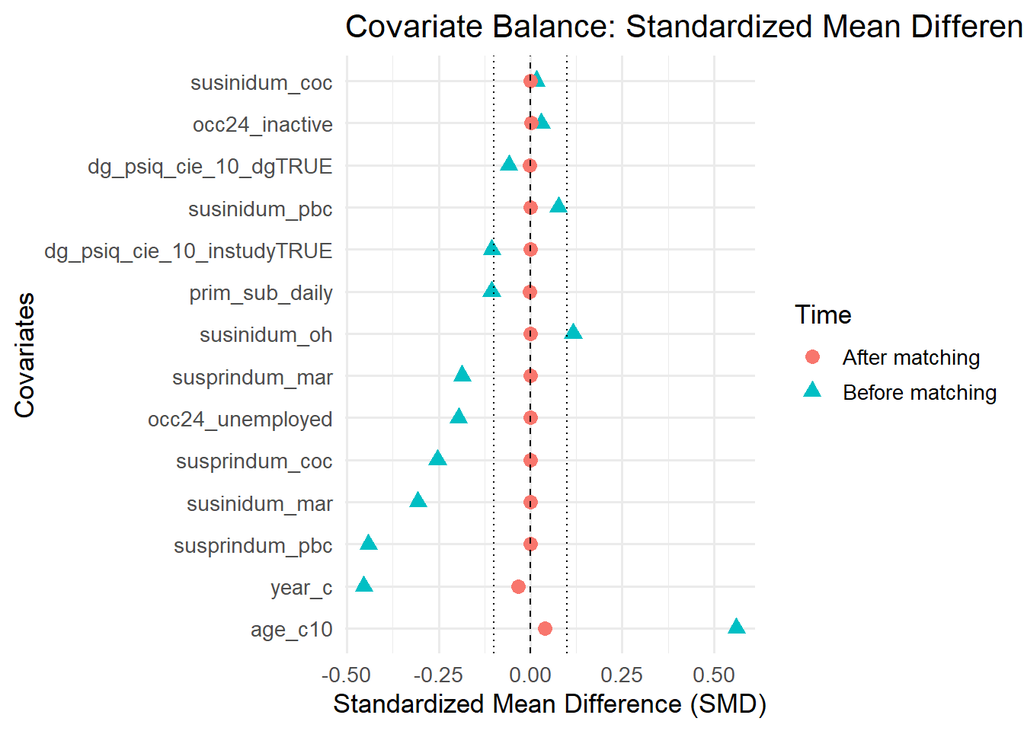

```r
suppressPackageStartupMessages({
  library(dplyr)
  library(tidyr)
  library(ggplot2)
})

love_plot_from_matchit <- function(m, standardize = TRUE) {
    s <- summary(m, standardize = standardize)
    df_before <- as.data.frame(s$sum.all)    |> tibble::rownames_to_column("covariate") |> mutate(Time = "Before matching")
    df_after  <- as.data.frame(s$sum.matched)|> tibble::rownames_to_column("covariate") |> mutate(Time = "After matching")

    # Keep only the SMD column and make tidy
    keep_cols <- c("covariate", "Std. Mean Diff.", "Time")
    df <- bind_rows(df_before[keep_cols], df_after[keep_cols]) |>
        rename(smd = `Std. Mean Diff.`) |>
        filter(!is.na(smd))

    # Order covariates by |SMD| before matching
    order_ref <- df |> filter(Time == "Before matching") |>
        arrange(desc(abs(smd))) |> pull(covariate)
    df$covariate <- factor(df$covariate, levels = order_ref)

    ggplot(df, aes(x = smd, y = covariate, color = Time, shape = Time)) +
        geom_point(size = 3) +
        geom_vline(xintercept = 0, linetype = "dashed") +
        geom_vline(xintercept = c(-0.1, 0.1), linetype = "dotted") +
        labs(
            title = "Covariate Balance: Standardized Mean Differences",
            x = "Standardized Mean Difference (SMD)",
            y = "Covariates"
        ) +
        theme_minimal(base_size = 13)
}

# Covariates
covariates <- c(
  "age_c10", "year_c", "susinidum_oh", "susinidum_coc", "susinidum_pbc",
  "susinidum_mar", "dg_psiq_instudy", "dg_psiq_dg", "prim_sub_daily",
  "occ24_inactive", "occ24_unemployed", "susprindum_coc",
  "susprindum_pbc", "susprindum_mar"
)

balance_table <- {
    s <- summary(m_mah, standardize = TRUE)
    df_before <- as.data.frame(s$sum.all)     |> tibble::rownames_to_column("covariate") |> mutate(Time = "Before matching")
    df_after  <- as.data.frame(s$sum.matched) |> tibble::rownames_to_column("covariate") |> mutate(Time = "After matching")
    bind_rows(df_before, df_after)
}
# Start from your existing balance_table
bt <- balance_table %>%
  # keep only needed cols, rename SMD
  rename(smd = `Std. Mean Diff.`) %>%
  filter(!is.na(smd))

# Order covariates by |SMD| BEFORE matching
order_ref <- bt %>%
  filter(Time == "Before matching") %>%
  arrange(desc(abs(smd))) %>%
  pull(covariate)

bt <- bt %>% mutate(covariate = factor(covariate, levels = order_ref))

ggplot(bt, aes(x = smd, y = covariate, color = Time, shape = Time)) +
  geom_point(size = 3) +
  geom_vline(xintercept = 0, linetype = "dashed") +
  geom_vline(xintercept = c(-0.1, 0.1), linetype = "dotted") +
  labs(
    title = "Covariate Balance: Standardized Mean Differences",
    x = "Standardized Mean Difference (SMD)",
    y = "Covariates"
  ) +
  theme_minimal(base_size = 13)
```